↑ Inhalt

# Einführung in das Programmieren für Technische Mathematik

# Python 3

- Python wurde von Guido van Rossum am Centrum Wiskunde & Informatica (CWI) in den Niederlanden entwickelt (erste Version 1991)
- Der Name bezieht sich auf die englische Komikergruppe Monty Python

**Warum genau Python**:

- Es ist eigentlich egal, welche Programmiersprache man lernt, wichtig sind die grundlegenden Konzepte, die überall sehr ähnlich sind!
- Python ist sehr flexibel, wird aktiv weiterentwickelt und erlaubt einen einfachen Einstieg.
- Python ist eine high-level Sprache, die oft verwendet wird, um low-level Code (in C, C++, ...) auszuführen und einfacher zu bedienen.

**Vorteile von Python**:

- Einfacher Einstieg, leicht zu lernen und zu lesen
- Bibliotheken (Erweiterungen) für beinahe alle denkbaren Anwendungen (große Community)
- Kostenlos und Quelloffen
- Python ist portabel und nicht vom jeweiligen Betriebssystem abhängig

**Nachteile von Python**:

- Python ist langsam im Vergleich zu anderen Sprachen wie C, C++,... und daher für Anwendungen, die rechenintensiv sind, nicht direkt geeignet (Dieser Nachteil wird oft durch Verwendung von Bibliotheken relativiert)

### Python erleichtert das Programmieren und opfert dafür ein wenig Performance

- Motivation von Python: "Computers are cheap, programmers are expensive"

## Programmieren für MathematikerInnen

- Das ist kein Programmierkurs der Informatik!
- Wenig Softwaredesign
- Wenig Debugging
- Wenige Algorithmen

### Literatur & Ressourcen

- "Automate the Boring Stuff with Python" von Al Sweigart (kostenlos online verfügbar unter https://automatetheboringstuff.com/)
- "Python 3" von Johannes Ernesti und Peter Kaiser (sehr umfassend)
- "Python Dokumentation" (https://docs.python.org/3/)
- "Programmier Forum" (https://stackoverflow.com/)
- "Python Tutor" (https://pythontutor.com/) - Visualisierung von Python Code

### Programm

- Wikipedia: Ein Computerprogramm, oder kurz Programm, ist eine Folge von Anweisungen, die den Regeln einer Programmiersprache genügen, um auf einem Computer eine bestimmte Funktionalität, Aufgaben- oder Problemstellung bearbeiten oder lösen zu können.
- Anweisungen sind Definitionen und Instruktionen
  - Definition: z.B. $x = 3$ oder $f: x\mapsto x^2$
  - Instruktion: "tue etwas", z.B. berechne $f(x)$, suche ein Wort in einem Text, berechne den Wert eines Integrals
- Python wird als eine **interpretierte Programmiersprache** betrachtet. Das bedeutet (vereinfacht gesagt), dass die Programmanweisung zum Zeitpunkt der Ausführung in elementaren Computercode übersetzt wird. Diese Aufgabe übernimmt der sogenannte **Interpreter**. Im Gegensatz dazu werden kompilierte Programmiersprachen (wie C, C++, Java) vor der Ausführung im Ganzen übersetzt.

## Wie verwendet man Python?

### Installation von Python3

Python ist ein Programm, das auf Ihrem Computer installiert werden muss.

**Windows:**

1. Laden Sie den Installer von https://www.python.org/downloads/ herunter
   - Verwenden Sie den "Download Python 3.x.x" Button
   - Alternativ können Sie auch den Microsoft Store verwenden
2. Starten Sie den Installer und wählen Sie "Add Python 3.x to PATH" und "Install Now"
3. Überprüfen Sie die Installation, indem Sie in der Kommandozeile (`Windows-Taste` + `CMD` eingeben + `Enter`) `python --version` eingeben

**MacOS:**

1. Laden Sie den Installer von https://www.python.org/downloads/ herunter
   - Verwenden Sie den "Download Python 3.x.x" Button
   - Alternativ können Sie auch Homebrew verwenden (https://brew.sh/)
2. Starten Sie den Installer und folgen Sie den Anweisungen
3. Überprüfen Sie die Installation, indem Sie in im Terminal `python3 --version` eingeben

**Linux:**

1. Python ist auf den meisten Linux Distributionen bereits vorinstalliert
2. Überprüfen Sie die Installation, indem Sie in im Terminal `python3 --version` eingeben
3. Falls Python nicht installiert ist, können Sie es über den Paketmanager Ihrer Distribution installieren
   - Ubuntu/Debian: `sudo apt-get install python3`

### Installation einer Entwicklungsumgebung (IDE = Integrated Development Environment)

Um Python Programme zu schreiben braucht man nur einen Texteditor.

- Entwicklungsumgebungen sind spezielle Texteditoren, die viele nützliche Funktionen bieten, die das Programmieren erleichtern.
  - Syntaxhervorhebung: z.B. Schlüsselwörter werden farbig dargestellt
  - Autovervollständigung: Vorschläge für Codevervollständigung
  - KI-Unterstützung: z.B. Github Co-Pilot (mehr dazu später)

Es gibt viele verschiedene Entwicklungsumgebungen. Wir werden in dieser Vorlesung Visual Studio Code (VSCode) verwenden.

- VSCode ist kostenlos und Open Source
- VSCode ist sehr flexibel und kann durch Erweiterungen an die eigenen Bedürfnisse angepasst werden
- VSCode ist plattformübergreifend (Windows, MacOS, Linux)

## VSCode

### Installation von VSCode

1. Laden Sie den Installer von https://code.visualstudio.com/download für Ihr Betriebssystem herunter
2. Starten Sie den Installer und folgen Sie den Anweisungen
3. Starten Sie VSCode und installieren Sie die Python Erweiterung
   - Klicken Sie auf das Erweiterungssymbol

[figure not shown]

     links in der Seitenleiste
   - Suchen Sie nach "Python" und installieren Sie die Erweiterung von Microsoft

[figure not shown]

### Bedienung von VSCode

- VSCode arbeitet in Ordnern (Folders)
  - Öffnen Sie einen Ordner in VSCode über `File -> Open Folder...`
    - Zum Beispiel macht es Sinn, für jede Übung einen eigenen Ordner zu erstellen, etwa `EPROG_2025/Uebung_1`
  - Es ist gute Programmierpraxis, für jedes Projekt eine virtuelle Umgebung zu erstellen (Virtual Environments). Alle Änderungen und Pakete, die Sie installieren, werden nur in dieser Umgebung vorgenommen und beeinflussen nicht andere Projekte.
    - Eine einfach Möglichkeit ist `venv`, das mit Python mitgeliefert wird
    - Drücken Sie `Strg+Shift+P` und suchen Sie nach "Python: Create Environment"

[figure not shown]

    - Wählen Sie "venv" und und wählen Sie eine Python Version (z.B. Python 3.x.x)

[figure not shown]

    - Im Ordner wird ein neuer Unterordner `.venv` erstellt, der die virtuelle Umgebung enthält (dieser Ordner ist versteckt und kann ignoriert werden)
    - Aktivieren Sie die Umgebung, indem Sie in der Kommandozeile `source .venv/bin/activate` (Linux/MacOS) oder `.venv\Scripts\activate` (Windows) eingeben
      - Normalerweise sollte VSCode die Umgebung automatisch erkennen und aktivieren, wenn Sie eine Python Datei öffnen
  - Erstellen Sie eine neue Datei über `File -> New File` mit der Endung `.py`, z.B. `hello.py`
    - Den Dateinamen können Sie frei wählen, die Endung `.py` ist wichtig, damit VSCode erkennt, dass es sich um eine Python Datei handelt
    - Scheiben Sie ein einfaches Programm in die Datei, z.B.

    ```
    print("Hello, World!")
    ```

    - Speichern Sie die Datei über `File -> Save` oder `Strg+S`
  - Um das Programm auszuführen, können Sie entweder:
    - Das Play Symbol

[figure not shown]

      oben rechts in der Datei klicken
    - Oder die Datei im Terminal ausführen, indem Sie `python3 <dateiname>.py` eingeben (z.B. `python hello.py`)
    - Oder in die Datei rechtsklicken und "Run Python File in Terminal" wählen
  - In allen Fällen wird das Programm im Terminal unten in VSCode ausgeführt und die Ausgabe angezeigt
  - Sie können in einem Ordner beliebig viele Python Dateien erstellen und ausführen

## Grundlegende Befehle

### Textausgabe mit `print`

Der `print` Befehl erlaubt es, Text am Bildschirm auszugeben. Der Text steht dabei immer in Anführungszeichen. Es können mehrere Texte gleichzeitig ausgegeben werden, welche mit dem Symbol getrennt werden können, das dem optionalen Argument `sep` übergeben wird.

```python
print("Hello World!")
print("Das", "ist", "1", "Test")
print("Das", "ist", "1", "Test", sep="-")
```

```
Hello World!
Das ist 1 Test
Das-ist-1-Test
```

Das `end` Schlüsselwort spezifiziert, wie die Zeile beendet wird. Standardmäßig kommt ein Zeilenumbruch mit "\n".

```python
print("Hello World", end="\n")
print("Das", "ist", "1", "Test")

print("Hello World", end="")
print("Das", "ist", "1", "Test")
```

[output not shown]

### Arithmetische Operationen

Python beherrscht die üblichen Rechenregeln and versteht Klammersetzung

```python
4+3
```

```
7
```

```python
5*6+3
```

```
33
```

```python
(6-4)/10
```

```
0.2
```

Das ist verträglich mit `print`

```python
print("2/3 =", 2/3)
```

```
2/3 = 0.6666666666666666
```

**Besonderheiten**:

- Dezimalpunkt (statt Komma, wie im Deutschen oft üblich)
- Potenzierung mit `**` und ganzzahlige Division mit `//`
- Divisionsrest mit `%` (Modulo Operation)
- Absolutbetrag mit `abs()`

```python
print("Pi is approximately", 3.14)
```

```
Pi is approximately 3.14
```

```python
3**2
```

```
9
```

```python
4**0.5
```

```
2.0
```

```python
13//2
```

```
6
```

```python
13%2
```

```
1
```

```python
abs(-5)
```

```
5
```

## Variablen in Python

Variablen in Python haben im Unterschied zur Mathematik (oder manchen anderen Programmiersprachen) immer einen fixen Wert. Zum Beispiel statt $x\in \mathbb{R}$ muss man konkret $x=3.14$ angeben. Dieser Wert kann allerdings beliebig oft geändert werden

```python
x = 3.14
print("Pi is approximately", x)
x = 3
print("Pi is roughly", x)
y = 2*x + 5
print("y =", y)
```

```
Pi is approximately 3.14
Pi is roughly 3
y = 11
```

Variablennamen dürfen (fast) beliebig gewählt werden

- es dürfen Buchstaben, Zahlen und Unterstriche vorkommen (aber z.B. keine Leerzeichen)
- das erste Zeichen darf keine Zahl sein (z.B. `2pac` ist verboten)
- Die folgenden Schlüsselwörter sind für Python Befehle reserviert und dürfen daher nicht verwendet werden

  ```
    False, def, if, raise, None, del, import, return, True, elif, in, try, and, else, is, while, as, except, lambda,
    with, assert, finally, nonlocal, yield, break, for, not, class, from, or, continue, global, pass
  ```

- Konvention: Man verwendet den sogenannten 'snake case', indem man alles klein schreibt und Leerzeichen durch Unterstriche `_` ersetzt
  - z.B. `first_name` oder `integral_value`
  - Wichtig: Variablennamen sollten erklären, wofür die Variable verwendet wird (hilft später bei der Fehlersuche und beim Verstehen von Code)

Variablen können mit dem Befehl `input` auch von der Tastatur eingelesen werden. Achtung: es wird nicht überprüft, ob tatsächlich das Gewünschte eingegeben wird!

```python
age = input("Enter your age: ")
first_name = input("Enter your first name: ")
last_name = input("Enter your last name: ")
print(first_name, last_name, "is", age, "years old.")
```

```
Michael Feischl is 10 years old.
```

### Formatierte Ausgabe mit `format`

Hier ist es oft schöner, die Ausgabe zu formatieren: Mit `{:x.yf}` kann man im Text Platzhalter einfügen, die dann mit `format` befüllt werden. Hier gibt `x` die minimale Gesamtanzahl der Stellen (inklusive Dezimalpunkt) und `y` die Anzahl der Nachkommastellen an. Beides oder `y` kann man weglassen.

```python
x = 2/3
print("2/3 = {:4.2f}".format(x))
print("2/3 = {:5.3f}".format(x))
print("2/3 = {:6.3f}".format(x))
print("2/3 = {:.3f}".format(x))
print("2/3 = {:f}".format(x))
```

```
2/3 = 0.67
2/3 = 0.667
2/3 =  0.667
2/3 = 0.667
2/3 = 0.666667
```

Das funkioniert auch mit mehreren Platzhaltern

```python
print("2/3 is approximately {:.2f}, or more precisely {:.5f}".format(2/3,2/3))
```

```
2/3 is approximately 0.67, or more precisely 0.66667
```

**Kurzschreibweise**: Statt `.format(...)` kann man auch `f-Strings` verwenden: `f"..."` und Platzhalter in geschweifte Klammern setzen.

```python
x = 2/3
y = 3.14159
print(f"{x:4.2f} ist kleiner als {y}")
```

```
0.67 ist kleiner als 3.14159
```

**Sonderzeichen**: Will man ein Anführungszeichen oder einen Backslash am Bildschirm ausgeben, muss man diesen mit einem Backslash maskieren. Beispiel: `\"` für ein Anführungszeichen und `\\` für einen Backslash.

- **Achtung**: Will man in `f`-Strings geschungene Klammern in `{` oder `}` ausgeben, muss man doppelte Klammern verwenden: `{{` oder `}}`.
  - In normalen Strings (ohne `f`) ist das nicht notwendig.
- Anstelle der Anführungszeichen, kann man auch einfache Anführungszeichen verwenden, z.B. `print('Hello "World"')`.

```python
pi = 3.14159
print(f"{pi:.2f} wird auch als \"Kreiszahl\" bezeichnet.")
print(f'{pi:.2f} wird auch als "Kreiszahl" bezeichnet.')
print("Ich fühle mich \\o/")
print(f"Die Menge der geraden Zahlen ist {{2,4,6,8,...}} und pi ist ungefähr {pi:.2f}.")
```

```
3.14 wird auch als "Kreiszahl" bezeichnet.
3.14 wird auch als "Kreiszahl" bezeichnet.
Ich fühle mich \o/
Die Menge der geraden Zahlen ist {2,4,6,8,...} und pi ist ungefähr 3.14.
```

### Bemerkung: Kommentare in Python

Kommentare in Python beginnen mit `#` und gehen bis zum Ende der Zeile. Kommentare werden vom Interpreter ignoriert und dienen dazu, den Code zu dokumentieren und verständlicher zu machen (siehe auch weiter unten im Kapitel "Kommentare im Code").

```python
x=4 # Kommentar: Weist der Variable x den Wert 4 zu
```

## Einfache Datentypen in Python

Da im Computer alles in Bits gespeichert wird (0 oder 1), muss man festlegen, wie verschiedene Folgen von Bits interpretiert werden sollen. Diese Festlegung nennt man **Datentyp**. Einige der wichtigsten einfachen Datentypen in Python sind:

- `int`: Ganze Zahlen (beliebig groß, nur durch den Speicher begrenzt)
- `float`: Gleitkommazahlen (ca. 15-17 signifikante Stellen)
- `complex`: Komplexe Zahlen (z.B. `3 + 4j`). Hier ersetzt `j` die imaginäre Einheit $i$, die in der Mathematik üblich ist
- `str`: Zeichenketten (Strings), z.B. `"Hallo Welt!"`

In Python bestimmt man den Datentyp einer Variable einfach durch die Definition. Im Beispiel unten ist:

- `x` vom Typ `float` (für Dezimalzahlen),
- `y` vom Typ `int` (für ganze Zahlen 'Integer'),
- `c` vom Typ `complex` (für komplexe Zahlen, `j` ersetzt die imaginäre Einheit $i$)
- und `name` vom Datentyp `str` (für Text 'String' = Zeichenkette).

Das kann man mit dem Befehl `type` überprüfen.

```python
x = 3.14
y = 10
c = 3 + 4j
name = "Peter"
print(type(x),type(y),type(c),type(name))
```

```
<class 'float'> <class 'int'> <class 'complex'> <class 'str'>
```

### Datentypen `int` und `float`

Im Kapitel 'Zahldarstellung am Computer' werden wir dazu noch mehr lernen. Jetzt reicht es zu wissen, dass Rechnungen mit `float` immer (kleine) Rundungsfehler haben können, wohingegen Rechnungen mit `int` exakt sind.

- Bei `float` kann man die `0` vor oder nach dem Dezimalpunkt weglassen (z.B. `.5` statt `0.5` oder `2.` statt `2.0`)
- **Bei Rechnungen mit verschiedenen Zahldatentypen wird das Ergebnis immer im mächtigeren Datentyp berechnet!**

```python
x = 2
y = 3.14
print(x*y, type(x),type(y),type(x*y))
x = 2/3
y = 3
print(x*y, type(x),type(y),type(x*y))
x = 1j
print(x**2, type(x),type(x**2))
```

```
6.28 <class 'int'> <class 'float'> <class 'float'>
2.0 <class 'float'> <class 'int'> <class 'float'>
(-1+0j) <class 'complex'> <class 'complex'>
```

**Große und kleine Zahlen**: Große und kleine Zahlen können mit `e` für den Exponenten dargestellt werden, z.B. `1.5e3` für $1.5 \cdot 10^3 = 1500$ und `2.5e-4` für $2.5 \cdot 10^{-4} = 0.00025$.

```python
x  = 1e3
print(x)
y = 5e-4
print(y)
```

```
1000.0
0.0005
```

Python wählt für die Ausgabe von `float` automatisch eine geeignete Darstellung (normal oder wissenschaftlich) und rundet dabei gegebenenfalls. Mit `f`-Strings oder `format` kann die Darstellung jedoch angepasst werden.

```python
print(f"x = {x:.2e}")
print(f"y = {y:.4f}")
```

```
x = 1.00e+03
y = 0.0005
```

### Datentyp `complex`

Für `complex` gibt es noch die Befehle

- `conjugate()`: rechnet die konjugierte Zahl aus, also $a+ib$ wird zu $a-ib$
- `imag`, `real`: liefern den imaginären und realen Teil der Zahl (als `float` Zahl)
- `abs()`: liefert den Betrag der komplexen Zahl (Länge des Vektors im komplexen Zahlenraum)

```python
x = 4 + 3j
print(x,x.conjugate(),x.imag, x.real, abs(x))
```

```
(4+3j) (4-3j) 3.0 4.0 5.0
```

### Datentyp `str`

Strings kann man addieren und es gibt die Befehle

- `lower()`: alles in Kleinbuchstaben
- `upper()`: alles in Großbuchstaben
- `swapcase()`: wechselt zwischen Klein- und Großbuchstaben
- `split()`: zerlegt einen Text in durch Leerzeichen getrennte Teile (durch ein optionales Argument kann angegeben werden, an welcher Teilzeichenfolge die Trennung erfolgen soll)
- `replace()`: ersetzt Teile eines Strings durch einen anderen String
- `strip()`: entfernt Leerzeichen am Anfang und Ende des Strings sowie Zeilenumbrüche

```python
first_name = "Peter"
last_name = "Parker"
print(first_name + " " + last_name)
print(3*first_name)

print(first_name.lower())
print(first_name.upper())
print(first_name.swapcase())
print("This is a test".split())
print("This is a test".split(" a "))
print("This is a test".replace("is","was"))
print("This is a test".replace(" is ", " was "))
```

```
Peter Parker
PeterPeterPeter
peter
PETER
pETER
['This', 'is', 'a', 'test']
['This is', 'test']
Thwas was a test
This was a test
```

### Umwandeln von Datentypen

Man kann Datentypen ineinander umwandeln. Dabei geht manchmal Information verloren, z.B.

```python
x = 3.14
y = int(x)
print(x,y,type(x),type(y))
z = float(y)
print(z,type(z))

number = "3.14"
x = float(number)
print(number, type(number), x, type(x))
```

```
3.14 3 <class 'float'> <class 'int'>
3.0 <class 'float'>
3.14 <class 'str'> 3.14 <class 'float'>
```

Achtung, der von `input()` eingelesene Wert ist immer ein String `str` und muss bei Zahlen daher erst umgewandelt werden.

```python
x = input("Enter a number: ")
print(x, type(x))
y = float(x)
print("x^2 =", y**2)
```

```
4 <class 'str'>
x^2 = 16.0
```

### Überprüfen von Datentypen mit `isinstance`

- Mit `isinstance(var, type)` kann überprüft werden, ob `var` vom Typ `type` ist

```python
print(isinstance(3.14, float))
print(isinstance(3, int))
print(isinstance("Hello", str))
print(isinstance(3+4j, complex))
print(isinstance(3.14, int))
```

```
True
True
True
True
False
```

**Achtung**: in Python ist `3.0` nicht dasselbe wie `3`

- `3.0` ist ein `float`
- `3` ist ein `int`

```python
print(isinstance(3.0, int))
print(isinstance(3, int))
```

```
False
True
```

### Datentyp `None`

- `None` ist ein spezieller Datentyp, der verwendet wird, um das Fehlen eines Wertes zu kennzeichnen
- `None` ist nützlich, um anzuzeigen, dass eine Variable noch nicht initialisiert wurde oder dass eine Funktion keinen Wert zurückgibt
- `None` ist nicht dasselbe wie `0`, `False` oder ein leerer String `""`

```python
x = None
print(x)
```

```
None
```

## Zuweisungsoperator `=`

Achtung das Zeichen `=` ist eine Zuweisung und kein Vergleich

- Zuweisung immer von rechts nach links
- `x = 1` gibt der Variable `x` den Wert 1
- `x = y` gibt der Variable `x` den Wert von `y`. Insbesondere haben danach `x` und `y` den selben Wert (Vertauschen von Werten funktioniert mit Hilfsvariable)

```python
x = 1
y = 2
print(x, y)
tmp = x
x = y
y = tmp
print(x, y)
x = y
print(x, y)
```

```
1 2
2 1
1 1
```

**Selbstzuweisung mit Arithmetik**: Der Zuweisungsoperator kann mit den arithmetischen Operationen `+`, `-`, `*`, `**`, `/`, `//` kombiniert werden um Platz zu sparen

```python
x = 1
y = x + 2
x += 2
print(x, y)
x *= 3
print(x)
x **= 2
print(x)
name = "Peter"
name += " Parker"
print(name)
```

```
3 3
9
81
Peter Parker
```

**Mehrfachzuweisung**: Der Zuweisungsoperator kann mehrere Variablen gleichzeitig zuweisen. Dies kann man verwenden, um zwei Variablen ohne Hilfsvariable zu vertauschen.

```python
x, y = 1, 2
print("x=", x, ", y=", y)
x, y = y, x
print("x=", x, ", y=", y)
```

```
x= 1 , y= 2
x= 2 , y= 1
```

## Zeilenumbruch in Python Code

Wenn eine Codezeile zu lang wird, kann man in Python meistens einfach in der nächsten Zeile weiterschreiben.

- Python erkennt automatisch, dass die Anweisung noch nicht abgeschlossen ist.
- Man kann auch Klammern verwenden, falls ansonsten nicht klar ist, dass die Anweisung noch nicht abgeschlossen ist.
- Eine alte und nicht mehr so häufig verwendete Möglichkeit ist der Backslash `\` am Ende der Zeile, der anzeigt, dass die Anweisung in der nächsten Zeile fortgesetzt wird. Ein Fehler wird angezeigt, wenn der Zusammenhang von zwei Zeilen nicht eindeutig gekennzeichnet wurde.

```python
result = (1 + 2 + 3 +
            4 + 5 + 6)
result = 1 + 2 + 3 + \
            4 + 5 + 6
result = 1 + 2 + 3 +
            4 + 5 + 6
```

```
  Cell In[33], line 5
    result = 1 + 2 + 3 +
                        ^
SyntaxError: invalid syntax
```

## Fehler

Es gibt verschiedene Arten von Fehlern:

### Syntaxfehler

- **Syntax** bezeichnet den Wortschatz und die Grammatik einer Programmiersprache.
- Ein **Syntaxfehler** tritt auf, wenn die Syntaxregeln verletzt werden.
- Beispiele:
  - Falsche Einrückung
  - Fehlende Klammern
  - Falsche Verwendung von Schlüsselwörtern
- Der Interpreter meldet Syntaxfehler sofort beim Einlesen des Programms.

```python
print("Hello World"
```

```
  Cell In[148], line 1
    print("Hello World"
                       ^
SyntaxError: incomplete input
```

```python
iput("Enter your age: ")
```

```
---------------------------------------------------------------------------
NameError                                 Traceback (most recent call last)
Cell In[149], line 1
----> 1 iput("Enter your age: ")

NameError: name 'iput' is not defined
```

### Laufzeitfehler

- Ein **Laufzeitfehler** tritt während der Programmausführung auf.
- Oft gibt es keine Fehlermeldung.
- Das Programm strürzt einfach ab oder verhält sich unerwartet.
- Beispiele:
  - Division durch Null
  - Zugriff auf nicht existierende Dateien
  - Zugriff auf nicht definierte Variablen
  - Falscher Datentyp (z.B. String statt Zahl)
- Laufzeitfehler sind oft schwer zu finden und lassen sich nur durch **sorgfältiges Testen** vermeiden und beheben.

```python
a = 10
b = 0
result = a / b
```

```
---------------------------------------------------------------------------
ZeroDivisionError                         Traceback (most recent call last)
Cell In[150], line 3
      1 a = 10
      2 b = 0
----> 3 result = a / b

ZeroDivisionError: division by zero
```

## Module in Python

- Python hat eine große Anzahl an eingebauten Modulen, die viele nützliche Funktionen bereitstellen.
- Module sind Sammlungen von Funktionen und Variablen, die in einer Datei gespeichert sind.
- Module können mit dem Befehl `import` eingebunden werden.
- Um eine Funktion aus dem Modul zu verwenden muss der Modulname vorangestellt werden, z.B. `math.sqrt(4)` um die Quadratwurzel zu berechnen.
- Man kann einzelene Funktionen oder Variablen mit `from ... import ...` importieren. Dann kann man sie ohne den Modulnamen verwenden.
- Man neue Namen für Module oder Funktionen mit `as` vergeben.

Einfache Beispiele sind das `math` Modul für mathematische Funktionen und Konstanten, das `random` Modul für Zufallszahlen, oder das `time` Modul für Zeitfunktionen. Wir werden später noch weitere Module kennenlernen.

```python
import math
from math import sqrt, pi
import random as rnd
from time import time

print("Squareroot of 16 =", sqrt(16))
print("Value of pi =", pi)
print("Cosine of pi =", math.cos(pi))
print("Random number between zero and one =", rnd.random())
print("Current time in seconds since 01.01.1970 =", time())
```

```
Squareroot of 16 = 4.0
Value of pi = 3.141592653589793
Cosine of pi = -1.0
Random number between zero and one = 0.4176393876046519
Current time in seconds since 01.01.1970 = 1759394739.209932
```

Beim Einbinden von Modulen wird standardmäßig der gesamte Code des Moduls ausgeführt. Das kann unnötige Resourcen verbrauchen. Um dies zu vermeiden sollten man möglichst nur die benötigten Funktionen importieren.

Weitere wichtige Funktionen des Moduls `random` sind:

- `random.random()`: Zufallszahl im Intervall [0.0, 1.0)
- `random.randint(a, b)`: Zufallszahl im Intervall [a, b] (inklusive a und b)
- `random.uniform(a, b)`: Zufallsinteger im Intervall [a, b) (inklusive a, aber exklusive b)
- `random.choice(seq)`: zufälliges Element aus der Sequenz `seq` (z.B. Liste oder String -> siehe später)

# Einfache Verzweigungen

Bis jetzt konnten wir Befehle nur der Reihe nach ausführen. Um den Ablauf zu steuern gibt es Verzweigungen. Dazu brauchen wir zuerst einen Datentyp für logische Aussagen:

## Boolean

- Benannt nach dem Englischen Mathematiker George Boole (1815 - 1864)
- Kann nur die werte `True` (Wahr) oder `False` (Falsch) annehmen
- versteht die Operationen `and`, `or`, und `not`

| A | B | A and B | A or B |
| --- | --- | --- | --- |
| True | True | True | True |
| True | False | False | True |
| False | True | False | True |
| False | False | False | False |

```python
x = True
print(x,type(x))
print(not x)
y = False
print(x and y)
print(x or y)
```

```
True <class 'bool'>
False
False
True
```

## Vergleichsoperatoren

Der Datentyp `bool` wird hauptsächlich verwendet, um das Ergebnis von Vergleichsoperationen zu speichern. In Python gibt es die grundlegenden Vergleiche

- `==` Überprüfung auf Gleichheit
- `!=` Überprüfung auf Ungleichheit
- `<` echt kleiner
- `>` echt größer
- `<=` kleiner gleich
- `>=` größer gleich

```python
x = 3<4
print(x, type(x))
y = 3>4
print(y, type(y))
print(3 == 3, 3 != 3)
```

```
True <class 'bool'>
False <class 'bool'>
True False
```

### Logische Verkettung

Im Unterschied zu vielen anderen Programmiersprachen erlaubt Python das Verketten von Vergleichsoperatoren:

- `a<b<c` überprüft also beispielsweise ob `a<b` **und** `b<c` gilt
- Man könnte auch `(a<b) and (b<c)` schreiben

```python
print(3>2>1, (3>2) and (2>1))
print(4<5<=5)
print(1<2>3)
a=1
b=1
c=1
print(a==b==c, a==b and b==c)
```

```
True True
True
False
True True
```

## If-Else Verzweigung

Die einfachste Verzweigung führt Befehle nur dann aus, wenn eine Bedingung wahr ist. Die Syntax ist:

```
if Bedingung:
    Anweisungen wenn Bedingung wahr ist
```

Wichtig ist die Einrückung (meist 4 Leerzeichen oder ein Tabulator). Alle Befehle die zu `if` gehören müssen gleich weit eingerückt sein.

- **Wichtig**: Man darf Tabulatoren und Leerzeichen nicht mischen.
- **Achtung**: Doppelpunkt nach Bedingung nicht vergessen!

```python
x = 3
y = 4
if x!=y:
    print(x, "is not equal to", y)
```

```
3 is not equal to 4
```

Mit dem `else` Schlüsselwort kann man auch spezifizieren, was passiert, falls die Bedingung falsch ist, d.h.

```
if Bedingung:
    Anweisungen, wenn Bedingung wahr ist
else:
    Anweisungen, wenn Bedingung falsch ist
```

**Wichtig**: Die `else` Anweisung muss auf der gleichen Einrückungsebene wie das `if` stehen.

```python
x = 3.14
if x>0:
    print(x, "is positive")
else:
    print(x, "is not positive")
```

```
3.14 is positive
```

Das ist besonders nützlich zusammen mit User Input (Achtung: `input` liefert immer `str` und muss zuerst in eine Zahl umgewandelt werden)

```python
input_text = input("Enter an integer: ")
input_int = int(input_text)
if input_int%2 == 0:
    print(input_int, "is even")
else:
    print(input_int, "is odd")
```

```
5 is odd
```

Es gibt noch weitere Verzweigungen, z.B. `elif` (else if), um mehrere Bedingungen zu testen. Die Syntax lautet:

```
if Bedingung1:
    Anweisungen wenn Bedingung1 wahr ist
elif Bedingung2:
    Anweisungen wenn Bedingung2 wahr ist
else:
    Anweisungen wenn keine der Bedingungen wahr ist
```

Es kann beliebig viele `elif`-Teile geben. Wichtig ist, dass die Einrückung für alle Teile gleich ist.

```python
input_text = input("Enter a number: ")
input_float = float(input_text)
if input_float>0:
    print(input_float, "is positive")
elif input_float<0:
    print(input_float, "is negative")
else:
    print(input_float, "is zero")
```

```
0.0 is zero
```

### Beispiele zu If-Else Verzweigungen

**Zwei Zahlen aufsteigend sortieren**:

- Eingabe von zwei Zahlen
- Gegebenenfalls vertauschen
- Ausgabe in sortierter Reihenfolge

```python
x = float(input("Enter a number: "))
y = float(input("Enter another number: "))
if x>y:
    tmp = x
    x = y
    y = tmp
print("In ascending order:", x, y)
```

```
In ascending order: 1.0 3.0
```

**Innen oder Außen?**:

- Einlesen von Kreismittelpunkt $m\in \mathbb{R}^2$
- Einlesen von Kreisradius $r>0$
- Einlesen von Punkt $z\in\mathbb{R}^2$
- Überprüfen ob Abstand $|m-z|^2 > r^2$

```python
m_x = float(input("Enter x coordinate of m "))
m_y = float(input("Enter y coordinate of m "))
r = float(input("Enter radius "))
z_x = float(input("Enter x coordinate of z "))
z_y = float(input("Enter y coordinate of z "))
dist2 = (m_x - z_x)**2 + (m_y - z_y)**2
if dist2 < r**2:
    print("Point is inside the circle")
elif dist2>r**2:
    print("Point is outside the circle")
else:
    print("Point is on the circle")
```

```
Point is inside the circle
```

**Zur Erinnerung**: `=` ist eine Zuweisung, `==` ist ein Vergleich auf Gleichheit. Bei If-Else Bedingungen muss man daher immer `==` verwenden.

## Beispiel: Schere-Stein-Papier

Wir haben bereits alle nötigen Bausteine kennengelernt, um ein kleines Spiel zu programmieren.

Ziel: User spielt gegen den Computer

- User gibt Schere, Stein oder Papier ein
- Computer wählt zufällig Schere, Stein oder Papier
- Gewinner wird bestimmt
- Ergebnis wird ausgegeben

```python
import random
throw_computer = random.randint(1,3) # 1: Schere, 2: Stein, 3: Papier
throw_user = int(input("Schere(1), Stein(2), Papier(3): "))
if throw_computer == throw_user:
    print("Unentschieden")
elif throw_computer == 1 and throw_user == 2:
    print("Stein bricht Schere, du gewinnst!")
elif throw_computer == 1 and throw_user == 3:
    print("Schere schneidet Papier, Computer gewinnt!")
elif throw_computer == 2 and throw_user == 1:
    print("Stein bricht Schere, Computer gewinnt!")
elif throw_computer == 2 and throw_user == 3:
    print("Papier bedeckt Stein, du gewinnst!")
elif throw_computer == 3 and throw_user == 1:
    print("Schere schneidet Papier, du gewinnst!")
elif throw_computer == 3 and throw_user == 2:
    print("Papier bedeckt Stein, Computer gewinnt!")
else:
    print("Ungültige Eingabe")
```

```
Papier bedeckt Stein, Computer gewinnt!
```

Man kann mathematisch zeigen, dass die zufällige Wahl des Computers die beste Strategie ist.

- Menschen sind schlechte Zufallszahlengeneratoren
- Im Durschnitt wird der Computer gewinnen

Da der Computer den Wurf des Users kennt, könnte man den Computer natürlich auch schummeln lassen.

- z.B. kann der Computer immer einen Gewinnerwurf wählen, nachdem der User seinen Wurf eingegeben hat
- um das nicht zu offensichtlich zu machen, könnte der Computer auch nur mit einer gewissen Wahrscheinlichkeit (1/3) schummeln

```python
should_i_cheat = random.random()
throw_user = int(input("Schere(1), Stein(2), Papier(3): "))

if should_i_cheat < 1/3:
    # cheat
    if throw_user == 1:
        throw_computer = 2
    elif throw_user == 2:
        throw_computer = 3
    else:
        throw_computer = 1
else:
    # fair play
    throw_computer = random.randint(1,3)

# Check result
if throw_computer == throw_user:
    print("Unentschieden")
elif throw_computer == 1 and throw_user == 2:
    print("Stein bricht Schere, du gewinnst!")
elif throw_computer == 1 and throw_user == 3:
    print("Schere schneidet Papier, Computer gewinnt!")
elif throw_computer == 2 and throw_user == 1:
    print("Stein bricht Schere, Computer gewinnt!")
elif throw_computer == 2 and throw_user == 3:
    print("Papier bedeckt Stein, du gewinnst!")
elif throw_computer == 3 and throw_user == 1:
    print("Schere schneidet Papier, du gewinnst!")
elif throw_computer == 3 and throw_user == 2:
    print("Papier bedeckt Stein, Computer gewinnt!")
else:
    print("Ungültige Eingabe")
```

```
Papier bedeckt Stein, Computer gewinnt!
```

### Geschachtelte If-Else Verzweigungen

If-Else Verzweigungen können auch ineinander geschachtelt werden. Dabei ist darauf zu achten, dass die Einrückung immer korrekt ist:

- Jede neue Ebene wird weiter eingerückt
- Jede Ebene endet, wenn die Einrückung wieder zurückgesetzt wird Geschachtelte IF-Else Verzweigungen können schnell unübersichtlich werden und sollten, wenn möglich, durch `elif` ersetzt werden.

```python
a = float(input("Enter first number: "))
b = float(input("Enter second number: "))
c = float(input("Enter third number: "))
if a>b:
    if a>c:
        print("The largest number is", a)
    else:
        print("The largest number is", c)
else:
    if b>c:
        print("The largest number is", b)
    else:
        print("The largest number is", c)
```

```
The largest number is 3.0
```

## Inline If-Else

Python erlaubt auch eine kompakte Schreibweise für If-Else Verzweigungen, die sogenannte Inline If-Else Anweisung. Die Syntax lautet:

```
Anweisung_wenn_wahr if Bedingung else Anweisung_wenn_falsch
```

```python
a = float(input("Enter first number: "))
b = float(input("Enter second number: "))
max_va = a if a>b else b
print("The largest number is", max_va)
```

```
The largest number is 5.0
```

Für einfache Bedingungen kann dies die Lesbarkeit verbessern, bei komplexeren Bedingungen ist meist die klassische Schreibweise vorzuziehen.

# Weitere Datentypen

In Python gibt es neben den bisher besprochenen Datentypen (Integer, Float, String, Boolean) noch weitere wichtige Datentypen:

- Listen (Lists)
- Tupel (Tuples)
- Mengen (Sets)
- Wörterbücher (Dictionaries)

Je nach Anwendungsfall spart man sich sehr viel Arbeit, wenn man einen passenden Datentyp verwendet.

## Listen (Lists)

Listen sind geordnete Sammlungen von Elementen, die veränderbar sind. Sie werden mit eckigen Klammern `[]` definiert und die Elemente werden durch Kommas getrennt.

```python
my_list = [1, 2, 3, 4, 5]
print(my_list)
```

```
[1, 2, 3, 4, 5]
```

### Wichtige Operationen mit Listen

Listen können Elemente unterschiedlichen Typs enthalten, z.B. Integer, Float, String, etc. und können verschachtelt sein (Listen in Listen). Die leere Liste wird mit `[]` oder `list()` erstellt.

- Listen können addiert (verkettet) werden mit `+`
- Listen können mit `*` vervielfacht werden
- Elemente können mit `in` auf Zugehörigkeit geprüft werden
- Listen können mit `len()` auf ihre Länge geprüft werden
- mit dem Indexoperator `[]` können Elemente gelesen und geschrieben werden (Achtung: Indizes beginnen bei 0 und enden bei `len(...)-1`)
- mittels `append()` können Elemente an das Ende der Liste angehängt werden
- mittels `remove()` können Elemente aus der Liste entfernt werden (erstes Vorkommen)
- mittels `sort()` können Listen sortiert werden (nur wenn alle Elemente vergleichbar sind)

```python
my_list = [5, 3, 1, 4, 2]
my_list[0] = 10
print(my_list, len(my_list))
my_list.append(6)
print(my_list, len(my_list))
my_list.remove(3)
print(my_list, len(my_list))
my_list.sort()
print(my_list)
```

```
[10, 3, 1, 4, 2] 5
[10, 3, 1, 4, 2, 6] 6
[10, 1, 4, 2, 6] 5
[1, 2, 4, 6, 10]
```

```python
a = [1, 2, 3]
b = [4, 5, 6]
print(a + b)
print(a * 3)
print(3 in a)
```

```
[1, 2, 3, 4, 5, 6]
[1, 2, 3, 1, 2, 3, 1, 2, 3]
True
```

### Entpacken von Listen

Listen können auch "entpackt" werden, d.h. die Elemente der Liste werden einzelnen Variablen zugewiesen.

- Die Anzahl der Variablen muss mit der Anzahl der Elemente in der Liste übereinstimmen.
- Das "Wildcard"-Zeichen `_` kann verwendet werden, um Elemente zu ignorieren.

```python
my_list = [1,2,3]
a, b, c = my_list
print(a, b, c)
a, _, c = my_list
print(a, c)
```

```
1 2 3
1 3
```

### Slicing

Mit dem Indexoperator `[]` können auch Bereiche (Slices) von Listen extrahiert werden. Die Syntax dafür ist `list[start:stop:step]`, wobei `start` der Anfangsindex (inklusive), `stop` der Endindex (exklusive) und `step` die Schrittweite ist. Alle drei Parameter sind optional. Das letzte Element kann mit `-1` angesprochen werden.

```python
my_list = [1,2,3,4,5]
print(my_list[0:5:2])
print(my_list[-1])
print(my_list[:3])
print(my_list[::2])
print(my_list[::-1])
```

```
[1, 3, 5]
5
[1, 2, 3]
[1, 3, 5]
[5, 4, 3, 2, 1]
```

Listen haben noch viele weitere nützliche Funktionen

- `insert()`: Fügt ein Element an einer bestimmten Position ein.
- `pop(i)`: Entfernt und gibt das `i`-te Element der Liste zurück (oder das letzte falls der Parameter `i` weggelassen wird).
- `reverse()`: Kehrt die Reihenfolge der Elemente in der Liste um, equivalent zu `list[::-1]`.
- `index()`: Gibt den Index des ersten Vorkommens eines Elements zurück.
- `count()`: Zählt, wie oft ein Element in der Liste vorkommt.
- `clear()`: Entfernt alle Elemente aus der Liste.
- `copy()`: Erstellt eine Kopie der Liste.
- `extend()`: Fügt die Elemente einer anderen Liste an das Ende der Liste an.

Zusätzlich gibt es die eingebaute Funktionen:

- `min()`: Gibt das kleinste Element in der Liste zurück.
- `max()`: Gibt das größte Element in der Liste zurück.
- `sum()`: Gibt die Summe der Elemente in der Liste zurück (nur für numerische Listen geeignet).

```python
my_list = [1, 2, 3]
print("Minimalwert:", min(my_list))
print("Maximalwert:", max(my_list))
print("Summe:", sum(my_list))
```

```
Minimalwert: 1
Maximalwert: 3
Summe: 6
```

## Der `del` Operator

Der `del` Operator wird verwendet um Python Objekte zu löschen.

- `del variable` löscht die Variable und gibt den Speicherplatz frei.
- `del list[index]` löscht das Element an der angegebenen Position in der Liste
- `del list[start:stop]` löscht einen Bereich von Elementen in der Liste

```python
my_list = ["Hello", "my", "name", "is", "Python"]
del my_list[1:4]
print(my_list)
```

```
['Hello', 'Python']
```

## Der `*` Operator

Der `*` Operator hat in Python mehrere Bedeutungen, abhängig vom Kontext:

- In mathematischen Ausdrücken wird `*` als Multiplikationsoperator verwendet, z.B. `3 * 4` ergibt `12`.
- In Listen und Tupeln wird `*` verwendet, um eine Liste oder ein Tupel (siehe unten) zu "entpacken" und in einzelne Elemente zu zerlegen
  - bei der Zuweisung `a, b, c = [1, 2, 3]` wird das automatisch gemacht, weiteres Entpacken mit `*` funktioniert nicht
  - bei Funktionsaufrufen (später) kann eine Liste oder ein Tupel mit `*` entpackt werden

```python
my_list = [1,2,3]
print(my_list)
print(*my_list)  # Entpacken der Liste in einzelne Argumente
```

```
[1, 2, 3]
1 2 3
```

```python
my_list = [1,2,3]
a, b, c = my_list
print(a, b, c)
```

```
1 2 3
```

### Geschachtelte Listen

Listen können auch andere Listen als Elemente enthalten, was zu geschachtelten Listen führt. Diese können beliebig tief verschachtelt sein. Für die Mathematik sind solche Strukturen z.B. nützlich, um Matrizen zu repräsentieren. Eine Matrix $$ M = \begin{pmatrix} 1 & 2 & 3 \\ 4 & 5 & 6 \\ 7 & 8 & 9 \end{pmatrix} \in \mathbb{R}^{3 \times 3} $$ kann in Python als Liste von Listen dargestellt werden:

```
M = [[1, 2, 3],
     [4, 5, 6],
     [7, 8, 9]]
```

Um auf Elemente in geschachtelten Listen zuzugreifen, verwendet man mehrere Indizes. Der erste Index gibt die äußere Liste an, der zweite Index die innere Liste. Zum Beispiel:

```
M[0][1]
```

```python
M = [[1,2,3],
     [4,5,6],
     [7,8,9]]
print(M)
print(M[0])
print(M[0][1])
```

```
[[1, 2, 3], [4, 5, 6], [7, 8, 9]]
[1, 2, 3]
2
```

### Listen und Strings

Strings können ähnlich wie Listen behandelt werden, da sie eine Sequenz von Zeichen sind. Viele der Operationen, die auf Listen angewendet werden können, funktionieren auch auf Strings, z.B. Indexierung, Slicing und die Verwendung von `len()`. Allerdings sind Strings unveränderlich (immutable), d.h. einmal erstellt, können sie nicht mehr verändert werden. Bei der Bearbeitung von Strings wird immer ein neuer String erzeugt.

Es gibt außerdem noch die nützliche Methode `join()`, die eine Liste von Strings zu einem einzigen String verbindet, wobei ein bestimmter Trenner verwendet wird. Zum Beispiel:

```
words = ["Word1", "Word2", "Word3"]
sentence = "-".join(words)
```

erzeugt den String `"Word1-Word2-Word3"`, wobei `"-"` der Trenner ist und durch jede beliebige Zeichenkette ersetzt werden kann.

Die Methode `split()` teilt einen String in eine Liste von Substrings auf, basierend auf einem angegebenen Trenner. Standardmäßig wird an Leerzeichen geteilt. Zum Beispiel:

```
text = "Hello, World!"
words = text.split(", ")
```

erzeugt die Liste `["Hello", "World!"]`, wobei `", "` der Trenner ist und durch jede beliebige Zeichenkette ersetzt werden kann.

```python
text = "Hello, World!"
print(text[:5])
print(text[7:])
words = text.split(", ")
print(words)
rejoined = ", ".join(words)
print(rejoined)
```

```
Hello
World!
['Hello', 'World!']
Hello, World!
```

## Bereiche (Ranges)

Bereiche sind eine spezielle Art von Listen, die eine Folge von Zahlen in einem bestimmten Bereich darstellen. Sie werden mit der `range()`-Funktion erstellt und sind besonders nützlich in Schleifen (später mehr dazu).

```
range(start, stop, step)
```

- `start`: Anfangswert (inklusive, Standard ist 0)
- `stop`: Endwert (exklusive)
- `step`: Schrittweite (Standard ist 1)

Man kann 'start' und/oder 'step' weglassen, um die Standardwerte zu verwenden. Außerhalb von Schleifen (später mehr dazu) werden Ranges oft verwendet um Listen zu erzeugen

```python
print(range(5))
print(list(range(5)))
print(list(range(2, 10)))
print(list(range(2, 10, 2)))
```

```
range(0, 5)
[0, 1, 2, 3, 4]
[2, 3, 4, 5, 6, 7, 8, 9]
[2, 4, 6, 8]
```

### List Comprehensions

Man kann mit Ranges die mathematische Mengendefinition, z.B. $\{2x+1 \mid x\in \mathbb{N},\, 2\leq x<10\}$, imitieren

```python
my_list = [ 2*i+1 for i in range(2,10)]
print(my_list)
```

```
[5, 7, 9, 11, 13, 15, 17, 19]
```

```python
my_list = [x + y for x in range(1,5) for y in range(10,15,2)]
print(my_list)
```

```
[11, 13, 15, 12, 14, 16, 13, 15, 17, 14, 16, 18]
```

Man kann geschachtelte Ranges auch verwenden, um geschachtelte Listen zu bearbeiten. Beispiel: Umwandlung einer Matrix in einen Vektor, der zeilenweise die Elemente der Matrix enthält.

```python
matrix = [[1,2,3], [4,5,6], [7,8,9]]
row_vector = [elem for row in matrix for elem in row]
print(row_vector)
```

```
[1, 2, 3, 4, 5, 6, 7, 8, 9]
```

Ranges können auch mit `if`-Bedingungen kombiniert werden, um nur bestimmte Elemente auszuwählen. Beispiel: Alle ungeraden Zahlen in einem Bereich

```python
odd = [x for x in range(20) if x % 2 == 1]
print(odd)
```

```
[1, 3, 5, 7, 9, 11, 13, 15, 17, 19]
```

## Tupel (Tuples)

Tupel sind ähnlich wie Listen, aber sie sind unveränderlich (immutable). Sie werden mit runden Klammern `()` definiert. Einmal erstellt, können die Elemente eines Tupels nicht mehr geändert, hinzugefügt oder entfernt werden. Man sollte Tupel verwenden, wenn man weitere Sicherheit möchte, dass die Daten nicht verändert werden. Das hilft Laufzeitfehler zu vermeiden.

```python
my_tupel = (1, 2, 3)
print(my_tupel)
print("First entry:", my_tupel[0], "Length:", len(my_tupel))
```

```
(1, 2, 3)
First entry: 1 Length: 3
```

```python
my_tupel[1] = 10
```

```
---------------------------------------------------------------------------
TypeError                                 Traceback (most recent call last)
Cell In[53], line 1
----> 1 my_tupel[1] = 10

TypeError: 'tuple' object does not support item assignment
```

## `zip()`

Die Funktion `zip()` nimmt mehrere iterierbare Objekte (z.B. Listen, Tupel) und kombiniert sie zu einem Iterator von Tupeln, wobei jedes Tupel die Elemente an den gleichen Positionen der Eingabeobjekte enthält.

Aus $(a_1,a_2,\ldots,a_n)$ und $(b_1,b_2,\ldots,b_n)$ wird $((a_1,b_1),(a_2,b_2),\ldots,(a_n,b_n))$.

```python
a = [1,2,3]
b = (4,5,6)
print(*zip(a,b))
```

```
(1, 4) (2, 5) (3, 6)
```

## Mengen (Sets)

Mengen sind ungeordnete Sammlungen von eindeutigen Elementen. Sie werden mit geschweiften Klammern `{}` oder der `set()`-Funktion definiert. Mengen unterstützen mathematische Mengenoperationen wie Vereinigung `|`, Schnittmenge `&` und Differenz `-`. Zur Erinnerung: \begin{align*} A \cup B &= \{x \mid x \in A \text{ oder } x \in B\}\quad\text{... Vereinigung}\\ A \cap B &= \{x \mid x \in A \text{ und } x \in B\}\quad\text{... Schnittmenge}\\ A \setminus B &= \{x \mid x \in A \text{ und } x \notin B\}\quad\text{... Differenz} \end{align*}

```python
set_A = {1, 2, 3, 4}
set_B = {3, 4, 5, 6}
print("A u B =", set_A | set_B)
print("A n B =", set_A & set_B)
print("A \\ B =", set_A - set_B)
```

```
A u B = {1, 2, 3, 4, 5, 6}
A n B = {3, 4}
A \ B = {1, 2}
```

Mengen haben keine feste Reihenfolge, daher sind die Elemente nicht mit dem Indexoperator `[]` zugreifbar. Man kann jedoch mit Schleifen (später) oder Mengenoperationen auf die Elemente zugreifen. Um eine Menge zu verändern, gibt es die Methoden

- `add()`: Fügt ein Element zur Menge hinzu.
- `remove()`: Entfernt ein Element aus der Menge. Löst einen Fehler aus, wenn das Element nicht vorhanden ist.
- `discard()`: Entfernt ein Element aus der Menge, ohne einen Fehler auszulösen, wenn das Element nicht vorhanden ist.

```python
my_set = {1, 2, 3, 4, 5}
my_set.add(6)
my_set.add(1)
print(my_set)
my_set.remove(3)
print(my_set)
my_set.discard(10)
```

```
{1, 2, 3, 4, 5, 6}
{1, 2, 4, 5, 6}
```

## Mutability

Ein wichtiger Unterschied zwischen diesen Datentypen ist, ob sie **veränderlich (mutable)** oder **unveränderlich (immutable)** sind. Veränderliche Datentypen können nach ihrer Erstellung geändert werden, während unveränderliche Datentypen nicht geändert werden können.

- **unveränderlich (immutable)**: Integer, Float, String, Boolean, Tupel
  - `3=4` ist nicht erlaubt, man kann die Zahl 3 nicht in 4 ändern
  - `x = (1,2)` und `x[0]=3` ist nicht erlaubt, da Tupel unveränderlich sind
  - Achtung: `a=3` und `a=4` ist erlaubt, da hier die Variable `a` nur auf einen neuen Wert gesetzt wird
- **veränderlich (mutable)**: Listen, Mengen, Wörterbücher
  - `my_list = [1,2,3]` und `my_list[0]=4` ist erlaubt, da Listen veränderlich sind

Dieser Unterschied wird später noch genauer diskutiert werden.

## Wörterbücher (Dictionaries)

Wörterbücher sind Sammlungen von Schlüssel-Wert-Paaren. Sie werden mit geschweiften Klammern `{}` definiert, wobei jedes Paar durch einen Doppelpunkt `:` getrennt ist. Wörterbücher sind veränderlich (mutable) und die Schlüssel müssen unveränderlich sein (z. B . Strings, Zahlen oder Tupel).

```python
my_dict = {'Name': 'Alice', 'Age': 25, 'Gender': 'F'}
print(my_dict)
print(my_dict['Name'])
my_dict['Age'] = 26
print(my_dict)
my_dict['City'] = 'New York'
print(my_dict)
```

```
{'Name': 'Alice', 'Age': 25, 'Gender': 'F'}
Alice
{'Name': 'Alice', 'Age': 26, 'Gender': 'F'}
{'Name': 'Alice', 'Age': 26, 'Gender': 'F', 'City': 'New York'}
```

Mittels des Indexoperators `[]` können Werte anhand ihrer Schlüssel gelesen und geschrieben werden. Wenn ein Schlüssel nicht existiert, wird ein Fehler ausgelöst. Mit `in` kann geprüft werden, ob ein Schlüssel im Wörterbuch existiert

```python
if 'Age' in my_dict:
    print("Age ist ein Schlüssel im Wörterbuch")
    print(my_dict['Age'])
```

```
Age ist ein Schlüssel im Wörterbuch
26
```

Mit `items()` können Schlüssel-Wert-Paare als Tupel ausgegeben werden, mit `keys()` nur die Schlüssel und mit `values()` nur die Werte.

```python
pairs = list(my_dict.items())
keys = list(my_dict.keys())
values = list(my_dict.values())
print(pairs)
print(keys)
print(values)
```

```
[('Name', 'Alice'), ('Age', 26), ('Gender', 'F'), ('City', 'New York')]
['Name', 'Age', 'Gender', 'City']
['Alice', 26, 'F', 'New York']
```

### Der `*` Operator bei Dictionaries

Der `*` Operator kann auch bei Dictionaries verwendet werden, um alle Schlüssel des Wörterbuchs zu entpacken.

```python
my_dict = {'Name': 'Alice', 'Age': 25, 'Gender': 'F'}
print(*my_dict)  # Entpacken der Schlüssel des Wörterbuchs
```

```
Name Age Gender
```

# Funktionen

Eine Funktion ist ein in sich abgeschlossener Programmteil, der eine bestimmte Aufgabe erfüllt. Funktionen helfen dabei, den Code zu strukturieren, wiederverwendbar zu machen und die Lesbarkeit zu verbessern.

### Definition einer Funktion

In Python wird eine Funktion mit dem Schlüsselwort `def` definiert, gefolgt von einem Namen und runden Klammern. Der Codeblock innerhalb der Funktion wird eingerückt.

```
def meine_funktion():
    Anweisungen die von der Funktion ausgeführt werden
```

### Aufruf einer Funktion

Um eine Funktion auszuführen, wird ihr Name gefolgt von runden Klammern verwendet.

```
meine_funktion()
```

Der Funktionsname (hier `meine_funktion`) ist frei wählbar und unterliegt den selben Einschränkungen und Konventionen wie Variablennamen

- nicht mit einer Zahl beginnen
- Kleinschreibung und Unterstriche
- Sprechende Namen verwenden

```python
def print_greeting():
    print("Hello, welcome to EPROG!")
    print("We hope you enjoy the course.")

print_greeting()
```

```
Hello, welcome to EPROG!
We hope you enjoy the course.
```

**Wichtig**: Funktionen müssen definiert sein, bevor sie aufgerufen werden. Der Funktionsaufruf kann auch innerhalb anderer Funktionen oder Kontrollstrukturen erfolgen.

## Funktionsparameter und Rückgabewerte

Funktionen können Parameter haben, die beim Aufruf übergeben werden. Außerdem können sie Werte zurückgeben.

- Die Parameter werden in den runden Klammern der Funktionsdefinition angegeben und können beim Aufruf der Funktion übergeben werden.
- Rückgabewerte werden mit dem Schlüsselwort `return` angegeben.
- Die Funktion wird nach dem `return` sofort verlassen.
- Mehrere Parameter und Rückgabewerte sind durch Kommas getrennt.

```python
def add_numbers(x, y):
    sum = x + y
    return sum
def multiply_numbers(x, y):
    product = x * y
    return product
def add_and_multiply(x, y):
    sum = add_numbers(x, y)
    product = multiply_numbers(x, y)
    return sum, product

sum_result, product_result = add_and_multiply(3, 4)

print("3 + 4 =", sum_result, ", 3 * 4 =", product_result)
print("3 + 4 =", add_and_multiply(3, 4)[0], ", 3 * 4 =", add_and_multiply(3, 4)[1])
print("3 + 4 =", add_numbers(3, 4), ", 3 * 4 =", multiply_numbers(3, 4))
```

```
3 + 4 = 7 , 3 * 4 = 12
3 + 4 = 7 , 3 * 4 = 12
3 + 4 = 7 , 3 * 4 = 12
```

### Struktur einer Funktion

Eine Funktion besteht aus **Signatur** und **Rumpf**:

- Die Signatur umfasst den Funktionsnamen und die Parameterliste (Anzahl und Reihenfolge der Parameter ist wichtig)
- Der Rumpf enthält die Anweisungen, die ausgeführt werden, wenn die Funktion aufgerufen wird

Der selbe Funktionsname kann nicht mehrfach mit unterschiedlicher Signatur verwendet werden (keine Überladung wie in C++ oder Java)

- Bei mehrfacher Definition wird die letzte Definition verwendet

```python
def f(x):
    return x**2 - 2*x + 1
def f(x,y):
    return x**2 + y**2
print(f(3))
```

```
---------------------------------------------------------------------------
TypeError                                 Traceback (most recent call last)
Cell In[2], line 5
      3 def f(x,y):
      4     return x**2 + y**2
----> 5 print(f(3))

TypeError: f() missing 1 required positional argument: 'y'
```

### Beispiel: Cosinus-Satz

Wenn zwei Seitenlängen $a$, $b$, und der eingeschlossene Winkel $\alpha$ eines Dreiecks gegeben sind, kann die dritte Seite $c$ mit dem Cosinus-Satz berechnet werden: $$c = \sqrt{a^2 + b^2 - 2ab \cdot \cos(\alpha)}$$

```python
from math import cos, sqrt, pi
def cos_law(a, b, alpha):
    csq = a**2 + b**2 - 2*a*b*cos(alpha)
    if csq < 0:
        print("Invalid triangle!")
        return None
    return sqrt(csq)

c = cos_law(3, 4, pi/2)
print("c =", c)
```

```
c = 5.0
```

### Beispiel: Ableitung einer quadratischen Funktion

Die Ableitung der Funktion $f(x) = ax^2 + bx + c$ ist $f'(x) = 2ax + b$.

```python
def diff_quadratic(a, b, c):
    print(f"The derivative of f(x) = {a}x^2 + {b}x + {c} is f'(x) = {2*a}x + {b}")

diff_quadratic(-2, 3, 1)
```

```
The derivative of f(x) = -2x^2 + 3x + 1 is f'(x) = -4x + 3
```

### Beispiel: Innerhalb oder außerhalb eines Polygons

Will man überprüfen ob ein Punkt innerhalb oder außerhalb eines Polygons liegt, so stellt man sich einen Strahl vor, der vom Punkt aus parallel zur x-Achse nach rechts verläuft (oder in eine beliebige andere Richtung).

- Der Punkt liegt innerhalb des Polygons, wenn der Strahl eine ungerade Anzahl an Kanten des Polygons schneidet.
- Der Punkt liegt außerhalb des Polygons, wenn der Strahl eine gerade Anzahl an Kanten des Polygons schneidet.

Um zu überprüfen ob der Strahl eine Kante von $(x_1, y_1)$ nach $(x_2, y_2)$ schneidet, müssen folgende Bedingungen erfüllt sein:

1. Der y-Wert des Punktes muss zwischen den y-Werten der Kantenendpunkte liegen: $(y_1 < y \leq y_2)$ oder $(y_2 < y \leq y_1)$
2. Der x-Wert des Punktes muss kleiner als der x-Wert des Schnittpunkts der Kante mit der horizontalen Linie durch den Punkt sein. Der x-Wert des Schnittpunkts kann mit Schlussrechnung (Dreisatz) berechnet werden:
   - $y-y_1$ verhält sich zu $y_2 - y_1$ wie $x_s - x_1$ zu $x_2 - x_1$ $$\frac{y - y_1}{y_2 - y_1}= \frac{x_s - x_1}{x_2 - x_1}\quad\text{oder}\quad x_s = x_1 + \frac{(y - y_1) \cdot (x_2 - x_1)}{(y_2 - y_1)}$$ berechnet werden. Die Bedingung lautet also: $x < x_s$

[figure not shown]

```python
def inside_poly(poly, point):
    x, y = point
    n = len(poly)
    counter = 0
    hits = []
    for i in range(n):
        x1, y1 = poly[i]
        x2, y2 = poly[(i + 1) % n]
        if ((y1 > y) != (y2 > y)) and (x < (x2 - x1) * (y - y1) / (y2 - y1) + x1):
            counter += 1
            hits.append((x1, y1, x2, y2))

    return counter % 2 == 1, hits
```

Wir test die Funktion an einem Beispielpolygon

```python
polygon = [(0,0), (1,0), (0.7,0.4),(1,0.6),(1.3,0.3),(1.4,0),(2,1),(0,1)]
point = (0.5,0.5)
inside, hits = inside_poly(polygon, point)
print("Point", point, "inside polygon:", inside)
```

```
Point (0.5, 0.5) inside polygon: True
```

Um die Funktion zu testen und das Ergebnis zu visualisieren, verwenden wir die Bibliothek `matplotlib`. Diese werden wir im Kapitel 'Visualisierung mit Matplotlib' genauer kennenlernen und erklären. Den folgenden Code können Sie vorerst ignorieren.

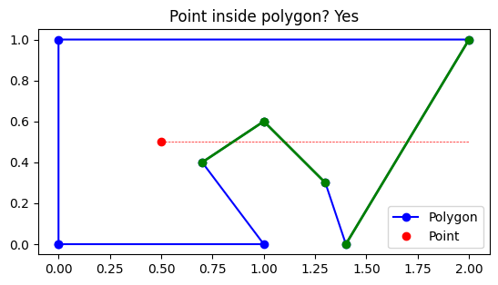

```python
point = (0.5,0.5)
inside, hits = inside_poly(polygon, point)
import matplotlib.pyplot as plt
fig, ax = plt.subplots()
poly_closed = polygon + [polygon[0]]
xs, ys = zip(*poly_closed)
ax.plot(xs, ys, 'b-o', label='Polygon')
ax.plot(point[0], point[1], 'ro', label='Point')
ax.plot([point[0],2],[point[1],point[1]],'r--', lw=0.5)
for (x1, y1, x2, y2) in hits:
    ax.plot([x1, x2], [y1, y2], 'g-o', lw=2)
ax.set_aspect('equal')
ax.legend()
ax.set_title("Point inside polygon?" + (" Yes" if inside else " No"))
plt.show()
```

## Optionale und benannte Parameter

In Python können Funktionen **optionale Parameter** haben, die Standardwerte besitzen.

- Diese Parameter müssen am Ende der Parameterliste stehen.
- Beim Aufruf der Funktion können diese Parameter weggelassen werden, in diesem Fall wird der Standardwert verwendet.
- Nach einem optionalen Parameter dürfen keine weiteren nicht-optionalen Parameter folgen.

```python
def greet(name, greeting="Hello", punctuation="!"):
    print(greeting, name + punctuation)

greet("Alice")
greet("Bob", "Hi")
greet("Diana", "Welcome", "!!!")
```

```
Hello Alice!
Hi Bob!
Welcome Diana!!!
```

### Achtung mit veränderlichen Standardwerten

Wenn ein optionaler Parameter ein veränderliches Objekt ist (z.B. eine Liste oder ein Wörterbuch), können unerwartete Ergebnisse auftreten.

- Der Standardwert wird nur einmal bei der Definition der Funktion erstellt, nicht bei jedem Aufruf.
- Änderungen am Standardwert in einem Funktionsaufruf wirken sich auf alle zukünftigen Aufrufe aus, die den Standardwert verwenden.

```python
def append_to_list(value, lst=[]):
    lst.append(value)
    return lst

list1 = append_to_list(1)
print("list1:", list1)
list2 = append_to_list(2)
print("list2:", list2)
```

[output not shown]

Daher sollte man nie veränderliche Objekte als Standardwerte verwenden.

- Wenn man einen Parameter mit einem veränderlichen Objekt als Standardwert benötigt, sollte man `None` als Standardwert verwenden und innerhalb der Funktion das veränderliche Objekt erstellen.

```python
def append_to_list(value, lst=None):
    if lst is None:
        lst = []
    lst.append(value)
    return lst

list1 = append_to_list(1)
print("list1:", list1)
list2 = append_to_list(2)
print("list2:", list2)
```

```
list1: [1]
list2: [2]
```

### Benannte Parameter von Funktionen

In Python können Funktionen auch benannte Parameter haben. Beim Aufruf der Funktion können die Parameter explizit mit ihrem Namen angegeben werden, wodurch die Reihenfolge der Parameter beim Aufruf beliebig wird. Das ist besonders nützlich bei Funktionen mit vielen optionalen Parametern von denen man nur einige wenige ändern möchte.

- Man kann benannte und unbenannte Parameter mischen, dabei müssen die unbenannten Parameter in der richtigen Reihenfolge zuerst kommen.
- Benannte Parameter können in beliebiger Reihenfolge angegeben werden.

```python
def introduce(first_name, last_name="", city="Unknown", occupation="Unemployed"):
    print("Hello, my name is", first_name, last_name + ".")
    print("I live in", city + " and work as a", occupation + ".")

introduce(occupation="Superhero", last_name="Parker", first_name="Peter", city="New York")
introduce(first_name="Michael", occupation="Clown")
introduce("Michael", occupation="Clown")
```

```
Hello, my name is Peter Parker.
I live in New York and work as a Superhero.
Hello, my name is Michael .
I live in Unknown and work as a Clown.
Hello, my name is Michael .
I live in Unknown and work as a Clown.
```

## Funktionen mit beliebig vielen Parametern

Manchmal ist es nützlich, eine Funktion zu definieren, die eine variable Anzahl von Argumenten akzeptiert. In Python kann dies mit `*args` und `**kwargs` erreicht werden:

- `*args` ermöglicht es, eine beliebige Anzahl von Positionsargumenten zu übergeben. Diese werden als Tupel innerhalb der Funktion behandelt.
- `**kwargs` ermöglicht es, eine beliebige Anzahl von benannten Argumenten zu übergeben. Diese werden als Dictionary innerhalb der Funktion behandelt.

```
def beispiel_funktion(*args, **kwargs):
```

```python
def sum_all(*args):
    if len(args) > 0:
        return sum(args)
    return None

print(sum_all(1, 2, 3))
print(sum_all(5, 10))
```

```
6
15
```

Im nächsten Beispiel wird eine Funktion definiert, der nicht nur positionelle sondern auch benannte Argumente übergeben werden können. Die Funktion sucht in den benannten Argumenten nach einem Schlüssel `car` und gibt dessen Wert aus, falls vorhanden.

```python
def look_for_car(*args,**kwargs):
    if 'car' in kwargs:
        print("Found a car:", kwargs['car'])
    else:
        print("No car found.")
look_for_car(3,2,1,3,car="Toyota", color="red")
look_for_car(10,13,color="blue", bike="Yamaha")
```

```
Found a car: Toyota
No car found.
```

### Was macht der `**` Operator vor `kwargs`?

Der `**` zerlegt ein `Dictionary` in einzelne Schlüssel-Wert-Paare, die dann als benannte Argumente an die Funktion übergeben werden können.

```python
def test(text,number):
    print(text * number)

test("Hello ", 3)
my_list = ["Hello ", 3]
test(*my_list)
my_dict = {'text': "Hello ", 'number': 3}
test(**my_dict)
```

```
Hello Hello Hello
Hello Hello Hello
Hello Hello Hello
```

Im obigen Beispiel enspricht der Aufruf `test(*my_list)` dem Aufruf `test("Hello ", 3)` und der Aufruf `test(**my_dict)` dem Aufruf `test(text="Hello ", number=3)`.

## Funktionen als Rückgabewerte

Funktionen können auch andere Funktionen als Rückgabewerte haben. Das ermöglicht es, Funktionen zu erstellen, die andere Funktionen generieren oder modifizieren.

Im folgenden Beispiel wird eine Funktion `power_function` definiert, die eine andere Funktion zurückgibt, die eine Zahl auf eine bestimmte Potenz hebt: `square` und `cube` sind wieder Funktionen, die man aufrufen kann.

```python
def power_function(exponent):
    def power(base):
        return base ** exponent
    return power

square = power_function(2)
cube = power_function(3)

print("5 squared is", square(5))
print("2 cubed is", cube(2))
```

[output not shown]

Aufmerksame LeserInnen werden sich fragen, warum die innere Funktion die Variable `exponent` kennt, obwohl diese nicht als Parameter übergeben wird. Das liegt am `Scope` (Gültigkeitsbereich) von Variablen, der im nächsten Abschnitt erklärt wird.

## Scope von Variablen

Der Scope (Gültigkeitsbereich) einer Variable bestimmt, wo im Code die Variable zugänglich ist. In Python gibt es zwei Hauptarten von Scopes: global und lokal.

- Globale Variablen sind außerhalb von Funktionen definiert und können von überall im Code, einschließlich innerhalb von Funktionen, verwendet werden.
  - Achtung: Wenn eine globale Variable innerhalb einer Funktion verändert werden soll, muss das `global` Schlüsselwort verwendet werden (siehe weiter unten).
- Lokale Variablen sind innerhalb einer Funktion definiert und nur innerhalb dieser Funktion zugänglich. Sie existieren nur während der Ausführung der Funktion und werden gelöscht, wenn die Funktion beendet ist.
- Die Funktionen `locals()` und `globals()` können verwendet werden, um die aktuellen lokalen und globalen Variablen anzuzeigen.

Im Folgenden Beispiel wird eine globale Variable `my_pi` innerhalb der Funktion `calculate_circumference` verwendet:

```python
my_pi = 3.14159
def calculate_circumference(radius):
    print("Local variables:", locals())
    return 2 * my_pi * radius
print(calculate_circumference(5))
```

```
Local variables: {'radius': 5}
31.4159
```

Eine innerhalb der Funktion definierte Variable ist lokal und außerhalb der Funktion nicht zugänglich.

- Der Zugriff auf diese Variable von außerhalb der Funktion führt zu einem Fehler:

```python
def set_pi():
    inside_pi = 3.14159
    print("Inside function, inside_pi =", inside_pi)

set_pi()
print("Outside function, inside_pi =", inside_pi)
```

```
Inside function, inside_pi = 3.14159
```

```
---------------------------------------------------------------------------
NameError                                 Traceback (most recent call last)
Cell In[4], line 6
      3     print("Inside function, inside_pi =", inside_pi)
      5 set_pi()
----> 6 print("Outside function, inside_pi =", inside_pi)

NameError: name 'inside_pi' is not defined
```

**Wichtig**: Innerhalb der Funktion definierte Variablen können den gleichen Namen wie globale Variablen haben. In diesem Fall hat die lokale Variable Vorrang innerhalb der Funktion und überdeckt die globale Variable.

```python
var1 = 10
def example_function():
    var1 = 20
    print("Inside function, var1 =", var1)

print("Outside function, var1 =", var1)
example_function()
print("Outside function after function call, var1 =", var1)
```

```
Outside function, var1 = 10
Inside function, var1 = 20
Outside function after function call, var1 = 10
```

### Geschachtelte Funktionen

Lokale Variablen können in verschachtelten Funktionen verwendet werden. Dabei hat die innere Funktion Zugriff auf die lokalen Variablen der äußeren Funktion.

- Variablen haben Scope innerhalb der Funktion,in der sie definiert werden
- Das inkludiert alle Funktionen, die innerhalb dieser Funktion definiert sind
- Der Scope wird nach innen vererbt!

**LEGB-Regel**: Python sucht nach Variablen in folgender Reihenfolge:

1. **L**ocal: Lokaler Scope (innerhalb der aktuellen Funktion)
2. **E**nclosing: Eingeschlossener Scope (in umgebenden Funktionen)
3. **G**lobal: Globaler Scope (außerhalb aller Funktionen)
4. **B**uilt-in: Eingebaute Funktionen und Variablen (z.B. `print`, `len`)

```python
def power_function(exponent):
    print(locals())
    def power(base):
        print(locals())
        return base ** exponent
    return power
print("Call to power_function:")
square = power_function(2)
print("Call to square:")
print(square(5))
```

```
Call to power_function:
{'exponent': 2}
Call to square:
{'base': 5, 'exponent': 2}
25
```

### Closures und Cells

- Wenn im letzten Code-Beispiel die Funktion `square` aufgerufen wird, sollte es die lokale Variable `exponent` der Funktion `power_function` nicht mehr geben.
- Dennoch ist der Zugriff auf `exponent` in der Funktion `square` möglich. Die Variable ist auch in `locals()` sichtbar.
- Was passiert hier?

**Closures** sind Funktionen, die eine Referenz auf Variablen aus ihrem umgebenden Scope behalten, auch wenn dieser Scope nicht mehr aktiv ist. Diese Variablen werden in sogenannten **Cells** gespeichert.

- Vereinfacht gesagt ist eine Cell ein Abbild des Scopes an jenem Zeitpunkt an dem die umgebende Funktion endet.
- Beim Aufruf der inneren Funktion wird auf die gespeicherten Werte in den Cells zugegriffen.
- Das kann man über die versteckten Attribute (später mehr dazu) `__closure__` und `cell_contents` der Funktion herausfinden.

```python
print("The variable 'exponent' is stored in",square.__closure__)
print("The stored value of 'exponent' is", square.__closure__[0].cell_contents)
```

```
The variable 'exponent' is stored in (<cell at 0x724963449540: int object at 0x7249876ac110>,)
The stored value of 'exponent' is 2
```

### Das `global` Schlüsselwort

Das `global` Schlüsselwort wird verwendet, um anzugeben, dass eine Variable, die innerhalb einer Funktion definiert wurde,global sein soll.

- Wenn es die Variable bereits gibt, wird die globale Variable verwendet und kann dadurch verändert werden.
- Wenn es die Variable noch nicht gibt, wird sie neu als globale Variable erstellt.

```python
pi = 3.14159
def pi_is_exactly_3():
    global pi
    pi = 3

print("Before function call, pi =", pi)
pi_is_exactly_3()
print("After function call, pi =", pi)
```

```
Before function call, pi = 3.14159
After function call, pi = 3
```

**Achtung**: Veränderbare Objekte (wie Listen oder Dictionaries) können innerhalb einer Funktion verändert werden, ohne dass das `global` Schlüsselwort verwendet werden muss. Das führt zu unerwarteten Situationen:

- Im folgenden Beispiel macht `extend_list()` genau das erwartete, nämlich die Liste `my_list` um das Element `4` zu erweitern.
- Im Gegensatz dazu führt `extend_list2()` zu einem Fehler
  - Durch die Zuweisung `my_list = ...` wird eine neue lokale Variable `my_list` erzeugt, die die globale `my_list` verdeckt.
  - Daher wird im Rest der Zeile `my_list = my_list + [5]` auf die neue lokale Variable zugegriffen, die aber noch nicht definiert ist -> Fehler

```python
my_list = [1, 2, 3]
def extend_list():
    my_list.append(4)

def extend_list2():
    #global    # ohne global wird eine neue lokale Variable my_list erzeugt
    my_list = my_list + [5]


print("Before function call, my_list =", my_list)
extend_list()
print("After extend_list(), my_list =", my_list)
extend_list2()
```

```
Before function call, my_list = [1, 2, 3]
After extend_list(), my_list = [1, 2, 3, 4]
```

[output not shown]

### Das `nonlocal` Schlüsselwort

Das `nonlocal` Schlüsselwort wird verwendet, um anzugeben, dass eine Variable, die innerhalb einer verschachtelten Funktion definiert wurde, nicht lokal, sondern in der nächsthöheren umgebenden Funktion gesucht werden soll.

- Wenn es die Variable in der nächsthöheren umgebenden Funktion gibt, wird diese verwendet und kann dadurch verändert werden.
- Wenn es die Variable nicht gibt, wird ein Fehler ausgelöst.

```python
x = 0
def outer_function():
    x = 1
    def inner_function():
        nonlocal x
        x = 2
        print("Inside inner_function, x =", x)
    inner_function()
    print("Inside outer_function, x =", x)

print("Before function call, x =", x)
outer_function()
print("After function call, x =", x)
```

```
Before function call, x = 0
Inside inner_function, x = 2
Inside outer_function, x = 2
After function call, x = 0
```

## Decorators für Funktionen

Ein Decorator ist eine spezielle Art von Funktion, die eine andere Funktion als Argument nimmt und eine neue Funktion zurückgibt. Decorators werden verwendet, um das Verhalten von Funktionen zu ändern oder zu erweitern, ohne den ursprünglichen Funktionscode zu verändern.

- Decorators werden mit dem `@`-Symbol vor der Funktionsdefinition angewendet.

```
def decorator_funktion(original_funktion):
    def new_function(parameters):
        ### Veränderung der Funktionalität
    return new_function

@decorator_funktion
def meine_funktion():
    ### ursprüngliche Funktionalität
```

### Beispiel: Funktionsaufrufe zählen

- Der Decorator verwendet eine globale Variable `function_calls`, um die Anzahl der Aufrufe zu speichern.
- Wir verwenden `*args` und `**kwargs`, um sicherzustellen, dass die dekorierte Funktion beliebige Argumente akzeptieren kann.

```python
function_calls = 0

def loging_decorator(func):
    def func_with_log(*args, **kwargs):
        global function_calls
        function_calls += 1
        result = func(*args, **kwargs)
        return result
    return func_with_log

@loging_decorator
def add(a, b):
        return a + b

print(add(3, 4))
print(add(10, 20))
print("Function 'add' was called", function_calls, "times.")
```

```
7
30
Function 'add' was called 2 times.
```

### Beispiel: Debugging Decorator

Ein weiterer nützlicher Decorator ist ein Debugging-Decorator, der die Argumente und den Rückgabewert einer Funktion ausgibt.

- `.__name__` liefert den Namen der Funktion als String

```python
def debug_decorator(func):
    def wrapper(*args, **kwargs):
        print(f"Aufruf von {func.__name__} mit args: {args}")
        result = func(*args, **kwargs)
        print(f"{func.__name__} hat {result} zurückgegeben")
        return result
    return wrapper

@debug_decorator
def multiply(x, y):
    return x * y

print(multiply(3, 4))
```

```
Aufruf von multiply mit args: (3, 4)
multiply hat 12 zurückgegeben
12
```

## `lambda` Funktionen & das `functools`-Modul

`lambda` Funktionen sind anonyme Funktionen (Funktionen ohne Namen), die in einer einzigen Zeile definiert werden können. Syntax:

```
lambda parameter1, parameter2, ... : ausdruck
```

- `lambda` Funktionen können beliebig viele Parameter haben, aber nur einen Ausdruck, der ausgewertet und zurückgegeben wird.
- Sie sind nützlich für kurze Funktionen, die nur einmal verwendet werden, z.B. als Argumente für andere Funktionen wie `map()`, `filter()` und `sort()`.

```python
absmax = lambda x, y: x if abs(x) > abs(y) else y
print(absmax(-10, 5))
```

```
-10
```

### Beispiel: `sort()` mit benutzderfiniertem Sortierkriterium

Die eingebaute Funktion `sort()` kann mit dem Parameter `key` ein benutzerdefiniertes Ordnungskriterium verwenden, um die Sortierreihenfolge zu bestimmen.

- Das Ordnungskriterium muss ein Argument (das zu vergleichende Objekt) haben und einen Wert zurückgeben, der für die Sortierung verwendet wird.

Im folgenden Beispiel wird eine Liste von Zahlen nach ihrem Absolutwert sortiert:

```python
my_list = [3, -7, 2, 5, -1]
my_list.sort(key=lambda x: abs(x))
print(my_list)
```

```
[-1, 2, 3, 5, -7]
```

`sort()` versteht die lexikographische Sortierung von Strings. Damit kann man auch Zahlen lexikographisch ordnen:

```python
my_list = [1, 14, 2,25,534,21,111]
my_list.sort(key=lambda x: str(x))
print(my_list)
```

```
[1, 111, 14, 2, 21, 25, 534]
```

Kann man zwei Objekte nicht natürlich einordnen, sondern nur vergleichen, so muss man eine benutzerdefinierte Vergleichsfunktion verwenden.

- Diese Funktion muss zwei Argumente (die zu vergleichenden Objekte) haben und einen Wert zurückgeben, der für die Sortierung verwendet wird.
  - Negativer Wert, wenn das erste Objekt kleiner ist
  - Null, wenn beide Objekte gleich sind
  - Positiver Wert, wenn das erste Objekt größer ist

```python
from functools import cmp_to_key
my_list = ["Hallo", "lo", "allo", "o"]
my_list.sort(key = cmp_to_key(lambda x,y: x.find(y)))
print(my_list)
```

```
['o', 'lo', 'allo', 'Hallo']
```

### Beispiel: `map()`

`map()` ist eine eingebaute Funktion in Python, die eine gegebene Funktion auf alle Elemente eines iterierbaren Objekts (Liste, Tupel, Set,...) anwendet und ein neues iterierbares Objekt zurückgibt.

Syntax:

```
map(funktion, iterierbares_objekt)
```

- `funktion` ist die Funktion, die auf jedes Element des iterierbaren Objekts
- `iterierbares_objekt` ist das Objekt (z.B. eine Liste), dessen Elemente verarbeitet werden sollen

Der Rückgabewert von `map()` ist ein `map` Objekt, das in eine Liste oder ein anderes iterierbares Objekt umgewandelt werden kann, wenn nötig.

```python
my_list = [3, -7, 2, 5, -1]
my_squared_list = list(map(lambda x: x**2, my_list))
print(my_squared_list)
print(list(map(lambda x: x>=0, my_list)))
```

```
[9, 49, 4, 25, 1]
[True, False, True, True, False]
```

### Beispiel: `filter()`

`filter()` ist eine eingebaute Funktion in Python, die eine gegebene Funktion auf alle Elemente eines iterierbaren Objekts (wie einer Liste) anwendet und nur die Elemente zurückgibt, für die die Funktion `True` ergibt. Syntax:

```
filter(funktion, iterierbares_objekt)
```

- `funktion` ist die Funktion, die auf jedes Element des iterierbaren Objekts angewendet wird und einen booleschen Wert zurückgibt
- `iterierbares_objekt` ist das Objekt (z.B. eine Liste), dessen Elemente gefiltert werden sollen

Der Rückgabewert von `filter()` ist ein `filter` Objekt, das in eine Liste oder ein anderes iterierbares Objekt umgewandelt werden kann, wenn nötig.

```python
my_list = [3, -7, 2, 5, -1]
pos_list = list(filter(lambda x: x >= 0, my_list))
neg_list = list(filter(lambda x: x < 0, my_list))
print("Positive numbers:", pos_list)
print("Negative numbers:", neg_list)
```

```
Positive numbers: [3, 2, 5]
Negative numbers: [-7, -1]
```

### Beispiel: `reduce()`

`reduce()` ist eine Funktion im `functools`-Modul, die eine gegebene Funktion auf die Elemente eines iterierbaren Objekts (wie einer Liste) anwendet und einen einzigen kumulierten Wert zurückgibt. Syntax:

```
from functools import reduce
reduce(function, iterierbares_objekt, initialwert)
```

Unten wird z.B. die Produktfunktion $(x,y)\mapsto xy$ auf die Liste $[3, -7, 2, 5, -1]$ angewendet. Intern, wird folgendermaßen gerechnet: $$(((3 \cdot -7) \cdot 2) \cdot 5) \cdot -1 = 210$$

```python
from functools import reduce
my_list = [3, -7, 2, 5, -1]
sum = reduce(lambda x, y: x + y, my_list) # Das selbe wie sum(my_list)
prod = reduce(lambda x, y: x * y, my_list)
print("Sum:", sum)
print("Product:", prod)

# Version vom Produkt mit Ausgabe der Zwischenschritte
def prod_verbose(x, y):
    print(f"Multiplying {x} and {y}")
    return x * y
reduce(prod_verbose, my_list)
```

```
Sum: 2
Product: 210
Multiplying 3 and -7
Multiplying -21 and 2
Multiplying -42 and 5
Multiplying -210 and -1
```

```
210
```

### Achtung: Auch `lambda` Funktionen beachten den Scope

`lambda` Funktionen verhalten sich genauso wie normale Funktionen hinsichtlich des Scopes von Variablen.

- Durch die kompakte Schreibweise wird das auch von erfahrenen Programmierern und Programmiererinnen manchmal übersehen.
- Im Beispiel unten hat die Laufvariable `i` den Wert 4 zum Zeitpunkt des Aufrufs der `lambda` Funktionen.
- Diese Verhalten hat nichts mit `lambda` Funktionen zu tun, sondern gilt für alle Funktionen.

```python
func_list = []
for i in range(5):
    func_list.append(lambda x: x + i)

for f in func_list:
    print(f(10))  # Erwartet: 10, 11, 12, 13, 14
```

```
14
14
14
14
14
```

Abhilfe schafft die Verwendung einer Wrapper-Funktion, die den gewünschten Wert als Parameter übernimmt und eine `lambda` Funktion zurückgibt.

- Wie oben im Abschnitt über Closures und Cells beschrieben, wird der Wert zum Zeitpunkt der Rückgabe der `lambda` Funktion in einer Cell gespeichert.
- Diese Cell wird dann von der `lambda` Funktion verwendet, wenn sie aufgerufen wird.

```python
func_list = []
def make_lambda(i):
    return lambda x: x + i

for i in range(5):
    func_list.append(make_lambda(i))
for f in func_list:
    print(f(10))
```

```
10
11
12
13
14
```

# Details zu Objekten, Variablen, und Mutability

Veränderliche Datentypen können nach ihrer Erstellung geändert werden, während unveränderliche Datentypen nicht geändert werden können.

- **unveränderlich (immutable)**: Integer, Float, String, Boolean, Tupel
- **veränderlich (mutable)**: Listen, Mengen, Wörterbücher

In Python unterscheidet man zwischen

- **Objekten**
  - mit einem Datentyp und Wert
  - z.B. `3`, `"Hello"`, `[1, 2, 3]`
- **Variablen**
  - Namen, die auf Objekte verweisen
  - Man sagt auch, dass Variablen auf Objekte "zeigen" oder "verweisen"
  - Die Variable ist eine Referenz auf das Objekt

Man sollte sich vorstellen, dass eine Variable wie ein Namensschild ist, das an ein Objekt angehängt wird. Das Objekt selbst liegt irgendwo im Speicher des Computers.

## Mutability und Zuweisung

Bei der Zuweisung

```
a = 3
a = 4
```

wird das Namensschild `a` zuerst an das Objekt `3` gehängt und dann an das Objekt `4`. Das Objekt `3` bleibt unverändert im Speicher, aber `a` verweist jetzt auf das Objekt `4`. Python verwaltet den Speicher automatisch und entfernt ungenutzte Objekte, wenn keine Variablen mehr darauf verweisen.

Etwas komplizierter wird es bei veränderlichen Datentypen wie Listen:

```
my_list = [1, 2, 3]
my_list[0] = 4
```

Hier zeigt das Namensschild `my_list` auf eine Liste im Speicher. Wenn wir `my_list[0] = 4` ausführen, ändern wir das Objekt, auf das `my_list` zeigt, indem wir das erste Element der Liste von `1` auf `4` ändern. Das Namensschild `my_list` bleibt jedoch auf dem selben Listenobjekt im Speicher. Wenn wir allerdings

```
my_list = [4, 5, 6]
```

ausführen, wird das Namensschild `my_list` einem neuen Listenobjekt `[4, 5, 6]` im Speicher umgehängt. Das ursprüngliche Listenobjekt `[4, 2, 3]` bleibt unverändert im Speicher (und wird eventuell gelöscht), aber `my_list` verweist jetzt auf das neue Objekt.

### `id`

Die Funktion `id()` gibt die eindeutige Identifikationsnummer eines Objekts zurück, die dessen Speicheradresse repräsentiert. Diese ID bleibt während der Lebensdauer des Objekts konstant. Wenn eine Variable auf ein neues Objekt zeigt, ändert sich die ID der Variable, da sie jetzt auf ein anderes Objekt verweist. Dies eignet sich gut, um zu verstehen, wie Variablen und Objekte in Python zusammenhängen. Im folgenden Beispiel sieht man, dass sich die ID des Objekts, auf das `x` und `y` zeigen nicht ändert wenn die Liste verlängert wird (Listen sind veränderlich). Die ID von `y` ändert sich aber, wenn `y` auf eine neue Liste zeigt (obwohl die Liste die selben Elemente enthält).

```python
x = [1, 2, 3]
y = x
print("id(x):", id(x))
print("id(y):", id(y))

y.append(4)
print("After modifying y:")
print("x:", x)
print("y:", y)
print("id(x):", id(x))
print("id(y):", id(y))

y = [1, 2, 3, 4]
print("x:", x)
print("y:", y)
print("id(x):", id(x))
print("id(y):", id(y))
```

```
id(x): 4362604800
id(y): 4362604800
After modifying y:
x: [1, 2, 3, 4]
y: [1, 2, 3, 4]
id(x): 4362604800
id(y): 4362604800
x: [1, 2, 3, 4]
y: [1, 2, 3, 4]
id(x): 4362604800
id(y): 4362668864
```

Kleine Zahlen werden in Python oft zwischengespeichert, daher haben sie manchmal die gleiche ID, auch wenn sie unterschiedliche Variablen sind.

```python
a = 3
b = 3
print("id(a):", id(a))
print("id(b):", id(b))
a = 1200
b = 1200
print("id(a):", id(a))
print("id(b):", id(b))
```

```
id(a): 136806325551408
id(b): 136806325551408
id(a): 136806121038320
id(b): 136806121038544
```

Der `is` Operator prüft, ob zwei Variablen auf dasselbe Objekt im Speicher verweisen. Es wird einfach die IDs der beiden Variablen verglichen. Das heißt:

```
a is b
```

ist äquivalent zu

```
id(a) == id(b)
```

## Zuweisung, Shallow Copy, Deep Copy

Es können auch mehrere Variablen auf dasselbe Objekt verweisen. Ändert man eine Variable die auf ein veränderliches Objekt zeigt, so ändert sich auch der Wert der anderen Variablen, die auf dasselbe Objekt zeigen. Das Objekt `[1, 2, 3]` wird nur einmal im Speicher abgelegt und beide Variablen `a` und `b` verweisen auf dasselbe Objekt. Das Objekt hat also zwei verschiedene Namen.

```python
a = [1, 2, 3]
b = a
a.append(4)
print(a)
print(b)
```

```
[1, 2, 3, 4]
[1, 2, 3, 4]
```

Will man eine echte Kopie eines veränderlichen Objekts erstellen, so dass zwei verschiedene Objekte im Speicher existieren, die unabhängig voneinander verändert werden können, so spricht man von **Shallow Copy**. Dies kann man in Python mit dem Modul `copy` erreichen:

```python
import copy
a = [1, 2, 3]
b = copy.copy(a)
a.append(4)
print(a)
print(b)
```

```
[1, 2, 3, 4]
[1, 2, 3]
```

Alternativ kann man auch die Methode `list.copy()` oder einfach Slicing verwenden

```python
a = [1, 2, 3]
b = a.copy()
c = a[:]
a.append(4)
print(a)
print(b)
print(c)
```

```
[1, 2, 3, 4]
[1, 2, 3]
[1, 2, 3]
```

Falls das veränderliche Objekt selbst wieder veränderliche Objekte enthält (z.B. eine Liste von Listen), so wird bei einer Shallow Copy nur die äußere Ebene kopiert. Die inneren Objekte werden weiterhin von beiden Kopien gemeinsam genutzt.

```python
import copy
a = [1, 2, [3, 4]]
b = copy.copy(a)
a[2].append(5)
a.append(6)
print(a)
print(b)
```

```
[1, 2, [3, 4, 5], 6]
[1, 2, [3, 4, 5]]
```

Will man eine völlig unabhängige Kopie eines veränderlichen Objekts erstellen, einschließlich aller darin enthaltenen veränderlichen Objekte, so spricht man von **Deep Copy**

```python
import copy
a = [1, 2, [3, 4]]
b = copy.deepcopy(a)
a[2].append(5)
a.append(6)
print(a)
print(b)
```

```
[1, 2, [3, 4, 5], 6]
[1, 2, [3, 4]]
```

## Mutability und Funktionen

Ein wichtiger Aspekt von Variablen ist ihr Verhalten in Funktionen. Beim Funktionsaufruf wird die Variable als Argument übergeben. Das heißt, es wird nur die Referenz (der Name) auf eine lokale Variable kopiert, nicht das eigentliche Objekt.

Dieses Vorgehen impliziert, dass veränderliche Objekte (wie Listen) innerhalb der Funktion verändert werden können, und diese Änderungen auch außerhalb der Funktion sichtbar sind. Unveränderliche Objekte (wie Integer oder Strings) können innerhalb der Funktion nicht verändert werden, da jede Änderung ein neues Objekt erzeugt. Nur die lokale Variable innerhalb der Funktion wird aktualisiert und zeigt auf das neue Objekt.

```python
def change_list(input_list):
    input_list[0] = 99

my_list = [1, 2, 3]
change_list(my_list)
print(my_list)

def change_integer(input_int):
    input_int = 99

my_int = 1
change_integer(my_int)
print(my_int)
```

```
[99, 2, 3]
1
```

### Beispiel: Zuweisung von Listen

**Achtung**: Auch bei veränderlichen Objekten führt eine Zuweisung eines neuen Objekts innerhalb der Funktion dazu, dass die lokale Variable auf das neue Objekt zeigt, ohne das ursprüngliche Objekt zu verändern (wie oben bei 'Mutability und Zuweisung' beschrieben).

```python
def change_list(input_list):
    input_list = [99, 100]

my_list = [1, 2, 3]
change_list(my_list)
print(my_list)
```

```
[1, 2, 3]
```

**Achtung**: Die genauen Regeln, wann ein neues Objekt erstellt wird, sind manchmal subtil und hängen vom Datentyp und der Operation ab. Es ist wichtig, diese Konzepte zu verstehen, um unerwartetes Verhalten in Programmen zu vermeiden.

Siehe folgendes Beispiel:

```python
def duplicate_list(input_list):
    input_list += input_list

def duplicate_list2(input_list):
    input_list = input_list + input_list

my_list = [1, 2, 3]
duplicate_list2(my_list)
print(my_list)
duplicate_list(my_list)
print(my_list)
```

```
[1, 2, 3]
[1, 2, 3, 1, 2, 3]
```

Obwohl `a+=b` und `a = a + b` in vielen Fällen das gleiche Ergebnis liefern, gibt es hier Unterschiede im Verhalten bei veränderlichen Datentypen.

- `a += b` modifiziert das Objekt, auf das `a` zeigt, direkt (sofern `a` veränderlich ist). Das bedeutet, dass das ursprüngliche Objekt verändert wird.
- `a = a + b` erstellt ein neues Objekt und weist diese neue Objekt der Variable `a` zu. Das ursprüngliche Objekt bleibt unverändert.

### Mutability sollte in Funktionen nicht ausgenutzt werden

Es ist eine gute Praxis, Funktionen so zu gestalten, dass sie keine Seiteneffekte haben, d.h. sie sollten keine veränderlichen Argumente modifizieren. Stattdessen sollten Funktionen neue Objekte zurückgeben, wenn Änderungen erforderlich sind. Dies macht den Code vorhersehbarer und leichter zu verstehen.

Folgendes Beispiel zeigt zwei Versionen einer Funktion, die eine Liste der Länge 2 aufsteigend sortiert. Die erste Version modifiziert die übergebene Liste, die zweite Version gibt eine neue sortierte Liste zurück.

```python
def sort_list1(input_list):
    if input_list[0] > input_list[1]:
        input_list[0], input_list[1] = input_list[1], input_list[0]

def sort_list2(input_list):
    if input_list[0] > input_list[1]:
        return [input_list[1], input_list[0]]
    else:
        return input_list


my_list = [2, 1]
sort_list1(my_list)
print(my_list)

my_list = [2, 1]
my_list = sort_list2(my_list)
print(my_list)
```

```
[1, 2]
[1, 2]
```

### Negativbeispiel

Eine Funktion soll das Minimum einer Liste zurückgeben. Die Funktion `get_min` bewerkstelligt dies, indem sie die Liste sortiert und dann das erste Element zurückgibt. Da Listen veränderlich sind, wird die ursprüngliche Liste außerhalb der Funktion ebenfalls verändert. Die Funktion hat also einen Seiteneffekt (das Sortieren der Liste), welcher unerwartet sein kann und später möglicherweise zu Fehlern führt.

```python
def get_min(input_list):
    input_list.sort()
    return input_list[0]

student_grades = [2, 1, 4, 5, 3]
print("Grade on third exam:", student_grades[2])
print("Best grade:", get_min(student_grades))
print("Grade on third exam:", student_grades[2])
```

```
Grade on third exam: 4
Best grade: 1
Grade on third exam: 3
```

Besser ist es, die eingebaute Funktion `min` zu verwenden, die das Minimum einer Liste zurückgibt, ohne die ursprüngliche Liste zu verändern.

```python
def get_min(input_list):
    return min(input_list)
student_grades = [2, 1, 4, 5, 3]
print("Grade on third exam:", student_grades[2])
print("Best grade:", get_min(student_grades))
print("Grade on third exam:", student_grades[2])
```

```
Grade on third exam: 4
Best grade: 1
Grade on third exam: 4
```

Wenn man die Funktion `min` nicht kennt, so könnte man auch eine Kopie der Liste erstellen, diese sortieren und dann das erste Element zurückgeben. So wird die ursprüngliche Liste nicht verändert.

```python
import copy
def get_min(input_list):
    tmp = copy.copy(input_list)
    tmp.sort()
    return tmp[0]
student_grades = [2, 1, 4, 5, 3]
print("Grade on third exam:", student_grades[2])
print("Best grade:", get_min(student_grades))
print("Grade on third exam:", student_grades[2])
```

```
Grade on third exam: 4
Best grade: 1
Grade on third exam: 4
```

# Kommentare im Code

Kommentare im Code sind wichtig, um den Code verständlicher zu machen. Sie werden vom Interpreter ignoriert und dienen nur den Menschen, die den Code lesen.

- **Notwending**, um eigene Programme auch später noch zu verstehen
- **Hilfreich** für andere, die den Code lesen (z.B. bei Teamarbeit)
  - Besonders nützlich für die Übungen (= soziale Komponente der Übung)
- Sehr brauchbar zur Fehlersuche
  - Fehler können so leichter gefunden/ eingekreist werden
  - Teile des Codes können so temporär deaktiviert werden
- **Wichtig**: Kommentare sollten den Code erklären, nicht den offensichtlichen Code wiederholen
  - Schlecht: `x = x + 1 # increase x by 1`
  - Gut: `x = x + 1 # count the number of tries`

In Python beginnen Kommentare mit dem `#` Zeichen und gehen bis zum Ende der Zeile. Beispiel:

```python
# Script to read in two numbers and print their minimum

# Read the numbers from the user
a = float(input("Enter the first number: "))
b = float(input("Enter the second number: "))

# Determine the minimum
if a < b:
    minimum = a
else:
    minimum = b

# Print the result
print("The minimum is:", minimum)
```

```
The minimum is: 4.0
```

```python
# Demonstration of swapping two variables in Python
x = 5
y = 10
print("Before swapping: x =", x, ", y =", y)
x, y = y, x  # This swaps the values of x and y without a temporary variable
print("After swapping: x =", x, ", y =", y)
```

```
Before swapping: x = 5 , y = 10
After swapping: x = 10 , y = 5
```

### Beispiel zur Fehlersuche mit Kommentaren

Wenn der Code unerwartets Verhalten zeigt, kann man Teile des Codes auskommentieren, um den Fehler einzugrenzen.

- Der Interpreter verortet den Fehler zuerst in der Funktion `compute_speed` (wo auch tatsächlich durch Null dividiert wird)
- Das eigentliche Problem ist aber, dass die Funktion `get_time` den Wert `0` zurückgibt
- Durch Auskommentieren des Funktionsaufrufs `time = get_time()` verschwindet der Fehler
- Daher kann man davon ausgehen, dass das Problem in der Funktion `get_time` liegt

```python
def compute_speed(distance, time):
    result = distance / time
    print("Result:", result)

def get_time():
    return 0

distance = 10
time = 1

time = get_time()
compute_speed(distance, time)
```

```
---------------------------------------------------------------------------
ZeroDivisionError                         Traceback (most recent call last)
Cell In[13], line 12
      9 time = 1
     11 time = get_time()
---> 12 compute_speed(distance, time)

Cell In[13], line 2, in compute_speed(distance, time)
      1 def compute_speed(distance, time):
----> 2     result = distance / time
      3     print("Result:", result)

ZeroDivisionError: division by zero
```

```python
def compute_speed(distance, time):
    result = distance / time
    print("Result:", result)

def get_time():
    return 0

distance = 10
time = 1

#time = get_time()
compute_speed(distance, time)
```

```
Result: 10.0
```

## Docstrings

Docstrings sind spezielle Kommentare, die am Anfang von Funktionen, Modulen oder Klassen (später) stehen und deren Zweck und Verwendung beschreiben. Sie werden in dreifachen Anführungszeichen (`"""`) eingeschlossen und können über die `help()` Funktion oder die `.__doc__` Eigenschaft abgerufen werden. Das ist besonders nützlich, wenn Code mit anderen geteilt wird. User können so schnell verstehen, was eine Funktion macht, ohne den Code selbst lesen zu müssen.

```python
def add_numbers(num1, num2):
    """
    Add two numbers and return the result.

    Parameters:
    num1 (float): The first number to add.
    num2 (float): The second number to add.

    Returns:
    float: The sum of num1 and num2.
    """
    return num1 + num2

help(add_numbers)
```

```
Help on function add_numbers in module __main__:

add_numbers(num1, num2)
    Add two numbers and return the result.

    Parameters:
    num1 (float): The first number to add.
    num2 (float): The second number to add.

    Returns:
    float: The sum of num1 and num2.
```

Viele eingebaute Funktionen und Module haben Docstrings in Python.

```python
help(print)
```

```
Help on built-in function print in module builtins:

print(...)
    print(value, ..., sep=' ', end='\n', file=sys.stdout, flush=False)

    Prints the values to a stream, or to sys.stdout by default.
    Optional keyword arguments:
    file:  a file-like object (stream); defaults to the current sys.stdout.
    sep:   string inserted between values, default a space.
    end:   string appended after the last value, default a newline.
    flush: whether to forcibly flush the stream.
```

```python
import random
help(random.randint)
```

```
Help on method randint in module random:

randint(a, b) method of random.Random instance
    Return random integer in range [a, b], including both end points.
```

## Pfeilnotation (->)

In Python kann man eine Pfeilnotation ähnlich zur mathematischen Schreibweise verwenden

- Datentypen werden mit `:` angegeben
- Der Rückgabewert wird mit `->` angegeben
- Diese Notation ist optional und wird vom Interpreter ignoriert
- Die Notation ist mit benannten Parametern kombinierbar

User können diese Informationen über die `.__annotations__` Eigenschaft der Funktion abrufen. Auch die `help()` Funktion zeigt diese Informationen an.

```python
def mult_with_int(x : float, y : int = 10) -> float:
    return x * y

print(mult_with_int.__annotations__)
help(mult_with_int)
```

```
{'x': <class 'float'>, 'y': <class 'int'>, 'return': <class 'float'>}
Help on function mult_with_int in module __main__:

mult_with_int(x: float, y: int = 10) -> float
```

# Rekursionen

Eine Funktion kann sich selbst aufrufen. Dies nennt man Rekursion. Rekursion kann verwendet werden, um Probleme zu lösen, die sich in kleinere Teilprobleme zerlegen lassen.

Diese Konzept ist sehr natürlich in der Mathematik, z.B. bei der Definition von Faktoriellen:

$$ n! = \begin{cases} 1 & \text{wenn } n = 0 \\ n \times (n-1)! & \text{wenn } n > 0 \end{cases} $$

Hier wird ein Problem (Berechnung von $n!$) auf ein einfacheres Problem (Berechnung von $(n-1)!$) zurückgeführt.

**Wichtig**:

- Jede rekursive Funktion muss eine Abbruchbedingung haben, um unendliche Rekursion zu vermeiden.
- Rekursive Funktionen können oft durch Schleifen (später) ersetzt werden, was in manchen Fällen effizienter ist.
- Rekursion ist oft eleganter und einfacher zu verstehen, Schleifen sind oft effizienter.

### Beispiel: Faktorielle

```python
def factorial(n):
    if n < 0:
        return -1 # Factorial is not defined for negative input, return -1 as error code
    elif n == 0:
        return 1 # stopping condition 0! = 1
    else:
        return n * factorial(n - 1)  # recursion step n! = n * (n-1)!

print("5! =",factorial(5))
```

```
5! = 120
```

- Im obigen Beispiel kann man die `else` Klauseln auch weglassen, da mit `return` die Funktion sofort verlassen wird

```python
def factorial(n):
    if n < 0:
        return -1 # Factorial is not defined for negative input, return -1 as error code
    if n == 0:
        return 1  # stopping condition 0! = 1
    return n * factorial(n - 1)  # recursion step n! = n * (n-1)!

print("5! =",factorial(5))
```

```
5! = 120
```

### Beispiel: Visualisierung der Rekursion

Um die Reihenfolge der Funktionsaufrufe zu visualisieren, verwenden wir eine sehr einfache Version der Funktion.

```
def factorial(n):
    if n==0:
        return 1
    return n * factorial(n-1)
```

Das folgende Bild zeigt den Rekursionsbaum für den Aufruf `factorial(3)`:

- Die schwarzen Pfeile illustrieren die Selbstaufrufe der Funktion
- Die orangefarbenen Pfeile zeigen die Rückgabe der Ergebnisse
- Funktionsblöcke die übereinander liegen visualisieren den selben Aufruf, vor (oben) und nach (unten) der Rückgabe

[figure not shown]

### Beispiel: Fibonacci-Zahlen

Die Fibonacci-Zahlen sind eine Folge von Zahlen, bei der jede Zahl die Summe der beiden vorhergehenden ist. Die Folge beginnt mit 0 und 1. Mathematisch ist die Fibonacci-Folge definiert als: $f_0 =0$, $f_1 =1$ und $$ f_n = f_{n-1} + f_{n-2} \quad\text{ für } n \geq 2 $$

```python
def fibonacci(n):
    if n < 0:
        return -1 # Fibonacci is not defined for negative input, return -1 as error code
    elif n == 0:
        return 0 # stopping condition f_0 = 0
    elif n == 1:
        return 1 # stopping condition f_1 = 1
    else:
        return fibonacci(n - 1) + fibonacci(n - 2)  # recursion step f_n = f_(n-1) + f_(n-2)

print("f_10 =",fibonacci(10))
```

```
f_10 = 55
```

## Rekursionstiefe

Als Rekursionstiefe bezeichnet man die maximale Anzahl von Aufrufen der selben Funktion, bevor ein Rückgabewert berechnet werden kann.

- Die Rekursionstiefe hängt immer vom Eingabewert ab, z.B.:
  - `factorial(3)` hat eine Rekursionstiefe von 4 (Aufrufe: `factorial(3)`, `factorial(2)`, `factorial(1)`, `factorial(0)`)
  - `fibonacci(5)` hat eine Rekursionstiefe von 9 (Aufrufe: `fibonacci(5)`, `fibonacci(4)`, 2x`fibonacci(3)`, 2x`fibonacci(2)`, 2x`fibonacci(1)`, `fibonacci(0)`)
  - Die Rekursionstiefe kann exponentiell mit dem Eingabewert wachsen (wie bei Fibonacci)
- Die Rekursionstiefe ist von Python selbst begrenzt und kann mit `sys.getrecursionlimit()` abgefragt und mit `sys.setrecursionlimit(n)` geändert werden.
  - Wird die maximale Rekursionstiefe überschritten, wird eine Fehlermeldung ausgegeben und das Programm abgebrochen.
  - Achtung: Eine zu hohe Rekursionstiefe kann dazu führen, dass der Python-Interpreter abstürzt.

```python
import sys
print("Recursion depth:", sys.getrecursionlimit())
```

```
Recursion depth: 3000
```

## Beispiel: Nullstellensuche mit dem Bisektionsverfahren

- Das Bisektionsverfahren ist ein numerisches Verfahren zur Bestimmung von Nullstellen einer Funktion. Es basiert auf dem Zwischenwertsatz, der besagt, dass eine stetige Funktion, die an zwei Punkten unterschiedliche Vorzeichen hat, mindestens eine Nullstelle zwischen diesen Punkten besitzt.
- **Gegeben**: Stetige Funktion $f: [a, b] \rightarrow \mathbb{R}$ mit $f(a) f(b) \leq 0$ (d.h. $f(a)$ und $f(b)$ haben unterschiedliche Vorzeichen) und eine vorgegebene Genauigkeit $\tau > 0$.
- **Tatsache**: Nach dem Zwischenwertsatz existiert mindestens eine Nullstelle $x^*\in [a, b]$ von $f$, also $f(x^*) = 0$.
- **Gesucht**: Approximation der Nullstelle: Ein Wert $x_0 \in [a,b]$ mit der Eigenschaft $|x_0-x^*| < \tau$.
- **Bisektionsverfahren**:
  1. Solange die Intervalbreite $|b-a|>2\tau$ ist, wiederhole die folgenden Schritte:
     1. Berechne den Mittelpunkt $m = \frac{a + b}{2}$.
     2. Wenn $f(m) f(a) < 0$, dann liegt die Nullstelle im Intervall $[a, m]$. Setze $b = m$.
     3. Andernfalls liegt die Nullstelle im Intervall $[m, b]$. Setze $a = m$.
- Das Verfahren basiert nur auf dem Zwischenwertsatz
- Das Verfahren terminiert immer, da die Intervallbreite in jedem Schritt halbiert wird.

### Illustration des Bisektionsverfahrens

[figure not shown]

```python
def f(x):
    return x**2 + 1/(2+x)-2

def bisection(f, a, b, tol):
    m = 0.5 * (a + b)
    if b-a < 2*tol:
        return m
    if f(a)*f(m) <= 0:
        return bisection(f, a, m, tol)
    else:
        return bisection(f, m, b, tol)

print("Root of f is approximately at x =", bisection(f, 0, 3, 0.001))
```

```
Root of f is approximately at x = 1.302978515625
```

# Code mehrfach ausführen mit Schleifen

In der Programmierung ist es oft notwendig, denselben Codeblock mehrfach auszuführen. Dies kann durch **Schleifen** erreicht werden.

In Python gibt es folgende Schleifenarten:

- `for` Schleifen: Diese werden verwendet, um über eine Sequenz (wie eine Liste, ein Tupel oder eine Zeichenkette) zu iterieren.
- `while` Schleifen: Diese führen einen Codeblock aus, solange eine bestimmte Bedingung wahr ist.

Aufgrund der unterschiedlichen Funktionsweisen spricht man auch von **Zählschleifen** (for) und **Bedingungsschleifen** (while).

In Aufgabenstellungen gibt es häufig Hinweise, dass eine Schleife verwendet werden kann:

- "Wiederhole bis.../ solange wie..."
- Summen $\sum_{i=1}^{n} a_j = a_1+\ldots +a_n$
- Produkte $\prod_{i=1}^{n} a_j = a_1 \cdot a_2 \cdot \ldots \cdot a_n$
- Laufvariablen $j=1,2,\ldots,n$

## `For`-Schleifen

Die Syntax einer `for`-Schleife in Python ist wie folgt:

```
for element in sequence:
    ####
    # Codeblock, der für jedes Element in der Sequenz ausgeführt wird
    ####
```

- `sequence` kann jedes iterierbare Objekt (Iterable) sein, wie eine Liste, ein Tupel, eine Zeichenkette oder ein Bereich (range) von Zahlen.
- Der Codeblock innerhalb der Schleife wird für jedes Element in der Sequenz ausgeführt (**Wichtig**: Einrückung durch Tab oder Leerzeichen beachten!).
- Die Variable `element` nimmt dabei nacheinander die Werte der Elemente in der Sequenz an.
- Die Variable `element` existiert auch nach der Schleife weiter und hat den letzten Wert der Sequenz.

```python
for i in range(5):
    print("Step ", i)

for i in range(10,30,5):
    print("Step ", i)
print("Value of i after loop:", i)
```

```
Step  0
Step  1
Step  2
Step  3
Step  4
Step  10
Step  15
Step  20
Step  25
Value of i after loop: 25
```

```python
my_list = ["Hello", "my", "name", "is", "Python"]
for word in my_list:
    print(word)
```

```
Hello
my
name
is
Python
```

```python
for c in "Python":
    print(c)
```

```
P
y
t
h
o
n
```

### `For`-Schleifen mit `enumerate`

Manchmal will man durch eine Liste iterieren und gleichzeitig den Index des aktuellen Elements kennen.

- Man kann eine `for`-Schleife mit `range(len(...))` verwenden, um die Indizes zu erhalten.
- Eine elegantere Lösung ist die Verwendung der Funktion `enumerate()`, die sowohl den Index als auch das Element zurückgibt.

```python
my_list = ["Hello", "my", "name", "is", "Python"]
for index, word in enumerate(my_list):
    print(f"Wort {index}: {word}")
```

```
Wort 0: Hello
Wort 1: my
Wort 2: name
Wort 3: is
Wort 4: Python
```

Im folgenden Beispiel wollen wir jedes zweite Wort der Liste ausgeben

```python
for index, word in enumerate(my_list):
    if index % 2 == 0:
        print(word)
```

```
Hello
name
Python
```

### Vorsicht beim verändern der Sequence während der Schleife

Wenn man die Sequence während der Iteration verändert (z.B. Elemente löscht), kann dies zu unerwartetem Verhalten führen, da die Indizes der verbleibenden Elemente sich ändern.

```python
my_list = list(range(10))
for i in my_list:
    if i % 2 == 0:
        del my_list[i]
print(my_list)
```

```
---------------------------------------------------------------------------
IndexError                                Traceback (most recent call last)
Cell In[3], line 4
      2 for i in my_list:
      3     if i % 2 == 0:
----> 4         del my_list[i]
      5 print(my_list)

IndexError: list assignment index out of range
```

## `While` Schleifen

Die Syntax einer `while`-Schleife in Python ist wie folgt:

```
while condition:
    ####
    # Codeblock der ausgeführt wird, solange die Bedingung wahr ist
    ####
```

- `condition` ist eine Bedingung, die entweder wahr (`True`) oder falsch (`False`) sein kann.
- Der Codeblock innerhalb der Schleife wird so lange ausgeführt, wie die Bedingung wahr ist (**Wichtig**: Einrückung durch Tab oder Leerzeichen beachten!)
  - Vor jedem Durchlauf wird die Bedingung überprüft und der Codeblock nur ausgeführt, wenn die Bedingung wahr ist.
  - "Solange etwas gilt, tue folgendes..."
- Es ist wichtig, dass die Bedingung irgendwann falsch wird, sonst entsteht eine Endlosschleife.
- Wenn die Bedingung von Anfang an falsch ist, wird der Codeblock kein einziges Mal ausgeführt (sog. Kopfgesteuerte Schleife).

```python
i = 0
while i < 5:
    print("Step ", i)
    i += 1
```

```
Step  0
Step  1
Step  2
Step  3
Step  4
```

Bedingungsschleifen machen meist nur Sinn, wenn die Laufbedingung komplexer ist als ein einfacher Zähler. Ansonsten sind `for`-Schleifen meist die bessere Wahl.

## Beispiel: Bisektionsverfahren mit Schleifen

Ein gutes Bespiel hierfür ist das **Bisektionsverfahren** zur Nullstellenbestimmung, welches wir schon vom Kapitel über Rekursion kennen.

```python
def f(x):
    return x**2 + 1/(2+x)-2

def bisection(f, a, b, tol):
    m = 0.5 * (a + b) # only necessary if while condition is never true
    while b-a > 2*tol:
        m = 0.5 * (a + b)
        if f(a)*f(m) <= 0:
            b = m
        else:
            a = m
    return m

print("Root of f is approximately at x =", bisection(f, 0, 3, 0.001))
```

```
Root of f is approximately at x = 1.30224609375
```

Im obigen Beispiel gibt es ein paar überflüssige Funktionsaufrufe, die wir vermeiden können. Das ist besonders dann wichtig, wenn die Funktion `f` sehr aufwendig zu berechnen ist (Zum Beispiel, wenn `f` selbst aus einer aufwendigen Simulation kommt).

```python
def bisection(f, a, b, tol):
    fa = f(a) # store f(a) to avoid multiple calls
    m = 0.5 * (a + b)
    while b-a > 2*tol:
        m = 0.5 * (a + b)
        fm = f(m) # store f(m) to avoid multiple calls
        if fa*fm <= 0:
            b = m
        else:
            a = m
            fa = fm
    return m

print("Root of f is approximately at x =", bisection(f, 0, 3, 0.001))
```

```
Root of f is approximately at x = 1.30224609375
```

## Beispiel: Euklidischer Algorithmus

- **Gegeben:** Zwei natürliche Zahlen $a,b\in \mathbb{N}$
- **Gesucht:** Der größte gemeinsame Teiler (greatest common divisior) $gcd(a,b)$ von $a$ und $b$.
1. Falls $a=b$, so ist $gcd(a,b)=a$.
2. Falls $a<b$, vertausche $a$ und $b$.
3. Ersetze $a$ durch $a-b$.
4. Wiederhole die Schritte 1-3, bis $a=b$.

Schritt 2 vertauscht die Zahlen. Das ist möglich, da $gcd(a,b)=gcd(b,a)$ gilt. Schritt 3 verkleinert die größere Zahl. Das ist möglich, da $gcd(a,b)=gcd(a-b,b)$ gilt.

**Satz**: Für $a,b \in \mathbb{N}$ mit $a\geq b$ gilt $gcd(a,b) = gcd(a-b,b)$.

**Beweis**: Eine Zahl $d$ teilt eine andere Zahl $a$, genau dann wenn eine weitere Zahl $k\in\mathbb{N}$ existiert, sodass $a = k d$ gilt. Sei also $d$ ein gemeinsamer Teiler von $a$ und $b$. Dann gibt es Zahlen $k_a,k_b\in \mathbb{N}$ mit $a = k_a d$ und $b = k_b d$. Daher gilt auch $$ a-b = k_a d - k_b d = (k_a - k_b) d, $$ also ist $d$ auch ein Teiler von $a-b$ (und auch von $a$ und $b$). Daher gilt $d \leq gcd(a-b,b)$. Da $d$ jeder Teiler von $a$ und $b$ sein kann, können wir auch $d = gcd(a,b)$ wählen und erhalten $gcd(a,b) \leq gcd(a-b,b)$. Die selbe Argumentation in die andere Richtung zeigt $gcd(a-b,b) \leq gcd(a,b)$, woraus die Behauptung folgt. $\square$

**Satz**: Der euklidische Algorithmus terminiert nach endlich vielen Schritten für alle Inputs $a,b\in \mathbb{N}$ mit $a,b>0$.

**Beweis**: Nach Schritt 2 gilt immer $a>b>0$. Daher haben wir $\max\{a-b,b\}\leq \max\{a,b\}-1$. Das heißt, in jedem Durchlauf wird nach Schritt 3 die Zahl $\max\{a,b\}$ um mindestens 1 verkleinert. Da $\max\{a,b\}$ immer eine natürliche Zahl größer als 0 ist, kann dies nur endlich oft geschehen, bevor $a=b$ gilt. $\square$

### Illustration des euklidischen Algorithmus

- Wir berechnen $gcd(6,14)=2$ mit dem euklidischen Algorithmus
- Die grauen Linien verdeutlichen, dass die Zwischenergebnisse immer den selben größten gemeinsamen Teiler haben.

[figure not shown]

### Implementierung des euklidischen Algorithmus

- berechnet $gcd(a,b)$ für $a,b\in \mathbb{N}$
- basiert auf $gcd(a,b) = gcd(a-b,b)$ für $a\geq b$
- für $a=b$ terminiert die Schleife mit Ergebnis $gcd(a,b)=a=b$

```python
def euklid(a,b):
    while a != b:
        if a > b:
            a = a - b
        else:
            b = b - a
    return a

print("gcd(6,14) =", euklid(6,14))
```

```
gcd(6,14) = 2
```

Wir können die Implementierung noch deutlich verbessern, indem wir statt $a-b$ den Modulo-Operator `%` verwenden. Dieser berechnet den Rest der Division von $a$ durch $b$.

- Euklidischer Algorithmus iteriert $a=a-b$ solange $a>b$ gilt.
- Der Algorithmus funktioniert auch, wenn man $a=a-b$ iteriert, solange $a\geq b$ gilt. Der einzige Unterschied ist, dass in diesem Fall die Schleife auch dann noch einmal durchlaufen wird, wenn $a=b$ gilt. In diesem Fall wird $a$ durch $a-b=0$ ersetzt und im nächsten Schritt terminiert die Schleife mit Ergebnis $gcd(a,b)=b$.
- Das ist äquivalent zu $a = a \mod b$. Wenn $a=0$ ist, terminiert die Schleife mit Ergebnis $gcd(a,b)=b$.

```python
def euklid_improved(a,b):
    while a != 0:
        if a < b:
            a, b = b, a
        a = a % b
    return b

print("gcd(6,14) =", euklid_improved(6,14))
```

```
gcd(6,14) = 2
```

Eine weitere Beobachtung ist, dass $a \mod b$ immer kleiner als $b$ ist. Daher können wir die Bedingung `if a < b:` weglassen und immer vertauschen.

```python
def euklid_improved_again(a,b):
    while b != 0:
        a, b = b, a % b
    return a

print("gcd(6,14) =", euklid_improved_again(6,14))
```

```
gcd(6,14) = 2
```

## Performance Vergleich mit `time`

- Diese Optimierungen sind nicht nur eine Fingerübung, sondern haben auch einen deutlichen Einfluss auf die Performance.
- Wir vergleichen die Laufzeiten der drei Versionen des euklidischen Algorithmus mit dem `time`-Modul.
- `time.time()` gibt die aktuelle Zeit in Sekunden seit dem 1.1.1970 zurück.

```python
import time

a, b = 123456789, 987654321

start = time.time()
euklid(a, b)
time_euklid = time.time() - start

start = time.time()
euklid_improved(a, b)
time_euklid_improved = time.time() - start

start = time.time()
euklid_improved_again(a, b)
time_euklid_improved_again = time.time() - start

print(f"euklid: {time_euklid:.6f} seconds")
print(f"euklid_improved: {time_euklid_improved:.6f} seconds")
print(f"euklid_improved_again: {time_euklid_improved_again:.6f} seconds")
```

```
euklid: 0.459110 seconds
euklid_improved: 0.000030 seconds
euklid_improved_again: 0.000024 seconds
```

Auch der Unterschied zwischen Rekursion und Iteration ist deutlich messbar. Wir vergleichen dazu die rekursive und die iterative Implementierung des Bisektionsverfahrens zur Nullstellenbestimmung.

```python
import time

def f(x):
    return x**2 + 1/(2+x)-2

def bisection(f, a, b, tol):
    fa = f(a) # store f(a) to avoid multiple calls
    m = 0.5 * (a + b)
    while b-a > 2*tol:
        m = 0.5 * (a + b)
        fm = f(m) # store f(m) to avoid multiple calls
        if fa*fm <= 0:
            b = m
        else:
            a = m
            fa = fm
    return m

def bisection_recursive(f, a, b, tol):
    m = 0.5 * (a + b)
    if b-a < 2*tol:
        return m
    if f(a)*f(m) <= 0:
        return bisection_recursive(f, a, m, tol)
    else:
        return bisection_recursive(f, m, b, tol)

tol = 1e-15
start = time.time()
bisection(f, 0, 3000, tol)
time_bisection = time.time() - start

start = time.time()
bisection_recursive(f, 0, 3000, tol)
time_bisection_recursive = time.time() - start

print(f"bisection (iterative): {time_bisection:.6f} seconds")
print(f"bisection (recursive): {time_bisection_recursive:.6f} seconds")
```

```
bisection (iterative): 0.000082 seconds
bisection (recursive): 0.000106 seconds
```

## Schleifenkontrolle und Else-Blöcke

Um genauere Kontrolle über die Iterationen einer Schleife zu haben, gibt es die Befehle `break` und `continue`.

- `break`: Beendet die Schleife sofort, unabhängig davon, ob die Schleifenbedingung noch wahr ist.
- `continue`: Überspringt den aktuellen Durchlauf der Schleife und fährt mit dem nächsten Durchlauf fort.

Vor allem `break` ist besonders nützlich, wenn man eine komplizierte Abbruchbedingung hat, die nicht einfach in eine Laufbedingung für die While-Schleife umgewandelt werden kann.

Beim Bisektionsverfahren kann es zum Beispiel Sinn machen, auch dann die Schleife zu beenden wenn $f(m)$ sehr klein ist, also wenn wir eine sehr gute Näherung der Nullstelle gefunden haben.

```python
def bisection(f, a, b, tol):
    fa = f(a) # store f(a) to avoid multiple calls
    m = 0.5 * (a + b)
    while b-a > 2*tol:
        m = 0.5 * (a + b)
        fm = f(m) # store f(m) to avoid multiple calls
        if abs(fm) < tol:
            break   # exit the loop if we found a good approximation
        if fa*fm <= 0:
            b = m
        else:
            a = m
            fa = fm
    return m
```

Um das in der Laufbedingung der While-Schleife zu realisieren, müsste man den Code wie folgt ändern (was deutlich unübersichtlicher ist):

```python
def bisection(f, a, b, tol):
    fa = f(a) # store f(a) to avoid multiple calls
    m = 0.5 * (a + b)
    fm = f(m)
    while b-a > 2*tol and abs(fm) >= tol:
        m = 0.5 * (a + b)
        fm = f(m) # store f(m) to avoid multiple calls
        if abs(fm) < tol:
            break   # exit the loop if we found a good approximation
        if fa*fm <= 0:
            b = m
        else:
            a = m
            fa = fm
    return m
```

Außerdem kann man mit `break` auch eine **Fußgesteuerte Schleife** realisieren, die mindestens einmal durchlaufen wird. Dazu setzt man die Laufbedingung der While-Schleife auf `True` und bricht die Schleife mit `break` ab, wenn die Abbruchbedingung erfüllt ist. **Achtung**: Eine solche Schleife muss immer eine `break`-Anweisung enthalten, sonst entsteht eine Endlosschleife!

```python
while True:
    user_input = float(input("Enter a positive number: "))
    if user_input > 0:
        break
    print("That's not a positive number, try again.")
print("You entered:", user_input)
```

```
That's not a positive number, try again.
That's not a positive number, try again.
You entered: 6.0
```

### Beispiel: Fibonacci-Zahlen mit Schleifen

Erinnerung: Die Fibonacci-Zahlen sind eine Folge von Zahlen, die durch die Rekursionsvorschrift $$ F_0 = 0, \quad F_1 = 1, \quad F_n = F_{n-1} + F_{n-2} \text{ für } n\geq 2 $$ definiert sind.

Ziel: Berechne alle Folgenglieder bis zum ersten mit $F_n > c$ für eine gegebene Zahl $c\in\mathbb{N}$.

- Anstatt neue Variablen für jedes Folgenglied zu erstellen, ist es viel effizienter, nur zwei Variablen zu verwenden und diese in jeder Iteration zu aktualisieren.

```python
counter = 0
F0, F1 = 0, 1
c = 10
print(F0,F1, sep=", ", end=", ")
while True:
    tmp = F0 + F1
    F0 = F1
    F1 = tmp
    print(F1, end=", ")
    if F1 > c:
        break
```

```
0, 1, 1, 2, 3, 5, 8, 13,
```

Der Befehl `continue` kann verwendet werden, um bestimmte Iterationen zu überspringen. In diesem Beispiel wird `continue` verwendet, um ungerade Fibonacci-Zahlen zu überspringen und alle geraden Fibonacci-Zahlen bis zu einer gegebenen Grenze `c` auszugeben.

```python
counter = 0
F0, F1 = 0, 1
c = 10
print(F0,F1, sep=", ", end=", ")
while True:
    tmp = F0 + F1
    F0 = F1
    F1 = tmp
    if F1 % 2 == 1:
        continue
    print(F1, end=", ")
    if F1 > c:
        break
```

```
0, 1, 2, 8, 34,
```

### `else` Blöcke bei Schleifen

Genau wie bei `if`-Anweisungen können auch Schleifen mit einem `else`-Block kombiniert werden. Der Code im `else`-Block wird ausgeführt, wenn die Schleife regulär beendet wird, also nicht durch einen `break`-Befehl.

Das macht besonders bei `while`-Schleifen Sinn, um Code auszuführen, wenn die Schleife beendet wird, weil die Bedingung falsch ist.

```
while condition:
    ####
    # Codeblock der ausgeführt wird, solange die Bedingung wahr ist
    ####
else:
    ####
    # Codeblock der ausgeführt wird, wenn die Bedingung falsch ist. Die Schleife wird danach beendet.
    ####
```

Es kann aber auch bei `for`-Schleifen sinnvoll sein, um Code auszuführen, wenn die Schleife alle Elemente der Sequenz durchlaufen hat. Oder um Code auszuführen, wenn die `sequence` leer ist.

```
for element in sequence:
    ####
    # Codeblock, der für jedes Element in der Sequenz ausgeführt wird
    ####
else:
    ####
    # Codeblock der ausgeführt wird, wenn die Schleife regulär beendet wird (d.h. nicht durch einen `break`-Befehl)
    ####
```

```python
vector =  [1, 3, 5, 7, 9, 11, 13, 15]
target = 10
for n in vector:
    if n == target:
        print(f"Found {target} in vector, stopping search.")
        break
else:
    print(f"{target} not found in the list.")
```

```
10 not found in the list.
```

## Sortieralgorithmen

- Sortieralgorithmen ordnen eine Liste von Elementen in einer bestimmten Reihenfolge (z.B. aufsteigend oder absteigend).
- In Python gibt es die eingebaute Methode `list.sort()`, aber es macht Sinn sich mit einfachen Sortieralgorithmen zu beschäftigen, um ihre Funktionsweise zu verstehen.

### Bubble Sort

- Bubble Sort ist ein einfacher Sortieralgorithmus, der wiederholt benachbarte Elemente vertauscht, wenn sie in der falschen Reihenfolge sind.
- Der Algorithmus wiederholt diesen Prozess, bis die Liste vollständig sortiert ist.

```python
def bubble_sort(arr):
    n = len(arr)
    for i in range(n):
        # Last i elements are already sorted
        for j in range(0, n-i-1):
            if arr[j] > arr[j+1]:
                # Swap if the element found is greater than the next element
                arr[j], arr[j+1] = arr[j+1], arr[j]

# Example usage
data = [64, 34, 25, 12, 22, 11, 90]
bubble_sort(data)
print("Sorted array:", data)
```

```
Sorted array: [11, 12, 22, 25, 34, 64, 90]
```

### Minsort

- Minsort (auch Selection Sort genannt) ist ein weiterer einfacher Sortieralgorithmus, der wiederholt das kleinste (oder größte) Element aus der unsortierten Liste auswählt und es an die richtige Position in der sortierten Liste verschiebt.

```python
def minsort(arr):
    n = len(arr)
    for i in range(n):
        # Find the minimum element in the unsorted portion of the array
        min_idx = i
        for j in range(i+1, n):
            if arr[j] < arr[min_idx]:
                min_idx = j
        # Swap the found minimum element with the first element of the unsorted portion
        arr[i], arr[min_idx] = arr[min_idx], arr[i]

# Example usage
data = [64, 34, 25, 12, 22, 11, 90]
minsort(data)
print("Sorted array:", data)
```

```
Sorted array: [11, 12, 22, 25, 34, 64, 90]
```

### Quicksort

- Quicksort ist ein effizienter Sortieralgorithmus, der das "Teile und Herrsche"-Prinzip verwendet.
- Der Algorithmus wählt ein "Pivot"-Element aus der Liste und partitioniert die anderen Elemente in zwei Unterlisten: diejenigen, die kleiner als das Pivot sind, und diejenigen, die größer als das Pivot sind.
- Diese Unterlisten werden dann rekursiv sortiert und zusammengeführt, um die endgültige sortierte Liste zu erhalten.

```python
def quicksort(arr):
    if len(arr) <= 1:
        return arr
    pivot = arr[len(arr) // 2]  # Choose the middle element as the pivot
    left = [x for x in arr if x < pivot]  # Elements less than the pivot
    middle = [x for x in arr if x == pivot]  # Elements equal to the pivot
    right = [x for x in arr if x > pivot]  # Elements greater than the pivot
    return quicksort(left) + middle + quicksort(right)

# Example usage
data = [64, 34, 25, 12, 22, 11, 90]
sorted_data = quicksort(data)
print("Sorted array using quicksort:", sorted_data)
```

```
Sorted array using quicksort: [11, 12, 22, 25, 34, 64, 90]
```

# Einfache Fehlerkontrolle

## Warum Fehlerkontrolle?

- Fakt ist, jeder macht Fehler
- Code läuft beim ersten Mal nie richtig
- Großteil der Entwicklungszeit wird mit Fehlersuche (Debugging) verbracht (Besonders bei Einsatz von KI -> Später mehr dazu)
- "Profis" unterscheiden sich von "AnfängerInnen" dadurch, dass sie Fehler systematisch und effizient finden und beheben können
- Syntaktische Fehler (Syntax Errors) sind leicht einzugrenzen (Fehlermeldung enthält Zeilennummer)
- Laufzeitfehler (Runtime Errors) sind schwieriger zu finden
  - Programm läuft, tut aber nicht das, was es soll
  - Fehler fallen oft erst auf, wenn das Programm schon beim Kunden ist

### Fehler vermeiden

- **Programmier-Konventionen beachten**
  - z.B. bei Namen für Variablen, Funktionen etc.
- **Kommentarzeilen dort, wo im Code etwas passiert**
  - z.B. Verzweigung mit nicht offensichtlicher Bedingung
  - z.B. Funktionen (Zweck, Input, Output)
- **jede Funktion hat nur eine Funktionalität**
  - jede Funktion einzeln & sofort testen
  - Wenn später Funktion verwendet wird, kann ein etwaiger Fehler dort nicht mehr sein!
    - d.h. kann Fehler im Programm schneller lokalisieren!
- **jede Funktionalität hat eigene Funktion**
  - Programm in überschaubare Funktionen zerlegen!
- **nicht alles auf einmal programmieren!**
  - Achtung: Häufiger Anfängerfehler!
- **Möglichst viele Fehler bewusst abfangen!**
  - Funktions-Input auf Konsistenz prüfen!
    - Fehler-Abbruch, falls inkonsistent!
  - garantieren, dass Funktions-Output zulässig!

## Try-Except

- `try`-Block: Code, der potentiell Fehler produziert
- `except`-Block: Code, der ausgeführt wird, wenn im `try`-Block ein Fehler auftritt
- Optional: `else`-Block: Code, der ausgeführt wird, wenn im `try`-Block kein Fehler auftritt
- Optional: `finally`-Block: Code, der immer ausgeführt wird, unabhängig davon, ob ein Fehler aufgetreten ist oder nicht

```
try:
    # Code, der potentiell Fehler produziert
except:
    # Code, der ausgeführt wird, wenn im try-Block ein Fehler auftritt
```

### Einfaches Beispiel:

Das folgende Beispiel hat keinen praktischen Nutzen, sondern soll nur die Funktionsweise von `try`-`except` demonstrieren.

```python
def multiply(x,y):
    try:
        print(f"The product is {x*y}.")
    except:
        print("Error: Input must be a number.")
    else:
        print("Thanks for using our multiplication service!")
    finally:
        print("Goodbye!")

multiply(3,4)  # Valid input
multiply("Hallo",5) # Input that does not cause an error, but probably not intended
multiply("Hallo","Welt") # Invalid input
```

```
The product is 12.
Thanks for using our multiplication service!
Goodbye!
The product is HalloHalloHalloHalloHallo.
Thanks for using our multiplication service!
Goodbye!
Error: Input must be a number.
Goodbye!
```

## Bestimmte Fehlertypen abfangen

- `Exception` ist die Basisklasse für alle eingebauten Fehler, die Python abfangen kann
- Erlaubt die Ausgabe von Fehlertyp

```python
def divide(a, b):
    try:
        result = a / b
    except Exception as e:
        print(f"Error: {e}")

divide(10,0)
divide(10,"Hallo")
```

```
Error: division by zero
Error: unsupported operand type(s) for /: 'int' and 'str'
```

**Fehlertypen:**

- es gibt in Python viele eingebaute Fehlertypen, siehe https://docs.python.org/3/library/exceptions.html#concrete-exceptions für eine vollständige Liste
- die für uns wichtigsten sind:
  - `ZeroDivisionError`: Division durch Null
  - `TypeError`: Operation oder Funktion wird auf einen Wert eines unpassenden Typs angewendet
  - `ValueError`: Operation oder Funktion erhält Argument mit dem richtigen Typ, aber unpassendem Wert
  - `IndexError`: Index ist außerhalb des gültigen Bereichs
  - `RuntimeError`: Allgemeiner Laufzeitfehler
  - `OverflowError`: Ergebnis einer arithmetischen Operation ist zu groß, um dargestellt zu werden

```python
def divide(a, b):
    try:
        result = a / b
    except ZeroDivisionError:
        print("Error: Division by zero is not allowed.")
    except TypeError:
        print("Error: Both inputs must be numbers.")
    else:
        print(f"The result is {result}.")

# Example calls
divide(10, 2)      # Valid input
divide(10, 0)      # Division by zero
divide(10, "a")    # Invalid type
```

```
The result is 5.0.
Error: Division by zero is not allowed.
Error: Both inputs must be numbers.
```

## Fehler bewusst auslösen

- `raise`-Anweisung: Löst einen Fehler aus
- Nützlich um dem User zu signalisieren, dass etwas schief gelaufen ist
- Besser als `print`-Anweisung, da der User gezwungen wird, sich mit dem Fehler auseinanderzusetzen
- Viel besser als das Programm einfach abstürzen zu lassen

```python
def divide(a,b):
    if not (isinstance(a, (int, float)) and isinstance(b, (int, float))):
        raise TypeError("Both inputs must be numbers.")
    if b == 0:
        raise ValueError("Division by zero is not allowed.")
    return a / b

divide(10,0)  # Raises ValueError
divide(10,"Hallo")  # Raises TypeError
```

```
---------------------------------------------------------------------------
ValueError                                Traceback (most recent call last)
Cell In[1], line 8
      5         raise ValueError("Division by zero is not allowed.")
      6     return a / b
----> 8 divide(10,0)  # Raises ValueError
      9 divide(10,"Hallo")  # Raises TypeError

Cell In[1], line 5, in divide(a, b)
      3     raise TypeError("Both inputs must be numbers.")
      4 if b == 0:
----> 5     raise ValueError("Division by zero is not allowed.")
      6 return a / b

ValueError: Division by zero is not allowed.
```

## `assert`-Anweisung

- `assert`-Anweisung überprüft, ob eine Bedingung wahr ist
- Wenn die Bedingung falsch ist, wird eine `AssertionError`-Ausnahme ausgelöst
- Nützlich für Debugging und Fehlerkontrolle
  - Fehler frühzeitig erkennen

```
assert condition, "Error message"
```

### Beispiel: Euklidischer Algorithmus

- Stellt sicher, dass Input $a,b\in\mathbb{N}$ erfüllt

```python
def euklid(a,b):
    # Check that a and b are natural numbers (positive integers)
    assert isinstance(a, int) and isinstance(b, int) and a > 0 and b > 0, "a and b must be natural numbers (positive integers)"
    # compute gcd using Euclid's algorithm
    while b != 0:
        a, b = b, a % b
    return a

print(euklid(48, 18))  # Valid input
print(euklid(48, -18)) # Invalid input
```

```
6
```

```
---------------------------------------------------------------------------
AssertionError                            Traceback (most recent call last)
Cell In[10], line 10
      7     return a
      9 print(euklid(48, 18))  # Valid input
---> 10 print(euklid(48, -18)) # Invalid input

Cell In[10], line 3, in euklid(a, b)
      1 def euklid(a,b):
      2     # Check that a and b are natural numbers (positive integers)
----> 3     assert isinstance(a, int) and isinstance(b, int) and a > 0 and b > 0, "a and b must be natural numbers (positive integers)"
      4     # compute gcd using Euclid's algorithm
      5     while b != 0:

AssertionError: a and b must be natural numbers (positive integers)
```

## Testen von Code

- **Testen ist der Prozess, ein Programm mit der Absicht auszuführen, Fehler zu finden!**
  - Glenford Myers: Art of Software Testing (1979)
- Test ist der Vergleich des Verhaltens eines Programms **(Ist)** mit dem erwarteten Verhalten eines Systems **(Soll)**
- Es ist praktisch nicht möglich, alle Programmfunktionen und  
  alle möglichen Werte in den Eingabedaten in allen Kombinationen zu testen.
  - d.h. Tests sind idR. unvollständig!
- **Probleme beim unvollständigen Testen**
  - Tests erlauben nur das Auffinden von Fehlern
  - Tests können Korrektheit nicht beweisen
  - Fehlerursache ist durch Soll-Ist-Vergleich nicht zwangsläufig klar
  - Testfälle können selbst fehlerhaft sein!
- **Vorteile beim unvollständigen Testen**
  - Zeitaufwand vertretbar
  - Tests beziehen sich idR. auf "realistischen Input"
  - Tests sind idR. reproduzierbar

### Arten von Tests

- **strukturelle Tests** (für jede Funktion)
  - Werden alle Anweisungen ausgeführt oder gibt es toten Code?
  - Treten Fehler auf, wenn `if ... else` mit *wahr* / *falsch* durchlaufen werden?
- **funktionale Tests** (für jede Fkt. und Programm)
  - Tut jede Funktion mit zulässigen Parametern das Richtige? (d.h. Ergebnis korrekt?)
  - Tut das Programm (bzw. Teilabschnitte) das Richtige? (d.h. Ergebnis korrekt?)
  - Werden unzulässige Parameter erkannt?
  - Werden Grenzfälle / Sonderfälle korrekt erkannt und liefern das Richtige?
  - Was passiert bei Fehleingaben, d.h. bei Fehler des Benutzers?

### Funktionale Tests?

- **Ziel:** Tut Funktion / Programm das Richtige?
- **funktionale Tests brauchen Testfälle**
  - **mit bekanntem Ergebnis / Output**
- Was sind generische Fälle / Parameter?
  - Bei welchen Fällen treten Verzweigungen auf?
  - Möglichst viele Verzweigungen abdecken!
- Welche Fälle sind kritisch?
  - Zahlen werden im Rechner **nicht exakt** dargestellt (später mehr!)
  - Außerdem keine exakte Arithmetik bei **double**! * jede **double**-Rechnung hat Rechenfehler!
  - Wo können aufgrund solcher Rechenfehler andere Ergebnisse auftreten? * z.B. Ist ein Punkt auf dem Kreisrand?
- **früh mit dem Testen beginnen**
  - nach Implementierung jeder Funktion!
  - nicht erst dann, wenn Prg komplett fertig!
- nach Code-Korrektur alle(!) Tests wiederholen
  - deshalb Dokumentation der Tests!
- **Ab jetzt in der UE stets:** Wie wurde getestet?
  - allerdings nur inhaltlich
  - d.h. ohne Fehleingaben des Nutzers

# Klassen und Objekte

Ein fundamentales Konzept in der objektorientierten Programmierung (OOP) sind **Klassen** und **Objekte**.

- Eine Klasse ist eine Art Bauplan oder Vorlage, die beschreibt, wie ein Objekt aussehen soll und welche Eigenschaften (Attribute) und Fähigkeiten (Methoden) es haben soll.
- Ein Objekt ist eine konkrete Instanz einer Klasse, die tatsächlich im Speicher existiert und verwendet werden kann.

### Warum Klassen?

- Klassen helfen dabei, den Code zu strukturieren und zu organisieren, indem sie verwandte Daten und Funktionen zusammenfassen.
- Sie ermöglichen die Wiederverwendung von Code, da einmal definierte Klassen mehrfach instanziiert werden können.
- Klassen unterstützen Konzepte wie Vererbung (später mehr dazu), wodurch neue Klassen auf bestehenden Klassen basieren können.

**Eine Klasse ist ein Datentyp, und ein Objekt ist eine Variable dieses Datentyps.**

## Definition einer Klasse

Die Syntax zur Definition einer Klasse in Python ist wie folgt:

```
class ClassName:
    ### Beschreibung der Klasse
```

- `class` ist ein Schlüsselwort in Python, das die Definition einer Klasse einleitet.
- `ClassName` ist der Name der Klasse und jedes Wort sollte mit einem Großbuchstaben beginnen (CamelCase oder CapWords Konvention).
- **Achtung:** Einrückung und Doppelpunkt `:` nicht vergessen

Die Beschreibung der Klasse beginnt meistens mit dem **Konstruktor**

- Der Konstruktor definiert was passiert, wenn ein Objekt der Klasse erstellt wird (= eine Variable des Typs angelegt wird)

```
def __init__(self): # ACHTUNG: Doppelter Unterstrich vor und nach init
        ### Initialisierung der Attribute
```

`self` ist der Name des aktuellen Objekts der Klasse und wird automatisch an den Konstruktor übergeben. Im folgenden Beispiel werden drei Attribute im Konstruktor definiert:

```python
class EPROG:
    def __init__(self):
        self.name = "Einführung in die Programmierung"
        self.lecturer = "Michael Feischl"
        self.topics = ["Python", "Variablen", "Kontrollstrukturen", "Funktionen", "Klassen und Objekte"]
```

Um Objekte einer Klasse zu erstellen, verwendet man die Syntax:

```
obj = ClassName()
```

Mit dem **Punktoperator** (`.`) greift man auf die Attribute eines Objekts zu:

```python
lecture = EPROG()
print(f"Modul: {lecture.name}, Dozent: {lecture.lecturer}, Themen: {lecture.topics}")
```

```
Modul: Einführung in die Programmierung, Dozent: Michael Feischl, Themen: ['Python', 'Variablen', 'Kontrollstrukturen', 'Funktionen', 'Klassen und Objekte']
```

Man kann die Werte der Attribute im Nachhinein ändern:

```python
lecture1 = EPROG()
lecture2 = EPROG()
print(f"Modul: {lecture1.name}, Dozent: {lecture1.lecturer}, Themen: {lecture1.topics}")
print(f"Modul: {lecture2.name}, Dozent: {lecture2.lecturer}, Themen: {lecture2.topics}")
lecture1.lecturer = "Rando. M. Dude"
lecture1.name = "Die Kartoffel als Gemüse und Wurfgeschoss"
lecture1.topics.append("Kartoffeln")
print(f"Modul: {lecture1.name}, Dozent: {lecture1.lecturer}, Themen: {lecture1.topics}")
print(f"Modul: {lecture2.name}, Dozent: {lecture2.lecturer}, Themen: {lecture2.topics}")
```

```
Modul: Einführung in die Programmierung, Dozent: Michael Feischl, Themen: ['Python', 'Variablen', 'Kontrollstrukturen', 'Funktionen', 'Klassen und Objekte']
Modul: Einführung in die Programmierung, Dozent: Michael Feischl, Themen: ['Python', 'Variablen', 'Kontrollstrukturen', 'Funktionen', 'Klassen und Objekte']
Modul: Die Kartoffel als Gemüse und Wurfgeschoss, Dozent: Rando. M. Dude, Themen: ['Python', 'Variablen', 'Kontrollstrukturen', 'Funktionen', 'Klassen und Objekte', 'Kartoffeln']
Modul: Einführung in die Programmierung, Dozent: Michael Feischl, Themen: ['Python', 'Variablen', 'Kontrollstrukturen', 'Funktionen', 'Klassen und Objekte']
```

Man kann auch neue Attribute zu einem Objekt hinzufügen

- Eher unüblich und sollte vermieden werden
- Konvention: Alle Attribute sollten im Konstruktor definiert werden

```python
lecture3 = EPROG()
lecture3.ects = 6  # Neues Attribut wird hinzugefügt
print(f"Modul: {lecture3.name}, Dozent: {lecture3.lecturer}, Themen: {lecture3.topics}, ECTS: {lecture3.ects}")
```

```
Modul: Einführung in die Programmierung, Dozent: Michael Feischl, Themen: ['Python', 'Variablen', 'Kontrollstrukturen', 'Funktionen', 'Klassen und Objekte'], ECTS: 6
```

### Beispiel zu Konstruktoren

Der Konstruktor wird automatisch aufgerufen, wenn ein Objekt der Klasse erstellt wird.

```python
class Test:
    def __init__(self):
        print("Ein Objekt der Klasse Test wurde erstellt.")

t1 = Test()
t2 = Test()
```

```
Ein Objekt der Klasse Test wurde erstellt.
Ein Objekt der Klasse Test wurde erstellt.
```

## Methoden der Klasse

Methoden sind Funktionen, die innerhalb einer Klasse definiert sind und auf die Attribute der Klasse zugreifen können. Sie werden verwendet, um das Verhalten von Objekten zu definieren. Da Methoden auf die Attribute des Objekts zugreifen können, haben sie immer `self` als ersten Parameter. Ansonsten gelten die gleichen Regeln wie bei normalen Funktionen.

```
def method_name(self, parameters):
        ### Methode, die etwas mit den Attributen macht
```

```python
class EPROG:
    def __init__(self):
        self.name = "Einführung in die Programmierung"
        self.lecturer = "Michael Feischl"
        self.topics = ["Python", "Variablen", "Kontrollstrukturen", "Funktionen", "Klassen und Objekte"]
        self.student_list = []

    def add_student(self, student_name):
        self.student_list.append(student_name)
    def list_students(self):
        print("Eingeschriebene Studierende:")
        for student in self.student_list:
            print(f"- {student}")
```

```python
lecture = EPROG()
lecture.add_student("Alice")
lecture.add_student("Bob")
lecture.list_students()
```

```
Eingeschriebene Studierende:
- Alice
- Bob
```

### Beispiel: Konstruktor mit Parametern

Der Konstruktor kann auch weitere Parameter haben, um die Attribute eines Objekts bei der Erstellung zu initialisieren.

```python
class Test:
    def __init__(self, param1, param2):
        print(f"Ein Objekt der Klasse Test mit Parametern {param1} und {param2} wurde erstellt.")

t1 = Test("Wert1", "Wert2")
t2 = Test("Wert3", "Wert4")
```

```
Ein Objekt der Klasse Test mit Parametern Wert1 und Wert2 wurde erstellt.
Ein Objekt der Klasse Test mit Parametern Wert3 und Wert4 wurde erstellt.
```

Ein nützlicheres Beispiel ist eine Klasse `Triangle`, die die Eigenschaften eines Dreiecks beschreibt:

```python
class Triangle:
    def __init__(self, a, b, c):
        # Store nodes of triangle as tuples or list (x,y)
        self.a = a
        self.b = b
        self.c = c
        self.ab = ((b[0]-a[0])**2 + (b[1]-a[1])**2)**0.5
        self.bc = ((c[0]-b[0])**2 + (c[1]-b[1])**2)**0.5
        self.ca = ((a[0]-c[0])**2 + (a[1]-c[1])**2)**0.5

    def perimeter(self):
        return self.ab + self.bc + self.ca

    def area(self):
        # use Heron's formula Area = sqrt(s*(s-a)*(s-b)*(s-c)) with s = perimeter/2
        s = self.perimeter()/2
        return (s*(s-self.ab)*(s-self.bc)*(s-self.ca))**0.5

triangle = Triangle((0,0), (3,0), (0,4))
print(f"Umfang: {triangle.perimeter()}, Fläche: {triangle.area()}")
```

```
Umfang: 12.0, Fläche: 6.0
```

Ein weiters Beispiel ist die Klasse `Polygon`, die eine allgemeine Form mit einer bestimmten Anzahl von Eckpunkten beschreibt

```python
class Polygon:
    def __init__(self, vertices):
        self.vertices = vertices
        self.edges = []
        for i in range(len(vertices)):
            j = (i + 1) % len(vertices)  # next vertex, wrapping around
            edge_length = ((vertices[j][0] - vertices[i][0])**2 + (vertices[j][1] - vertices[i][1])**2)**0.5
            self.edges.append(edge_length)

    def perimeter(self):
        return sum(self.edges)

    def number_of_vertices(self):
        return len(self.vertices)

quad = Polygon([(0,0), (4,0), (4,3), (0,3)])
print(f"Anzahl der Ecken: {quad.number_of_vertices()}, Umfang: {quad.perimeter()}")
```

```
Anzahl der Ecken: 4, Umfang: 14.0
```

## Statische Methoden und Attribute

Manchmal (selten) macht es Sinn Attribute oder Methoden zu definieren, die nicht an eine bestimmte Instanz der Klasse gebunden sind, sondern zur Klasse selbst gehören. Diese werden als **statische Attribute** und **statische Methoden** bezeichnet.

- Statische Attribute werden außerhalb des Konstruktors definiert
  - Statische Attribute sollten nicht gändert werden, da sich Änderungen auf alles Objekte der Klasse auswirken
- Statische Methoden werden mit dem Dekorator `@staticmethod` definiert und haben keinen `self` Parameter

```
class ClassName:
    static_attribute = value  # Statisches Attribut

    @staticmethod
    def static_method():
        # Methode, die nicht an eine Instanz gebunden ist
```

- Statische Methoden können nützlich sein, wenn mehrere Funktionalitäten zusammengefasst werden sollen, aber kein Objekt benötigt wird.
- Statische Methoden können nicht auf nicht-statische Attribute der Klasse zugreifen, da sie keinen `self` Parameter haben.
- Statische Attribute folgen nicht den Scope-Regeln von normalen Variablen, sondern müssen immer mit dem Klassennamen referenziert werden.
  - Beispiel: Unten wird `Circle.pi` verwendet, um auf das statische Attribut `pi` zuzugreifen.

```python
class Circle:
    pi = 3.14159  # static attribute

    @staticmethod
    def circle_area(radius):
        return Circle.pi * radius * radius

    @staticmethod
    def circle_perimeter(radius):
        return 2 * Circle.pi * radius

    def __init__(self, radius):
        self.radius = radius  # non-static attribute

    def area(self):
        return Circle.pi * self.radius**2

    def perimeter(self):
        return 2 * Circle.pi * self.radius

circle1 = Circle(5)
print(f"Fläche des Kreises mit Radius {circle1.radius}: {circle1.area()}")
print(f"Umfang des Kreises mit Radius {circle1.radius}: {circle1.perimeter()}")

print(f"Fläche des Kreises mit Radius 7 (statisch): {Circle.circle_area(7)}")
print(f"Umfang des Kreises mit Radius 7 (statisch): {Circle.circle_perimeter(7)}")
```

```
Fläche des Kreises mit Radius 5: 78.53975
Umfang des Kreises mit Radius 5: 31.4159
Fläche des Kreises mit Radius 7 (statisch): 153.93791
Umfang des Kreises mit Radius 7 (statisch): 43.98226
```

Vergisst man den Dekorator `@staticmethod`, wird die Methode als normale Methode interpretiert und erwartet einen `self` Parameter. Ein Aufruf mit Objekt führt dann zu einem Fehler.

```python
class Circle:
    pi = 3.14159  # static attribute

    def circle_area(radius):
        return Circle.pi * radius * radius

print(f"Fläche eines Kreises mit Radius 5: {Circle.circle_area(5)}")

circ1 = Circle()
print(f"Fläche eines Kreises mit Radius 7: {circ1.circle_area(7)}")
```

```
Fläche eines Kreises mit Radius 5: 78.53975
```

```
---------------------------------------------------------------------------
TypeError                                 Traceback (most recent call last)
Cell In[22], line 10
      7 print(f"Fläche eines Kreises mit Radius 5: {Circle.circle_area(5)}")
      9 circ1 = Circle()
---> 10 print(f"Fläche eines Kreises mit Radius 7: {circ1.circle_area(7)}")

TypeError: Circle.circle_area() takes 1 positional argument but 2 were given
```

### Beispiel: Instanzen einer Klasse zählen

Statische Attribute können verwendet werden, um z.B. die Anzahl der erstellten Instanzen einer Klasse zu zählen

```python
class Student:
    number_of_students = 0  # static attribute

    def __init__(self, name):
        self.name = name
        self.grade = None
        Student.number_of_students += 1  # increment static attribute

    @staticmethod
    def get_number_of_students():
        return Student.number_of_students

    def compute_grade(self, points):
        if points >= 90:
            self.grade = 'A'
        elif points >= 80:
            self.grade = 'B'
        elif points >= 70:
            self.grade = 'C'
        elif points >= 60:
            self.grade = 'D'
        else:
            self.grade = 'F'

s1 = Student("Alice")
s2 = Student("Bob")
s1.compute_grade(85)
s2.compute_grade(92)
print(f"{s1.name} hat Note {s1.grade}")
print(f"{s2.name} hat Note {s2.grade}")
print(f"Anzahl der Studierenden: {Student.get_number_of_students()}")
```

```
Alice hat Note B
Bob hat Note A
Anzahl der Studierenden: 2
```

### Namensgleichheit von statischen und nicht-statischen Attributen

Ein Zugriff auf `self.a` oder `obj.a` sucht zuerst nach einem nicht-statischen Attribut `a` der Instanz. Wenn dieses nicht existiert, wird nach einem statischen Attribut `a` der Klasse gesucht.

```python
class Test:
    a = 10  # Statisches Attribut der Klasse
    b = 15  # Statisches Attribut der Klasse
    def __init__(self):
        self.a = 20  # Instanzattribut der Instanz

obj = Test()
print(f"obj.a = {obj.a}")  # Greift auf das Instanzattribut zu, das statische Attribut wird verdeckt
print(f"obj.b = {obj.b}")  # Greift auf das statische Attribut zu
print(f"Test.a = {Test.a}")  # Greift auf das statische Attribut der Klasse zu
```

```
obj.a = 20
obj.b = 15
Test.a = 10
```

## (Fast) Alles ist ein Objekt

In Python ist alles ein Objekt, z.B. auch Funktionen und Klassen selbst.

- Man kann neue Attribute zu Funktionen hinzufügen
  - Erschwert die Lesbarkeit des Codes und sollte vermieden werden
- Funktionen haben vordefinierte Attribute, wie `__name__, __doc__, __closure__, __dict__, __code__, __annotations__, __defaults__` und `__module__`.
- Funktionen haben auch ein **self** Attribut, wenn sie als Methoden in einer Klasse definiert sind.
- Funktion haben auch Methoden, wie `__call__()`, `__get__()`,...
  - Diese Methoden werden selten direkt verwendet, sondern sind für spezielle Anwendungsfälle gedacht.

```python
def test_function(x):
    return x * x

test_function.var = 5
print("test_function.var =", test_function.var)

print("test_function.__name__ =", test_function.__name__)
print("test_function.__doc__ =", test_function.__doc__)
print("test_function.__module__ =", test_function.__module__)
```

```
test_function.var = 5
test_function.__name__ = test_function
test_function.__doc__ = None
test_function.__module__ = __main__
```

Mit einfachen Variablen funktioniert das nicht. Diese sind in Python optimiert und können daher keine neuen Attribute bekommen.

```python
x = [1,2,4]
x.var = 5
```

```
---------------------------------------------------------------------------
AttributeError                            Traceback (most recent call last)
Cell In[22], line 2
      1 x = [1,2,4]
----> 2 x.var = 5

AttributeError: 'list' object has no attribute 'var'
```

## Zugriffskontrolle

**Waurm ist Zugriffskontrolle wichtig?**

- In vielen Programmiersprachen gibt es Mechanismen, um den Zugriff auf bestimmte Attribute oder Methoden einer Klasse zu beschränken.
- Dies hilft, die Integrität der Daten zu schützen und verhindert, dass externe Code Teile die internen Details einer Klasse unbeabsichtigt verändern.

Im obigen Beispiel der `Student` Klasse könnte man beispielsweise einfach das Attribut `number_of_students` von außerhalb der Klasse ändern, ohne weitere Studierende anzulegen.

```python
s3 = Student("Charlie")
print(f"Anzahl der Studierenden: {Student.get_number_of_students()}")
Student.number_of_students = 10  # Manipulation von außen
print(f"Anzahl der Studierenden: {Student.get_number_of_students()}")
```

```
Anzahl der Studierenden: 3
Anzahl der Studierenden: 10
```

**Wichtig:** Zugriffskontrolle kann keine böswilligen Angriffe verhindern, sondern soll nur unabsichtliche Änderungen verhindern.

- Dient der Fehlervermeidung: Was nicht verändert werden soll, kann auch nicht verändert werden
- Führt zu besser wartbarem Code (vor allem in großen Projekten)

### Zugriffskontrolle in Python

In Python gibt es leider keine strikte Zugriffskontrolle wie in einigen anderen Programmiersprachen (z.B. `private`, `protected`, `public` in Java oder C++).

- Alle Attribute und Methoden einer Klasse sind standardmäßig öffentlich (public) und können von außerhalb der Klasse zugegriffen werden.
- Es gibt jedoch eine Konvention, um anzuzeigen, dass bestimmte Attribute oder Methoden als "privat" betrachtet werden sollten:
  - Ein einzelner Unterstrich (`_`) signalisiert, dass das Attribut oder die Methode als "geschützt" betrachtet werden sollte und nicht direkt von außerhalb der Klasse verwendet werden sollte.
  - Ein doppelter Unterstrich (`__`) führt zu einer internen Namensänderung (Name Mangling), die den direkten Zugriff von außerhalb der Klasse erschwert.
  - Achtung, mehr als ein Unterstrich am Ende des Names hebt den Schutz wieder auf (siehe z.bei `__init__`)

```python
class Example:
    public_attr = "Ich bin öffentlich"
    _protected_attr = "Ich bin geschützt"
    __private_attr = "Ich bin privat"
    def public_method(self):
        print("Dies ist eine öffentliche Methode.")

    def _protected_method(self):
        print("Dies ist eine geschützte Methode.")

    def __private_method(self):
        print("Dies ist eine private Methode.")

ex = Example()
ex.public_method()          # Funktioniert
ex._protected_method()      # Funktioniert, aber sollte nicht verwendet werden
ex.__private_method()     # Führt zu einem Fehler
```

```
Dies ist eine öffentliche Methode.
Dies ist eine geschützte Methode.
```

```
---------------------------------------------------------------------------
AttributeError                            Traceback (most recent call last)
Cell In[37], line 17
     15 ex.public_method()          # Funktioniert
     16 ex._protected_method()      # Funktioniert, aber sollte nicht verwendet werden
---> 17 ex.__private_method()     # Führt zu einem Fehler

AttributeError: 'Example' object has no attribute '__private_method'
```

Tatsächlich ist der Zugriff auf solche "privaten" Methoden immer noch möglich. Der doppelte Unterstrich führt lediglich zu folgener internen Umbenennung:

- Eine Methode `__private_method` in der Klasse `MyClass` wird intern zu `_MyClass__private_method`

```python
ex._Example__private_method()  # Funktioniert, aber sollte nicht verwendet werden
print(ex._Example__private_attr)  # Funktioniert, aber sollte nicht verwendet werden
```

```
Dies ist eine private Methode.
Ich bin privat
```

### Beispiel: `Student` Klasse mit Zugriffskontrolle

```python
class Student:
    __number_of_students = 0  # static attribute

    def __init__(self, name):
        self.name = name
        self.grade = None
        Student.__number_of_students += 1  # increment static attribute

    @staticmethod
    def get_number_of_students():
        return Student.__number_of_students

    def compute_grade(self, points):
        if points >= 90:
            self.grade = 'A'
        elif points >= 80:
            self.grade = 'B'
        elif points >= 70:
            self.grade = 'C'
        elif points >= 60:
            self.grade = 'D'
        else:
            self.grade = 'F'

s1 = Student("Alice")
s2 = Student("Bob")
print(f"Anzahl der Studierenden: {Student.get_number_of_students()}")
```

```
Anzahl der Studierenden: 2
```

### Beispiel: Klasse für Brüche

- Verwende assert um Division durch Null zu verhindern
- Kürze Brüche automatisch

```python
class Fraction:
    def __init__(self, numerator, denominator):
        # Make sure that denominator is non-zero and both are integers
        assert denominator != 0, "Denominator cannot be zero"
        assert isinstance(numerator, int) and isinstance(denominator, int), "Numerator and Denominator must be integers"
        self.numerator = numerator
        self.denominator = denominator
        self.simplify()

    # Euclidean algorithm for GCD, used in simplify but can also be used independently of the Object
    @staticmethod
    def gcd(a, b):
            while b:
                a, b = b, a % b
            return a

    # Remove common factors from numerator and denominator and make sure that denominator is positive
    def simplify(self):
        common_divisor = Fraction.gcd(abs(self.numerator), abs(self.denominator))
        self.numerator //= common_divisor
        self.denominator //= common_divisor
        if self.denominator < 0:  # keep denominator positive
            self.numerator = -self.numerator
            self.denominator = -self.denominator

    def print(self):
        self.simplify()  # ensure fraction is simplified before printing
        if self.denominator == 1:
            print(f"{self.numerator}") # print only numerator if denominator is 1
        else:
            print(f"{self.numerator}/{self.denominator}")


# Use of GCD without creating an object
print(f"GCD of 48 and 18 is {Fraction.gcd(48, 18)}")

# Testing the Fraction class
f1 = Fraction(4, -8)
f1.print()
f1.numerator = 10
f1.print()
f2 = Fraction(10, 25)
f2.print()
f3 = Fraction(3, 0)  # Löst AssertionError aus
```

```
GCD of 48 and 18 is 6
-1/2
5
2/5
```

```
---------------------------------------------------------------------------
AssertionError                            Traceback (most recent call last)
Cell In[1], line 44
     42 f2 = Fraction(10, 25)
     43 f2.print()
---> 44 f3 = Fraction(3, 0)  # Löst AssertionError aus

Cell In[1], line 4, in Fraction.__init__(self, numerator, denominator)
      2 def __init__(self, numerator, denominator):
      3     # Make sure that denominator is non-zero and both are integers
----> 4     assert denominator != 0, "Denominator cannot be zero"
      5     assert isinstance(numerator, int) and isinstance(denominator, int), "Numerator and Denominator must be integers"
      6     self.numerator = numerator

AssertionError: Denominator cannot be zero
```

### Beispiel: Klasse für die formatierte Ausgabe von Matrizen

Die folgende Klasse soll Matrizen schön formatiert ausgeben. Dazu kann die Anzahl der gewünschten Nachkommastellen angegeben werden.

- Die Klasse hat ein Attribut `matrix`, das die Matrix als Liste von Listen speichert.
- Die Klasse hat eine Methode `print`, welche die Matrix formatiert ausgibt.

```python
class MatrixPrinter:
    def __init__(self, matrix):
        self.matrix = matrix

    def print(self, precision=2):
        # Find maximum length of matrix entries for formatting
        max_len = max([len(f"{val:.{precision}f}") for row in self.matrix for val in row])
        # Print each row with formatted entries
        for row in self.matrix:
            print("|", " ".join(f"{val:{max_len}.{precision}f}" for val in row), "|")

matrix = MatrixPrinter([[1, 12.3456, 3], [4, 5, 6.789], [7.1, 8, 9]])
print("Matrix mit Standardgenauigkeit (2 Nachkommastellen):")
matrix.print()
print("Matrix mit 0 Nachkommastellen:")
matrix.print(0)
```

```
Matrix mit Standardgenauigkeit (2 Nachkommastellen):
|  1.00 12.35  3.00 |
|  4.00  5.00  6.79 |
|  7.10  8.00  9.00 |
Matrix mit 0 Nachkommastellen:
|  1 12  3 |
|  4  5  7 |
|  7  8  9 |
```

Die Code Zeile, welche die maximale Länge eines Eintrags in der Matrix bestimmt verdient eine genauere Erklärung:

```
max_len = max([len(f"{val:.{precision}f}") for row in self.matrix for val in row])
```

- `f"{val:.{precision}f}"` ist ein f-String, der den Wert `val` als Fließkommazahl mit der angegebenen Anzahl von Nachkommastellen (`precision`) formatiert.
  - Hierbei werden die geschweiften Klammen geschachtelt, um die Variable `precision` innerhalb des f-Strings zu verwenden.
- Die Methode `len` bestimmt dann die Länge des formatierten Strings, also die Anzahl der Zeichen die benötigt werden, um die Zahl darzustellen.
- `[... for row in self.matrix for val in row]` erstellt eine Liste aller Längen der formatierten Strings, indem über alle Zeilen und Werte in der Matrix iteriert wird.
- Die Funktion `max` bestimmt dann die maximale Länge aus dieser Liste, also die Länge des längsten Eintrags in der Matrix.

Die Ausgabe der Matrix erfolgt dann zeilenweise, wobei jeder Eintrag rechtsbündig mit der maximalen Länge formatiert wird. Dabei wird wieder ein f-String verwendet, wobei die Breite des Feldes durch `max_len` bestimmt wird

```
f"{val:{max_len}.{precision}f}"
```

- Die Methode `join` verbindet die formatierten Einträge einer Zeile mit einem Leerzeichen zu einem einzigen String, der dann ausgegeben wird.

## Magic Methods

Magische Methoden (auch als "Dunder Methods" bezeichnet, da sie mit doppeltem Unterstrich beginnen und enden) sind spezielle Methoden in Python, die es ermöglichen, das Verhalten von Objekten zu definieren und anzupassen.

- Magische Methoden beginnen und enden mit doppeltem Unterstrich
  - Beispiel: `__init__`
- Magische Methoden werden automatisch von Python aufgerufen, wenn bestimmte Operationen auf Objekten ausgeführt werden
- Sie sind nützlich um benutzerdefinierte Klassen nahtlos in Python zu integrieren und das Verhalten von Objekten zu steuern.
- Eine Liste der wichtigsten magischen Methoden ist:

| Magische Methode | Beschreibung |
| --- | --- |
| `__init__(self, ...)` | Konstruktor der Klasse, wird aufgerufen, wenn ein neues Objekt erstellt wird |
| `__str__(self)` | Definiert die String-Repräsentation des Objekts, wird von `print()` und `str()` verwendet |
| `__int__(self)` | Definiert die Integer-Repräsentation des Objekts, wird von `int()` verwendet |
| `__float__(self)` | Definiert die Float-Repräsentation des Objekts, wird von `float()` verwendet |
| `__complex__(self)` | Definiert die Complex-Repräsentation des Objekts, wird von `complex()` verwendet |
| `__add__(self, other)`, `__radd__(self, other)` | Definiert das Verhalten des `+` Operators für Objekte der Klasse |
| `__sub__(self, other)`, `__rsub__(self, other)` | Definiert das Verhalten des `-` Operators für Objekte der Klasse |
| `__mul__(self, other)`, `__rmul__(self, other)` | Definiert das Verhalten des `*` Operators für Objekte der Klasse |
| `__truediv__(self, other)`, `__rtruediv__(self, other)` | Definiert das Verhalten des `/` Operators für Objekte der Klasse |
| `__floordiv__(self, other)`, `__rfloordiv__(self, other)` | Definiert das Verhalten des `//` Operators für Objekte der Klasse |
| `__eq__(self, other)`, `__req__(self, other)` | Definiert das Verhalten des `==` Operators für Objekte der Klasse |
| `__lt__(self, other)`, `__rlt__(self, other)` | Definiert das Verhalten des `<` Operators für Objekte der Klasse |
| `__le__(self, other)`, `__rle__(self, other)` | Definiert das Verhalten des `<=` Operators für Objekte der Klasse |
| `__gt__(self, other)`, `__rgt__(self, other)` | Definiert das Verhalten des `>` Operators für Objekte der Klasse |
| `__ge__(self, other)`, `__rge__(self, other)` | Definiert das Verhalten des `>=` Operators für Objekte der Klasse |
| `__ne__(self, other)`, `__rne__(self, other)` | Definiert das Verhalten des `!=` Operators für Objekte der Klasse |
| `__len__(self)` | Definiert das Verhalten der `len()` Funktion für Objekte der Klasse |
| `__getitem__(self, key)` | Definiert das Verhalten des Indexzugriffs (z.B. `obj[key]`) für Objekte der Klasse |
| `__setitem__(self, key, value)` | Definiert das Verhalten des Setzens von Werten über Indexzugriff (z.B. `obj[key] = value`) für Objekte der Klasse |
| `__delitem__(self, key)` | Definiert das Verhalten des Löschens von Werten über Indexzugriff (z.B. `del obj[key]`) für Objekte der Klasse |

### Beispiel: Arithmetik mit der Bruchklasse

In der Klasse für Brüche kann die `__str__`-Methode statt der `print`-Methode definiert werden, um eine benutzerfreundliche String-Darstellung des Objekts zu ermöglichen. Die anderen magischen Methoden ermöglichen es, Brüche wie normale Zahlen zu behandeln, z.B. durch Addition, Multiplikation oder Vergleich.

```python
class Fraction:
    def __init__(self, numerator, denominator):
        # Make sure that denominator is non-zero and both are integers
        if denominator == 0:
            raise ZeroDivisionError("Denominator cannot be zero")
        if not isinstance(numerator, int) or not isinstance(denominator, int):
            raise TypeError("Numerator and Denominator must be integers")
        self.numerator = numerator
        self.denominator = denominator
        self.simplify()

    # Euclidean algorithm for GCD, used in simplify but can also be used independently of the Object
    @staticmethod
    def gcd(a, b):
            while b:
                a, b = b, a % b
            return a

    # Remove common factors from numerator and denominator and make sure that denominator is positive
    def simplify(self):
        common_divisor = Fraction.gcd(abs(self.numerator), abs(self.denominator))
        self.numerator //= common_divisor
        self.denominator //= common_divisor
        if self.denominator < 0:  # keep denominator positive
            self.numerator = -self.numerator
            self.denominator = -self.denominator

    def __str__(self):
        self.simplify()  # ensure fraction is simplified before printing
        if self.denominator == 1:
            return f"{self.numerator}"  # return only numerator if denominator is 1
        else:
            return f"{self.numerator}/{self.denominator}"
    def __int__(self):
        return round(self.numerator / self.denominator)

    def __float__(self):
        return self.numerator / self.denominator

    def __add__(self, other):
        if isinstance(other, Fraction):
            new_numerator = self.numerator * other.denominator + other.numerator * self.denominator
            new_denominator = self.denominator * other.denominator
            return Fraction(new_numerator, new_denominator)
        else:
            raise ValueError("Can only add another Fraction")


    def __mul__(self, other):
        if isinstance(other, Fraction):
            new_numerator = self.numerator * other.numerator
            new_denominator = self.denominator * other.denominator
            return Fraction(new_numerator, new_denominator)
        else:
            raise ValueError("Can only multiply by another Fraction")

    def __eq__(self, other):
        if isinstance(other, Fraction):
            return self.numerator * other.denominator == self.denominator * other.numerator
        else:
            return False


# Testing the Fraction class
f1 = Fraction(4, -8)
f2 = Fraction(10, 5)
print(f"4 divided by -8 simplifies to {f1}, while 10 divided by 5 simplifies to {f2}.")
f3 = Fraction(22,7)
print(f"{f3} rounded to the next integer is {int(f3)}, with error {float(f3) - int(f3)}.")
print(f"Summe von {f1} und {f2} ist {f1 + f2}.")
print(f"Produkt von {f1} und {f2} ist {f1 * f2}.")
print(f"Sind {f1} und {f2} gleich? {'Ja' if f1 == f2 else 'Nein'}")
```

```
4 divided by -8 simplifies to -1/2, while 10 divided by 5 simplifies to 2.
22/7 rounded to the next integer is 3, with error 0.1428571428571428.
Summe von -1/2 und 2 ist 3/2.
Produkt von -1/2 und 2 ist -1.
Sind -1/2 und 2 gleich? Nein
```

### Beispiel: Klasse für Kreise mit Index- und Vergleichsoperatoren

Wir erweiteren die Klasse `Circle` mit dem Indexoperator `[]` um schnell auf die Attribute `radius` und `center` zugreifen zu können.

- Zusätzlich implementieren wir Vergleichsoperatoren
- Wir definieren $C_1\leq C_2$, wenn der Kreis $C_1$ in $C_2$ enthalten ist
  - D.h. der Radius von $C_1$ plus der Abstand der Mittelpunkte ist kleiner gleich dem Radius von $C_2$
- Wir definieren $C_1 \geq C_2$, wenn der Kreis $C_2$ in $C_1$ enthalten ist
  - D.h. der Radius von $C_2$ plus der Abstand der Mittelpunkte ist kleiner gleich dem Radius von $C_1$
- Es kann sein, dass weder $C_1 \leq C_2$ noch $C_1 \geq C_2$ gilt!

```python
class Circle:
    pi = 3.14159  # static attribute
    def __init__(self, center, radius):
        self.center = center
        self.radius = radius
    def area(self):
        return Circle.pi * self.radius * self.radius
    def circumference(self):
        return 2 * Circle.pi * self.radius

    def __getitem__(self, index):
        if index == 0:
            return self.center
        elif index == 1:
            return self.radius
        else:
            raise IndexError("Index out of range. Use 0 for center and 1 for radius.")

    def __setitem__(self, index, value):
        if index == 0:
            self.center = value
        elif index == 1:
            self.radius = value
        else:
            raise IndexError("Index out of range. Use 0 for center and 1 for radius.")

    def distance_to_point(self, point):
        return ((point[0] - self.center[0])**2 + (point[1] - self.center[1])**2)**0.5

    def __le__(self, other):
        if isinstance(other, Circle):
            return self.distance_to_point(other.center) + self.radius <= other.radius
        else:
            raise ValueError("Can only compare with another Circle")
    def __ge__(self, other):
        if isinstance(other, Circle):
            return self.distance_to_point(other.center) + other.radius <= self.radius
        else:
            raise ValueError("Can only compare with another Circle")

C1 = Circle((0,0), 5)
C2 = Circle((3,4), 2)
C3 = Circle((10,10), 3)
print(f"C1 Fläche: {C1.area()}, Umfang: {C1.circumference()}")
print(f"C1 Mittelpunkt: {C1[0]}, Radius: {C1[1]}")
C1[0] = (1,1)
C1[1] = 6
print(f"Neuer C1 Mittelpunkt: {C1[0]}, Neuer Radius: {C1[1]}")
print(f"Ist C2 in C1? {'Ja' if C1 >= C2 else 'Nein'}")
print(f"Ist C1 in C2? {'Ja' if C2 >= C1 else 'Nein'}")
print(f"Ist C3 in C1? {'Ja' if C1 >= C3 else 'Nein'}")
```

```
C1 Fläche: 78.53975, Umfang: 31.4159
C1 Mittelpunkt: (0, 0), Radius: 5
Neuer C1 Mittelpunkt: (1, 1), Neuer Radius: 6
Ist C2 in C1? Ja
Ist C1 in C2? Nein
Ist C3 in C1? Nein
```

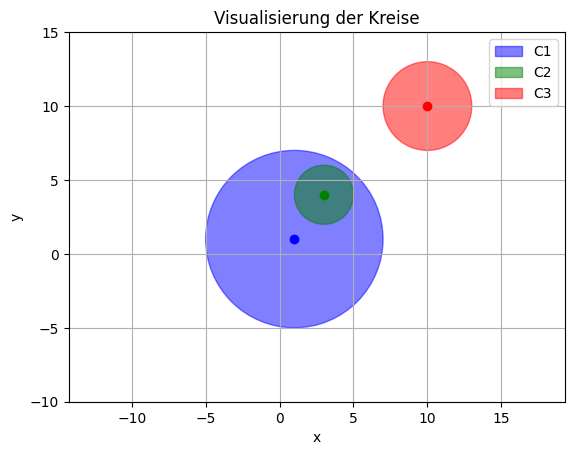

```python
# Visualisierung, siehe Kapitel "Visualisierung mit Matplotlib" zur Erklärung
import matplotlib.pyplot as plt
fig, ax = plt.subplots()
circles = [C1, C2, C3]
colors = ['blue', 'green', 'red']
labels = ['C1', 'C2', 'C3']

for circle, color, label in zip(circles, colors, labels):
    circle_patch = plt.Circle(circle.center, circle.radius, color=color, alpha=0.5, label=label)
    ax.add_patch(circle_patch)
    ax.plot(circle.center[0], circle.center[1], 'o', color=color)  # Mark center

ax.set_xlim(-10, 15)
ax.set_ylim(-10, 15)
ax.set_aspect('equal', adjustable='datalim')
plt.legend()
plt.title("Visualisierung der Kreise")
plt.xlabel("x")
plt.ylabel("y")
plt.grid(True)
plt.show()
```

# KI-unterstütztes Programmieren

Seit etwas 2023 ist künstliche Intelligenz (KI) in der Lage, Programmcode zu generieren. Dies kann sehr hilfreich sein, um Routinearbeiten zu erledigen oder um Inspiration zu bekommen. Allerdings ist die Qualität des generierten Codes sehr unterschiedlich und es ist wichtig, den Code sorgfältig zu überprüfen und zu testen.

**Stand der Dinge zur Zeit (2025):**

- KI kann Code generieren, der in vielen Fällen korrekt und nützlich ist.
- KI kann jedoch auch fehlerhaften oder ineffizienten Code generieren.
- KI versteht den Kontext und die Anforderungen eines Programms nicht immer vollständig.

**Was wird die Zukunft bringen?**

- "Vorhersagen sind immer schwierig, vor allem wenn sie die Zukunft betreffen" (Niels Bohr)
- Es kann sein, dass man als nicht Spezialist in Zukunft nicht mehr programmieren können muss, da KI dies übernehmen wird.
- Es ist jedoch sicher, dass ein Verständnis der Programmierung und der zugrunde liegenden Konzepte weiterhin wichtig sein wird
  - Programmieren ist eine Art zu denken und Probleme zu lösen
  - Um zu verstehen wie KI funktioniert muss man **Programmieren** und vor allem **Mathematik** beherrschen
  - Bsp: Ein Schachspieler kann von einem guten Schachprogramm lernen und das Programm weiterentwickeln obwohl er keine Chance hat gegen das Programm zu gewinnen

**Programmieren in der Mathematik:**

- Wir sind in der glücklichen Lage, dass wir Programmieren als Werkzeug und nicht als Selbstzweck lernen
- Wir werden alle Hilfsmittel und Tools nutzen die uns das Leben leichter machen

## Github Co-Pilot

- Es gibt sehr viele verschieden KI-Tools, die sich auch laufend weiterentwickeln
- Grundsätzlich kann man ein beliebiges Large Language Model (zum Beispiel ChatGPT, Gemini, Grok, ...) verwenden um Code zu generieren
  - Einfach das Problem in natürlicher Sprache beschreiben und den generierten Code überprüfen
  - Die Qualität des Codes ist oft sehr unterschiedlich und hängt stark von der Art der Beschreibung ab
  - Bessere Qualität bekommt man, wenn man sehr genau beschreibt, wie ein Problem gelöst werden soll (hier ist es sehr hilfreich programmieren zu können)
- Praktischer ist es, wenn die KI direkt in die Programmierumgebung integriert.
  - Wir werden in dieser Vorlesung Github Co-Pilot verwenden, das in VSCode integriert ist und für Studierende kostenlost verfügbar ist.
  - Es steht Ihnen aber frei, auch andere Tools zu verwenden.

### Installation von Github Co-Pilot

1. Erstellen Sie einen Github Account https://github.com/education/students (gratis für Studierende)
2. Bewegen Sie die Maus über das Copilot Symbol

[figure not shown]

   rechts unten in VSCode und klicken Sie auf "Set up Copilot"
3. Folgen Sie den Anweisungen und melden Sie sich mit Ihrem Github Account an

### Verwendung von Github Co-Pilot

**Vorschläge annehmen und ablehnen:**

- Copilot macht Vorschläge direkt im Editor, die Sie mit der Tab-Taste übernehmen können.
- Sie können auch Kommentare schreiben, die beschreiben, was der Code tun soll, und Copilot wird versuchen, den entsprechenden Code zu generieren.
- Sie können auch mehrere Vorschläge durch Drücken von `Alt` + `]` (nächster Vorschlag) oder `Alt` + `[` (vorheriger Vorschlag) anzeigen.
- Wenn Sie keinen Vorschlag möchten, können Sie ihn mit der `Esc`-Taste ablehnen.

Im Beispiel unten haben wir nur den Kommentar und die Signatur der Funktion geschrieben, der Rest (in hellerer Schrift) wurde von Copilot generiert und kann nun mit der Tab-Taste übernommen werden.

[figure not shown]

**Copilot anweisen:**

- Sie können Copilot direkt ansprechen (prompten), indem Sie `Strg` + `I` (oder `Cmd` + `I` auf dem Mac) drücken, um eine Eingabeaufforderung zu öffnen.
- Danach können Sie eine Beschreibung dessen eingeben, was Sie möchten, und Copilot wird versuchen, den entsprechenden Code zu generieren.
- Wen der Code fertig generiert ist, können Sie ihn akzeptieren oder ablehnen.

Im Beispiel unten haben wir die Eingabeaufforderung geöffnet und Copilot angewiesen eine Funktion zu schreiben. Wie man sieht kann man Copilot auch instruieren wie die Funktion arbeiten soll. Hier haben wir zusätzlich angegeben, dass die Funktion die Inputs validieren soll.

[figure not shown]

**Mit Copilot chatten oder Code erklären lassen:**

- Sie können Copilot auch verwenden, um Fragen zu stellen oder Code erklären zu lassen.
- Mit `Strg` + `Alt` + `I` oder (`Cmd` + `Alt` + `I` auf dem Mac) können Sie ein Chat-Fenster öffnen, in dem Sie Fragen stellen können.
- Wenn Sie vorher Code markiert haben, wird dieser Code in die Frage einbezogen.

[figure not shown]

- Sie können auch ein Chat-Fenster öffnen, indem Sie auf das Copilot-Symbol

[figure not shown]

  rechts unten in VSCode klicken.

## VS Code: AI Agent Mode

Für aufwändigere Aufgaben gibt es in VS Code den sogenannten 'Agent Mode', der es erlaubt, komplexere Abläufe zu automatisieren. Diese Agents können mehrere Schritte ausführen, wie z.B. Code analysieren, Tests ausführen und Berichte erstellen. Um den Agent Mode zu nutzen folgen Sie diesen Schritten:

- Öffnen Sie das Chat Fenster (Cmd+Alt+I)
- Aktivieren Sie den "Agent Mode"

[figure not shown]

- Wählen Sie einen Agenten aus der Liste

[figure not shown]

- Optional: Fügen Sie Kontext hinzu (z.B. den Code, den Sie analysieren/erweitern möchten)

[figure not shown]

- Geben Sie eine Aufgabe ein, die der Agent ausführen soll (z.B. "Führe alle Tests aus und fasse die Ergebnisse zusammen") und klicken Sie auf

[figure not shown]

## Gefahrenquellen bei der Verwendung von KI

- **Es gibt keine Garantie auf Richtigkeit oder Vollständigkeit der Erklärungen oder des generierten Codes!**
  - KI kann Fehler machen, die schwer zu erkennen sind
  - KI kann veraltete oder falsche Informationen liefern
  - KI kann Code generieren, der nicht den besten Praktiken entspricht
- **Unklarer Datenschutz:**
  - Ihre Eingaben und Anfrage werden an die Server der Anbieter der KI-Modelle geschickt
  - Es ist unklar, wie diese Daten verwendet werden und ob sie gespeichert werden
  - Vermeiden Sie es, sensible oder vertrauliche Informationen einzugeben (vor allem im Beruf)
- Wir erwarten von Ihnen, dass Sie den generierten Code sorgfältig überprüfen und testen und vor allem **verstehen**, was der Code macht.
  - **Da der Abschlusstest schriftlich ist, dürfen Sie Copilot nicht verwenden!!**
- Wenn Sie die Programmierkonzepte nicht verstehen, können Sie niemals etwas entwickeln oder verbessern, dass über die Fähigkeiten der KI hinausgeht
- Wenn Sie vollständige Funktionen oder gar Programme von Copilot generieren lassen ist es viel schwieriger eventuelle Fehler zu finden
  - KI ist sehr gut darin, Fehler zu verstecken
  - Oft passiert in verstecken Fällen genau das falsche
- Besser: Code in kleinen Stücken generieren lassen und sofort checken bzw. testen

## KI und Mathematik

Falls Sie sich für KI interessieren und mehr darüber erfahren wollen ist das Mathematikstudium genau das Richtige für Sie!

- **Neuronale Netzwerke bilden die Grundlage für viele KI-Modelle**
  - Sie verwenden Konzepte aus der linearen Algebra wie Matrix-Vektor-Multiplikation
- **Das Training von KI-Modellen basiert auf Optimierungsmethoden**
  - Diese Methoden werden in der Analysis und Numerik behandelt
  - Mehrdimensionale Differentialrechnung ist dabei besonders wichtig
- **Wahrscheinlichkeitsrechnung und Statistik sind ebenfalls wichtige Grundlagen für das Verständnis von KI**

# Visualisierung mit Matplotlib

Matplotlib ist eine leistungsstarke Python-Bibliothek zur Erstellung von statischen, animierten und interaktiven Visualisierungen. Leider ist die Bedienung manchmal etwas umständlich und unübersichtlich.

- Hier lohnt sich der Einsatz von CoPilot besonders
  - Viele verschiedene Funktionen die schwer zu überblicken sind
  - Fehler fallen sofort auf (die Darstellung ist nicht wie erwartet)

### Matplotlib installieren und importieren

Meistens muss Matplotlib zuerst installiert werden. Dies geschieht mit dem Befehl:

```
pip install matplotlib
```

Das `pyplot`-Submodul ist für die meisten Visualisierungen zuständig. Es wird üblicherweise mit dem Alias `plt` importiert.

```python
import matplotlib.pyplot as plt
```

## Einfaches Plotten: `plt.plot()`

Die einfachste Art ist der Linienplot.

- Die Funktion `plot()` wird für Linienplots verwendet
- `title` gibt dem Plot einen Titel
- `xlabel` und `ylabel` beschriften die Achsen des Plots
- `show()` zeigt auf dem Bildschirm an

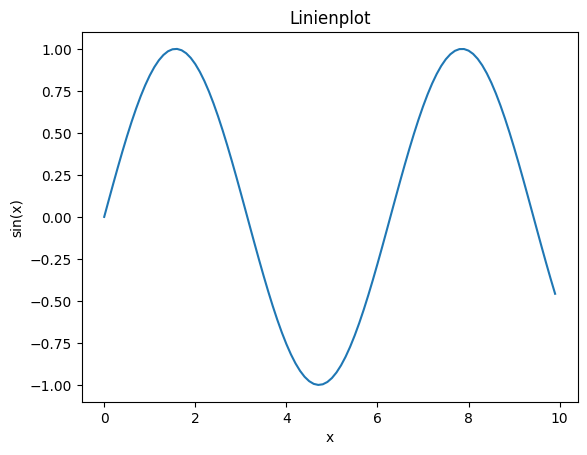

```python
from math import sin, cos
x = [i * 0.1 for i in range(100)]
y = [sin(xi) for xi in x]

plt.plot(x, y)
plt.title('Linienplot')
plt.xlabel('x')
plt.ylabel('sin(x)')
plt.show()
```

Man kann mehrere Linien in einem Plot darstellen, indem man einfach mehrere `plot()`-Aufrufe hintereinander ausführt.

- Um die Linien zu unterscheiden kann man den Befehl `label` verwenden
- Mit `legend()` wird eine entsprechende Legende hinzugefügt
  - Die Position der Legende kann mit dem Parameter `loc` angepasst werden
  - Mögliche Werte sind z.B. 'upper right', 'lower left', 'best', etc.

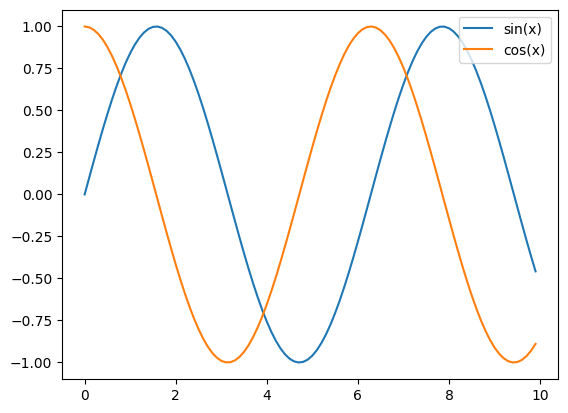

```python
plt.plot(x, y, label='sin(x)')
plt.plot(x, [cos(xi) for xi in x], label='cos(x)')
plt.legend(loc='upper right')
plt.show()
```

### Wachstum visualisieren mit `plt.loglog()` und `plt.semilogy()`

Manchmal ist es sinnvoll, eine logarithmische Skalierung der Achsen zu verwenden, um das Wachstum von Funktionen besser zu visualisieren.

- `loglog()` verwendet eine logarithmische Skalierung für beide Achsen
- `semilogy()` verwendet eine logarithmische Skalierung nur für die y-Achse
- `semilogx()` verwendet eine logarithmische Skalierung nur für die x-Achse

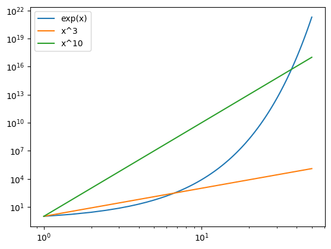

```python
x = np.linspace(1,50,100)
plt.loglog(x, np.exp(x-1), label='exp(x)')
plt.loglog(x, x**3, label='x^3')
plt.loglog(x, x**10, label='x^10')
plt.legend()
plt.show()
```

### Flächen füllen mit `plt.fill()`

Wenn man eine Fläche mit Farbe füllen möchte, kann man die Funktion `fill()` verwenden.

- `fill(x, y)` füllt die Fläche, die durch die Punkte `(x[i], y[i])` definiert ist
- `color` definiert die Farbe der Fläche
- `alpha` definiert die Transparenz der Fläche (0 = transparent, 1 = undurchsichtig)

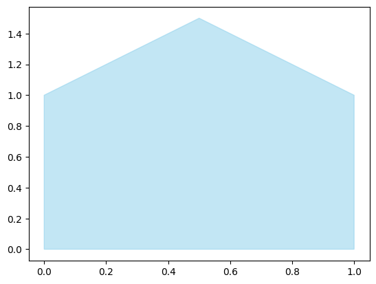

```python
import matplotlib.pyplot as plt
plt.fill([0,1,1,0.5,0], [0,0,1,1.5,1], color='skyblue', alpha=0.5)
plt.show()
```

## Streudiagramme: `plt.scatter()`

Um die Beziehung zwischen zwei Variablen zu visualisieren, sind Streudiagramme nützlich.

- Die Funktion `scatter()` wird für Streudiagramme verwendet
- `c` kann verwendet werden, um die Farbe der Punkte basierend auf einer dritten Variable zu ändern
- `s` steuert die Größe der Punkte
- `colorbar()` fügt eine Farbskala hinzu

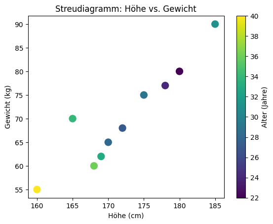

```python
# Daten für 10 Personen: Höhe (cm), Gewicht (kg), Alter (Jahre), Ge
people_data = [
    [170, 65, 28],
    [165, 70, 34],
    [180, 80, 22],
    [175, 75, 29],
    [160, 55, 40],
    [185, 90, 31],
    [172, 68, 27],
    [168, 60, 36],
    [178, 77, 24],
    [169, 62, 33]
]

plt.scatter([person[0] for person in people_data], [person[1] for person in people_data], c=[person[2] for person in people_data], s=100)
plt.colorbar(label='Alter (Jahre)')
plt.title('Streudiagramm: Höhe vs. Gewicht')
plt.xlabel('Höhe (cm)')
plt.ylabel('Gewicht (kg)')
plt.show()
```

## Balkendiagramme: `plt.bar()`

Balkendiagramme sind nützlich, um kategorische Daten zu visualisieren.

- Die Funktion `bar()` wird für Balkendiagramme verwendet

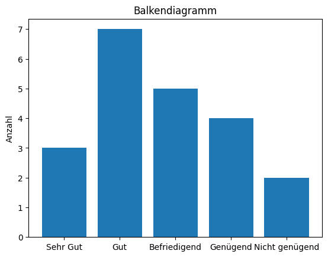

```python
categories = ['Sehr Gut', 'Gut', 'Befriedigend', 'Genügend', 'Nicht genügend']
values = [3, 7, 5, 4, 2]
plt.bar(categories, values)
plt.title('Balkendiagramm')
plt.ylabel('Anzahl')
plt.show()
```

## Histogramme: `plt.hist()`

Um die Anzahl von Datenpunkten in verschiedenen Bereichen zu visualisieren, sind Histogramme nützlich.

- Die Funktion `hist()` wird für Histogramme verwendet
- `bins` steuert die Anzahl der Balken im Histogramm
- `bins` kann auch eine Liste von Zahlen sein, die die Grenzen der Balken definieren

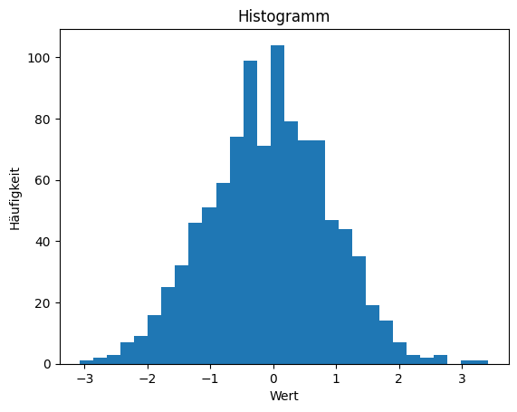

```python
import random as rnd
data = [rnd.gauss(0, 1) for _ in range(1000)]
plt.hist(data, bins=30)
plt.title('Histogramm')
plt.xlabel('Wert')
plt.ylabel('Häufigkeit')
plt.show()
```

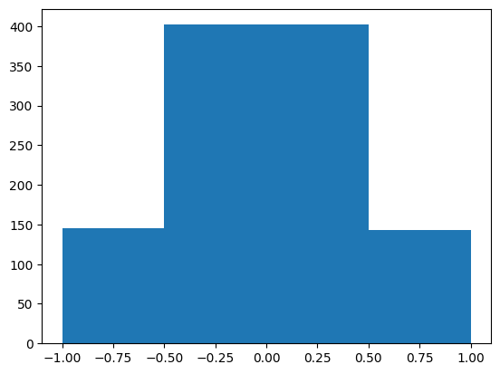

```python
plt.hist(data, bins=[-1,-0.5,0.5,1])
plt.show()
```

### Mehrere Plots in einem Bild `plt.subplot()` und `plt.subplots()`

Die Funktion `subplots()` erstellt eine Figur und ein Gitter von Subplots.

- Die ersten beiden Parameter `nrows` und `ncols` geben die Anzahl der Zeilen und Spalten an
- `figsize` steuert die Größe der gesamten Figur (in Inches)
- `subplot()` wird verwendet, um einen bestimmten Subplot zu aktivieren
  - `nrows`, `ncols` und `index` geben die Position des Subplots an
    - man kann stattdess auch einen Parameter wie `121` verwenden, der für 1 Zeile, 2 Spalten und den ersten Subplot steht
  - `nrows` und `ncols` muss mit den Werten in `subplots()` übereinstimmen
  - `index` ist die laufende Nummer des Subplots (von links nach rechts, oben nach unten)

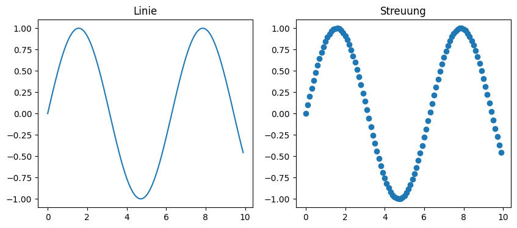

```python
plt.subplots(1, 2, figsize=(10, 4))
# Plot 1: Linienplot
plt.subplot(1, 2, 1)
plt.plot(x, y)
plt.title('Linie')
# Plot 2: Streudiagramm
plt.subplot(1, 2, 2)
plt.scatter(x, y)
plt.title('Streuung')
plt.show()
```

### Geometrische Figuren plotten

Matplotlib bietet auch Funktionen zum Zeichnen von geometrischen Figuren wie Kreisen, Rechtecken und Polygonen.

- `Circle`, `Rectangle` und `Polygon` sind Klassen, die geometrische Figuren repräsentieren
  - `alpha` steuert die Transparenz der Figur (0 = unsichtbar, 1 = undurchsichtig)
- Diese Figuren können zu einem Plot hinzugefügt werden, indem man sie als Patch-Objekte hinzufügt.
- `add_patch()` fügt die Figur dem aktuellen Plot hinzu

Die Methode `add_patch()` ist eine Methode des `Axes`-Objekts. Man muss daher zuerst ein `Axes`-Objekt erstellen, z.B. mit `fig, ax = plt.subplots()`, und dann `ax.add_patch(...)` verwenden.

- Der Befehl `set_aspect('equal')` sorgt dafür, dass die Achsen gleich skaliert werden, sodass Kreise auch als Kreise dargestellt werden und nicht als Ellipsen.

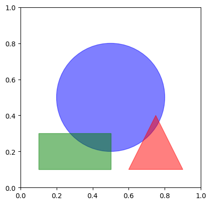

```python
circle = plt.Circle((0.5, 0.5), 0.3, color='blue', alpha=0.5)
rectangle = plt.Rectangle((0.1, 0.1), 0.4, 0.2, color='green', alpha=0.5)
polygon = plt.Polygon([[0.6, 0.1], [0.9, 0.1], [0.75, 0.4]], color='red', alpha=0.5)
fig, ax = plt.subplots()
ax.add_patch(circle)
ax.add_patch(rectangle)
ax.add_patch(polygon)
ax.set_aspect('equal')
plt.show()
```

## Speichern von Abbildungen: `plt.savefig()`

Anstatt ein Bild am Bildschirm anzuzeigen, kann es auch in einer Datei gespeichert werden. Dazu wird die Funktion `plt.savefig()` verwendet. Man kann ein Bild speichern und zusätzlich auf dem Bildschirm anzeigen.

- Der erste Parameter ist der Dateiname (inkl. Pfad)
- Das Dateiformat wird durch die Dateiendung bestimmt (z.B. `.png`, `.jpg`, `.pdf`, etc.)
- `dpi` steuert die Auflösung des Bildes
- `bbox_inches='tight'` sorgt dafür, dass keine unnötigen weißen Ränder gespeichert werden
- `transparent=True` speichert das Bild mit transparentem Hintergrund (nur bei Formaten die Transparenz unterstützen, z.B. `.png`)

```
plt.savefig('plot.png', dpi=300, bbox_inches='tight', transparent=True)
```

### Gestaltung von Plots

Matplotlib bietet viele Möglichkeiten, Plots anzupassen. Einfache Optionen sind z.B.: Farben, Marker, oder Linienstile

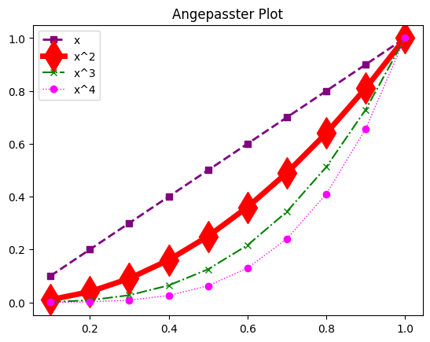

```python
x = [0.1*i for i in range(1, 11)]
plt.plot(x, x, linestyle='--', marker='s', color='purple', linewidth=2, label='x')
plt.plot(x, [i**2 for i in x], linestyle='-', marker='d', color='red', linewidth=5, markersize = 20, label='x^2')
plt.plot(x, [i**3 for i in x], linestyle='-.', marker='x', color='green', label='x^3')
plt.plot(x, [i**4 for i in x], linestyle=':', marker='o', color='magenta',linewidth=1, label='x^4')
plt.legend()
plt.title('Angepasster Plot')
plt.show()
```

Für stilistische Anpassungen ist Copilot besonders hilfreich. Man kann mit einem einfachen Plot starten, z.b.

```
plt.plot(x, x)
plt.plot(x, x**0.5)
plt.plot(x, x**2)
```

und dann mit einem Prompt der folgenden Art optimieren: "Use different shades of blue for the three lines and use different line styles (solid, dashed, dotted). Add a legend to the plot."

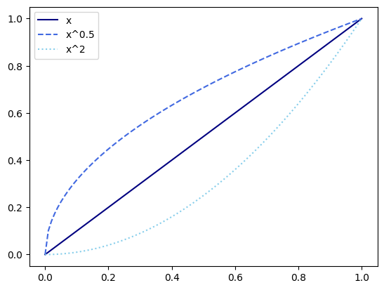

```python
x = [0.01*i for i in range(0, 101)]
plt.plot(x, x, color='navy', linestyle='-', label='x')
plt.plot(x, [i**0.5 for i in x], color='royalblue', linestyle='--', label='x^0.5')
plt.plot(x, [i**2 for i in x], color='skyblue', linestyle=':', label='x^2')
plt.legend()
plt.show()
```

## Animationen mit Matplotlib

Matplotlib unterstützt auch Animationen. Die einfache Methode ist die Verwendung von `plt.pause()` und `plt.clear()` in einer Schleife, um den Plot zu aktualisieren.

- `plt.clear()` löscht den aktuellen Plot
- `plt.pause(seconds)` pausiert die Ausführung für eine bestimmte Anzahl von Sekunden und aktualisiert den Plot
- Diese Methode ist nicht sehr effizient und daher nur für einfache Animationen geeignet

**Achtung:** In Jupyter Notebooks funktioniert `plt.pause()` nicht immer zuverlässig. Es ist besser, Animationen in einem normalen Python-Skript auszuführen.

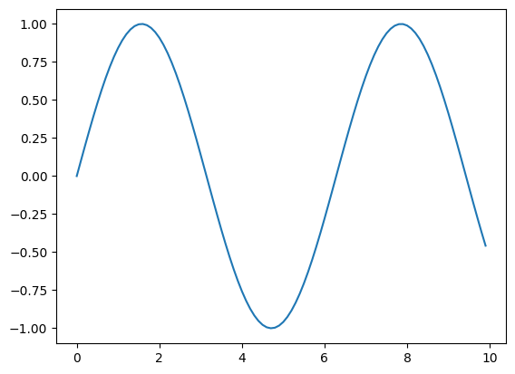

```python
from math import sin
fig, ax = plt.subplots(1,1)
x = [0.1*i for i in range(100)]
for i in range(100):
    ax.clear()
    ax.plot(x, [sin(j + i/10) for j in x])
    plt.pause(0.1)
```

### Animation mit FuncAnimation

Eine effizientere Methode zur Erstellung von Animationen in Matplotlib ist die Verwendung der Klasse `FuncAnimation` aus dem Modul `matplotlib.animation`. Diese Methode ist besonders nützlich für komplexere Animationen, da sie den Plot nur bei Bedarf aktualisiert und so die Leistung verbessert.

- `FuncAnimation` benötigt eine Figur, eine Animationsfunktion und einen Intervall in Millisekunden
- Die Animationsfunktion `animate` wird für jeden Frame aufgerufen und erhält die aktuelle Bild-Nummer
  - Die Funktion verwendet das `line`-Objekt welches von `plot()` zurückgegeben wird, um die Daten zu aktualisieren
  - 'ax.plot()' gibt eine List von Linenobjekten zurück, auch wenn nur eine Linie gezeichnet wird. Daher wird das erste Element der Liste mit `[0]` ausgewählt.
- `save_count` gibt an, wie viele Frames zwischengespreichert werden sollen

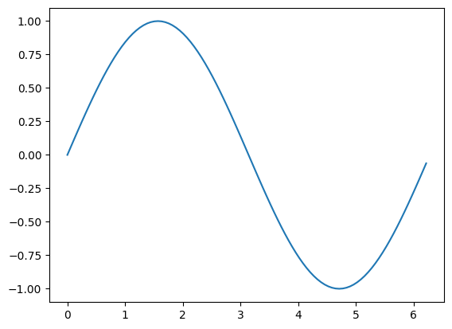

```python
from math import sin, pi
import matplotlib.animation as animation

fig, ax = plt.subplots()

x = [ 2*pi*i/100 for i in range(100)]
line = ax.plot(x, [sin(i) for i in x])[0]

def animate(i):
    line.set_ydata([sin(j + i / 50) for j in x])  # update the data.
    return line,


ani = animation.FuncAnimation(
    fig, animate, interval=20, save_count=50)
plt.show()
```

### Weitere Informationen zu Matplotlib

Eine gute Resource ist die offizielle Matplotlib-Galerie https://matplotlib.org/stable/gallery/index.html

- Hier findet man viele Beispiele und Anleitungen für verschiedene Plot-Typen.
- Man sucht ein Beispiel welches dem gewünschten Plot ähnelt und passt es an.

### 3D Plots -> später

Im Kapitel 'Numerische Mathematik mit NumPy' werden wir auch noch Beispiele zu 3D Plots sehen.

# Daten speichern und laden

Oft ist es nützlich, Daten am Computer zu speichern um sie auch nach Programmende weiterverwenden zu können.

Um eine Datei zu öffnen, benutzt man den Befehl `open(path, mode)`

- `path`: der Pfad zur Datei
  - relativ zum aktuellen Verzeichnis (z.B. 'data/example.txt'),
  - oder absolut (z.B. '/Users/michael/Repositories/EPROG_2025/data/example.txt')
- `mode`: der Modus, in dem die Datei geöffnet wird:
  - `'r'`: Lesen (read) - Standardmodus, wenn nicht angegeben
  - `'w'`: Schreiben (write) - überschreibt die Datei wenn sie existiert, oder erstellt eine neue Datei
  - `'a'`: Anhängen (append) - fügt Daten ans Ende der Datei wenn sie existiert, oder erstellt eine neue Datei
- `'b'`: Binärmodus (binary) - für nicht-text Dateien (z.B. Bilder, PDFs)
- `'t'`: Textmodus (text) - Standardmodus, wenn nicht angegeben

## Textdateien speichern & lesen

Der Rückgabewert von `open` ist ein Dateiobjekt, das Methoden zum Lesen und Schreiben von Daten bereitstellt.

Die Dateiendung (z.B. `.txt`) ist nicht entscheidend, aber hilfreich um den Dateityp zu erkennen.

```python
f = open('data/example.txt', 'w')
f.write('Hello, World!\n')
f.close()
f = open('data/example.txt', 'r')
content = f.read()
f.close()
print(content)
```

```
Hello, World!
```

## `with` Statement

Das `with` Statement ist eine elegante Möglichkeit, Dateien zu öffnen und sicherzustellen, dass sie korrekt geschlossen werden, auch wenn ein Fehler auftritt.

```
with open(path, mode) as f:
    # Dateioperationen mit f
    ...
# Datei wird automatisch geschlossen, wenn der Block verlassen wird
```

```python
with open('data/example.txt', 'w') as f:
    f.write('Hello, World!\n')
    f.write('This is a text file.\n')

with open('data/example.txt', 'r') as f:
    content = f.read()
    print(content)

with open('data/example.txt', 'a') as f:
    f.write('Appending a new line')

with open('data/example.txt', 'r') as f:
    content = f.read()
    print(content)
```

[output not shown]

Nach den beiden Schreibvorgängen oben sieht die Datei `data/example.txt` so aus:

[figure not shown]

### Beispiel: Zeilennummern in eine Datei hinzufügen

[figure not shown]

Wir wollen jede Zeile mit einer Zeilennummer versehen und das Ergebnis in eine neue Datei `data/numbered_poem.txt` schreiben.

- das `with` Statement kann mehrere Dateien gleichzeitig öffnen (getrennt durch Kommas)

```python
with open('data/poem.txt', 'r') as infile, open('data/numbered_poem.txt', 'w') as outfile:
    line_list = infile.readlines()
    for i, line in enumerate(line_list):
        outfile.write(f"{i+1}: {line}")
```

Das ergebnis in `data/numbered_poem.txt` sieht dann so aus:

[figure not shown]

### Direkt durch das Dateiobjekt iterieren

Das Dateiobjekt ist selbst iterierbar, d.h., man kann direkt eine Schleife darüber laufen lassen, ohne vorher `readlines()` aufzurufen:

```python
with open('data/poem.txt', 'r') as infile:
    for line in infile:
        print(line.strip())  # .strip() entfernt führende und nachfolgende Leerzeichen und Zeilenumbrüche
```

```
Das eilende Schiff, es kommt durch die Wogen
Wie Sturmwind geflogen.
Voll Jubel ertönt’s vom Mast und vom Kiele:
"Wir nahen dem Ziele."
Der Fährmann am Steuer spricht traurig und leise:
"Wir segeln im Kreise."
```

Damit kann man den obigen Code eleganter schreiben:

```python
with open('data/poem.txt', 'r') as infile, open('data/numbered_poem.txt', 'w') as outfile:
    for i, line in enumerate(infile):
        outfile.write(f"{i+1}: {line}")
```

## CSV Dateien verarbeiten

CSV (Comma-Separated Values) Dateien sind ein gängiges Format zum Speichern tabellarischer Daten. Python bietet das eingebaute `csv` Modul, um CSV Dateien einfach zu lesen und zu schreiben.

```
import csv
```

Das `csv` Modul stellt zwei Hauptklassen bereit:

- `csv.reader`: zum Lesen von CSV Dateien
- `csv.writer`: zum Schreiben von CSV Dateien

```python
import csv
headings = ['Name', 'Age', 'City']
rows = [
    ['Alice', 30, 'New York'],
    ['Bob', 25, 'Los Angeles'],
    ['Charlie', 35, 'Chicago']
]
with open('data/people.csv', 'w', newline='') as csvfile:
    writer = csv.writer(csvfile)
    writer.writerow(headings)
    writer.writerows(rows)
```

Die erstellte CSV Datei `data/people.csv` ist eine einfache Textdatei in der die Daten durch Kommas getrennt sind. Wenn man sie mit einem Tabellenkalkulationsprogramm (z.B. Excel) öffnet, wird sie als Tabelle dargestellt:

[figure not shown]

Um die Datei wieder einzulesen, verwenden wir `csv.reader`:

```python
with open('data/people.csv', 'r') as csvfile:
    reader = csv.reader(csvfile)
    for row in reader:
        print(row)
```

```
['Name', 'Age', 'City']
['Alice', '30', 'New York']
['Bob', '25', 'Los Angeles']
['Charlie', '35', 'Chicago']
```

Für die Weiterverarbeitung ist es oft praktischer, die Daten als Wörterbuch zu lesen, wobei die Spaltenüberschriften als Schlüssel verwendet werden. Dafür gibt es `csv.DictReader`:

```python
with open('data/people.csv', 'r') as csvfile:
    reader = csv.DictReader(csvfile)
    for row in reader:
        for key, value in row.items():
            print(f"{key}: {value}", end=", ")
        print("")
```

```
Name: Alice, Age: 30, City: New York,
Name: Bob, Age: 25, City: Los Angeles,
Name: Charlie, Age: 35, City: Chicago,
```

## JSON Dateien verarbeiten

JSON (JavaScript Object Notation) ist ein weit verbreitetes Format zum Austausch von Daten. Python bietet das eingebaute `json` Modul, um JSON Daten einfach zu lesen und zu schreiben. Eine JSON Datei ist eine Textdatei, die Daten in einer strukturierten, hierarchischen Form speichert.

JSON unterstützt Dictionaries (Objekte), Listen (Arrays), Strings, Zahlen, Booleans und `null` (None in Python).

Die Funktion `json.dump(data, file)` schreibt Python Datenstrukturen in eine JSON Datei, während `json.load(file)` JSON Daten aus einer Datei in Python Datenstrukturen lädt.

- Beim Schreiben von JSON Dateine kann man mit dem Parameter `indent` die Einrückung für eine bessere Lesbarkeit angeben.

```python
import json

data = {
    "name": "Alice",
    "age": 30,
    "is_student": False,
    "scores": [95, 88, 76],
    "address": {"city": "New York", "zip": "10001"},
    "height": 1.68,
    "hobbies": None
}

my_list = [1, 2, 3, 4, 5]

with open('data/dict.json', 'w') as f1, open('data/list.json', 'w') as f2:
    json.dump(data, f1, indent=4)
    json.dump(my_list, f2)

with open('data/dict.json', 'r') as f1, open('data/list.json', 'r') as f2:
    loaded_dict = json.load(f1)
    loaded_list = json.load(f2)

print(loaded_dict['age'])
print(loaded_list)
```

```
30
[1, 2, 3, 4, 5]
```

Die JSON Datei `data/dict.json` sieht wie folgt aus:

[figure not shown]

## Beispiel: Markov Ketten

Eine Markov Kette ist ein mathematisches Modell um zufällige Prozesse zu beschreiben

- Der nächste Zustand hängt nur vom aktuellen Zustand ab (nicht von der Vorgeschichte)
- Der nächste Zustand wird durch den Zufall bestimmt
- Die Wahrscheinlichkeit von einem Zustand zum nächsten zu wechseln is vorgegeben

[figure not shown]

```python
from random import random
transition_matrix = [[0.5, 0.5], [0.8, 0.2]]
current_state = 0
num_steps = 10
for _ in range(num_steps):
    s = 'A' if current_state == 0 else 'B'
    print(s, end=' ')
    current_state = 0 if random() < transition_matrix[current_state][0] else 1
```

```
A B B A B A B A B A
```

### Textgenerierung mit Markov-Ketten

Ein interessanteres Beispiel ist die Generierung von Text basierend auf einem gegebenen Textkorpus (z.B. "Alice im Wunderland").

- Aufgrund von zwei aufeinanderfolgenden Wörtern wird das nächste Wort ausgewählt
- Zuerst lesen wir den Text ein und speichern von allen aufeinanderfolgenden Wortpaaren die möglichen Folgewörter in einem `dict` ab
- Dann generieren wir neuen Text, indem wir mit einem zufälligen Wortpaar starten und immer wieder ein neues Wort basierend auf dem aktuellen Wortpaar auswählen

Im folgenden Code verwenden wir zwei neue Befehle

- `.isupper()`: überprüft, ob ein String nur aus Großbuchstaben besteht
- `textwrap.fill(text)`: formatiert einen langen String in mehrere Zeilen mit einer maximalen Breite (Standard 70 Zeichen)

Der Beispieltext "Alice im Wunderland" ist frei im Netz verfügbar (Project Gutenberg) und liegt in der Datei `data/alice.txt` vor.

[figure not shown]

```python
from random import choice
import textwrap

# Class for generating text based on a Markov chain
class TextGenerator:
    def __init__(self, filename):
        self.possible_words = dict()
        w1 = ''
        w2 = ''
        # Build the dictionary of possible word transitions from the text file
        # (word1, word2) -> [list of possible next words]
        with open(filename, 'r') as f:
            for line in f:
                for word in line.split():
                    key = (w1, w2)
                    if key not in self.possible_words:
                        self.possible_words[key] = [word]
                    else:
                        self.possible_words[key].append(word)
                    w1, w2 = w2, word

    # Generate text of a given word count
    def generate_text(self, word_count=50):
        # Start with a random word pair where the first word has at least one letter and starts with a capital letter
        w1, w2 = choice([k for k in self.possible_words if len(k[0])>= 1 and k[0][0].isupper()])
        text = ""
        for _ in range(word_count):
            text += w1 + " "
            next_word = choice(self.possible_words[(w1, w2)]) # Randomly choose the next word based on the current pair
            w1, w2 = w2, next_word  # word2 becomes word1, next_word becomes word2
        return textwrap.fill(text)  # Format the text to fit within 70 characters per line (readability)

virtual_lewis_carroll = TextGenerator('data/alice.txt')
print(virtual_lewis_carroll.generate_text(100))
```

```
Dormouse, without considering at all a pity. I said ‘What for?’” “She
boxed the Queen’s voice in the world go round!’” “Somebody said,”
Alice whispered, “that it’s done by everybody minding their own
business,” the Duchess said after a fashion, and this he handed over
to herself, “Which way? Which way?”, holding her hand in hand with
Dinah, and saying ‘Come up again, dear!’ I shall see it quite plainly
through the air! Do you think you’re changed, do you?” “I’m afraid
I’ve offended it again!” For the Mouse was speaking, so that by the
officers of the teacups as
```

Der generierte Text sieht auf den ersten Blick nach üblichem Englisch aus, enthält aber viele sinnlose und unzusammenhängende Formulierungen.

- Die Markov Kette kann nur lokale Abhängigkeiten erfassen, was zu unzusammenhängenden Sätzen führt
- Für bessere Ergebnisse sind komplexere Modelle (z.B. neuronale Netze) erforderlich
- Large Language Models (LLMs) wie ChatGPT nutzen fortgeschrittene, aber im Grunde ähnliche, Prinzipien um Antworten zu generieren
  - Aus dem bereits generierten Text wird das wahrscheinlichste nächste Wort ausgewählt

Man kann auch das EIMA Skriptum laden (wenn man es vorher in reinen Text umgewandelt hat) und damit neue mathematisch klingende Texte generieren:

```python
virtual_eima = TextGenerator('data/eima.txt')
print(textwrap.fill(virtual_eima.generate_text(100)))
```

```
Auch dies geht mit vollständiger Induktion. Korollar 4.6. Sei n0 ∈ N.
Ferner sei A(n) eine Aussage in Abhängigkeit einer natürlichen Zahl
n∈N. (i) Die All-Quantor-Aussage ist dies abschließend äquivalent zu
13. Oktober 2025 29Der folgende Satz ist natürlich nicht äquivalent
zu[(A⇔B) ∧(B ⇔C)] (was aber natürlich erfüllt, denn es gelten die
Implikationen[(A(1) ∧···∧ A(n)) ⇒A(n)] und nach Voraussetzung[A(n)
⇒A(n+ 1)]. Tatsächlich ist für Mengen B ∈Y deﬁniert. Die Inverse
f−1(y) agiert auf Elementen y ∈Y und ist nur die Paare(3,1), (2,2) und
(1,3) mit 1 + 1 = (n+1 0 ) . Also giltx∈Aoder x∈Bi für allei∈I.
Insbesondere giltx∈A∪Bi
```

Mit `matplotlib` kann man sehr einfach eine Heatmap der Übergangswahrscheinlichkeiten erstellen:

- Für jedes Wortpaar $(w_1,w_2)$ wählen wir ein mögliches nächstes Wortpaar $(w_2,w_3)$ aus
- Bassierend auf der Position der Paare in `possible_words.keys()` ordnen wir den Wortpaaren eine Nummer zu und zeichnen den entsprechenden Punkt in der Heatmap
- Die Dichte der Punkte zeigt die Übergangswahrscheinlichkeiten zwischen den Wortpaaren
- Die dicke Line in der Diagonale entsteht, da jedes Wortpaar mit Nummer $i$ automatisch das nächste Wortpaar mit Nummer $i+1$ als möglichen Nachfolger hat
  - Die Line liegt also nicht exakt auf der Diagonalen, sondern leicht darüber

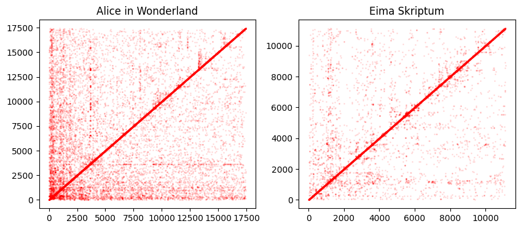

```python
import matplotlib.pyplot as plt
def plot_heatmap(text_obj):
    keys = list(text_obj.possible_words.keys())
    N = len(keys)
    for i, key in enumerate(keys):
        next_words = text_obj.possible_words[key]
        for next_word in next_words:
            next_key = (key[1], next_word)
            try:
                k = keys.index(next_key)
                plt.plot(i,k, 'r.', alpha=0.1, markersize=2)
            except:
                continue
plt.subplots(1, 2, figsize=(10, 4))
plt.subplot(1, 2, 1)
plt.title('Alice in Wonderland')
plot_heatmap(virtual_lewis_carroll)
plt.subplot(1, 2, 2)
plt.title('Eima Skriptum')
plot_heatmap(virtual_eima)
plt.show()
```

# Aufwand von Algorithmen

## Aufwand eines Algorithmus

- wichtige Kenngröße für Algorithmen
  - um Algorithmen zu bewerten / vergleichen
- **Aufwand = Anzahl benötigter Operationen**
  - Zuweisungen
  - Vergleiche
  - arithmetische Operationen
- programmspezifische Operationen nicht gezählt
  - Deklarationen & Initialisierungen
  - Schleifen, Verzweigungen etc.
  - Zählvariablen in Schleifen
- Aufwand wird durch "`einfaches"' Zählen ermittelt
- **Konventionen zum Zählen nicht einheitlich**
- in EPROG ist Aufwand für **worst case** interessant
  - d.h. maximaler Aufwand im schlechtesten Fall
- häufig ist auch "mittlerer Aufwand" interessant (d.h. Erwartungswert des Aufwands)
  - mathematisch komplizierter
  - deshalb nicht in EPROG
- in EPROG (maximal) benötigte Formeln: $$ \sum_{j=1}^n 1 = n, \quad\quad \sum_{j=1}^n j = \frac{n(n+1)}{2}, \quad\quad \sum_{j=1}^n j^2 = \frac{n(n+1)(2n+1)}{6} $$

## Beispiel: Maximum suchen

- Beim Zählen wird jede Schleife zu einer Summe!
  - d.h. `for` in Zeile 3 ist $\sum_{i=1}^{n-1}$
  - $n$ = Länge des Arrays
- Aufwand:
  - 1 Zuweisung in Zeile 2
  - In jedem Schritt der `for`-Schleife $\rightsquigarrow$ Zeile 3-6
    - 1 Zuweisung in Zeile 4
    - 1 Vergleich in Zeile 5
    - ggf. 1 Zuweisung in Zeile 6 (im worst case immer)
- insgesamt Operationen $$ 1 + \sum_{i=1}^{n-1} 3 = 1+3(n-1)=3n-2$$
- wobei Zählvariable nicht in Aufwand eingeht, d.h. nur Statement der `for`-Schleife wird berücksichtigt

```python
def mymax(arr):
    max_val = arr[0]
    for i in range(1, len(arr)):
        val = arr[i]
        if val > max_val:
            max_val = val
    return max_val
```

## Suchen im Vektor

- Aufgabe:
  - Suche Index $j$ mit `vector[j] = value`
  - Rückgabe $-1$, falls solcher nicht existiert
- in jedem Schritt der $j$-Schleife
  - $1$ Vergleich
- Insgesamt Operationen $$ \sum_{j=0}^{n-1} 1 = n $$
- Aufwand $\mathcal{O}(n)$ im worst case

```python
def search(vector, target):
    for i in range(len(vector)):
        if vector[i] == target:
            return i
    return -1
```

## Binäre Suche im sortierten Vektor

- **Voraussetzung: Vektor ist aufsteigend sortiert**
- Modifiziere Idee des Bisektionsverfahrens
  - d.h. natürliche Suche im Telefonbuch
  - Betrachte halben Vektor, falls $ vector[j]\neq value$
- **Frage:** Wieviele Iterationen hat der Algorithmus?
  - jeder Schritt halbiert Vektor
  - Falls $n$ Zweierpotenz, gilt $n/2^k = 1$
  - dann maximal $1 + \log_2 n$ Schritte
  - in jedem Schritt: 2 Vergl. + 2 Zuw. + 1 Division + 3 Add./Subtr.
- Aufwand $\mathcal{O}(\log_2n)$, d.h. logarithmischer Aufwand
  - sog. sublinearer Aufwand $\mathcal{O}(\log_2n) \ll \mathcal{O}(n)$

```python
def binsearch(vector, target):
    low = 0
    high = len(vector) - 1
    while low <= high:
        mid = (low + high) // 2
        if vector[mid] == target:
            return mid
        elif vector[mid] < target:
            low = mid + 1
        else:
            high = mid - 1
    return -1
```

## Minsort

- In jedem Schritt der $i$-Schleife
  - $1$ Zuweisung
  - $j$-Schleife von $i+1$ bis $n-1$
    - $1$ Vergleich
    - ggf. $1$ Zuweisung (worst case!)
    - Vertauschung: 3 Zuweisungen (Dreieckstausch)
- quadratischer Aufwand $\mathcal{O}(n^2)$, weil: $$ \sum_{i=0}^{n-1} \Big(1 + \sum_{j=i+1}^{n-1}5\Big) = n-1+\sum_{i=0}^{n-1}5\big(n-(i+1)\big) = n-1+5\sum_{i=1}^{n}i = n-1+5\,\frac{n(n-1)}2 $$

```python
def minsort(vector):
    for i in range(len(vector)):
        # Find the minimum element in the unsorted portion of the array
        min_idx = i
        for j in range(i+1, len(vector)):
            if vector[j] < vector[min_idx]:
                min_idx = j
        # Swap the found minimum element with the first element of the unsorted portion
        vector[i], vector[min_idx] = vector[min_idx], vector[i]
```

## Aufwand & Rechenzeit

- Jede Operation kostet Rechenzeit
  - d.h. Aufwand korrespondiert zu Rechenzeit
- **Frage:** Welche Rechenzeit kann ich erwarten?
  - Antwort kann nur eine relative Größe sein, da Rechner unterschiedlich schnell
- theoretische Voraussagen
  - **linearer Aufwand**
    - Problemgröße $n$ $\rightarrow$ $Cn$ Operationen
    - Problemgröße $kn$ $\rightarrow$ $Ckn$ Operationen
    - d.h. $3\times$ Problemgröße $\rightarrow$ $3\times$ Rechenzeit
  - **quadratischer Aufwand**
    - Problemgröße $n$ $\rightarrow$ $Cn^2$ Operationen
    - Problemgröße $kn$ $\rightarrow$ $Ck^2n^2$ Operationen
    - d.h. $3\times$ Problemgröße $\rightarrow$ $9\times$ Rechenzeit
  - etc.
- BSP. Code braucht $1$ Sekunde für $n=1000$
  - Aufwand $\mathcal{O}(n)$ $\rightarrow$ $10$ Sekunden für $n=10000$
  - Aufwand $\mathcal{O}(n^2)$ $\rightarrow$ $100$ Sekunden für $n=10000$
  - Aufwand $\mathcal{O}(n^3)$ $\rightarrow$ $1000$ Sek. für $n=10000$

## Zeitmessung

- Wozu Zeitmessung?
  - Vergleich von Algorithmen / Implementierungen
  - Überprüfen theoretischer Voraussagen
- Modul `time`
  - `time.time()` liefert aktuelle Zeit in Sekunden seit 1.1.1970
  - `start = time.time()` vor Code
  - `end = time.time()` nach Code

### Beispiel: Zeitmessung

- Um Aufwand zu vergleichen macht es Sinn die Zeit für große $n$ zu messen
- Zum Beispiel $n=2^k$ für $k=1,2,\ldots$

```python
import time
N = 14

for n in range(N):
  m = 2**n
  sorted_vec = list(range(m))
  unsorted_vec = sorted_vec[::-1]

  # Measure time for search
  start = time.time()
  search(sorted_vec, m-2)
  end = time.time()
  time_search = end - start
  # Measure time for binsearch
  start = time.time()
  binsearch(sorted_vec, m-2)
  end = time.time()
  time_binsearch = end - start
  # Measure time for minsort
  start = time.time()
  minsort(unsorted_vec)
  end = time.time()
  time_minsort = end - start

  print(f"n={m:8d} search={time_search:.6f}s binsearch={time_binsearch:.6f}s minsort={time_minsort:.6f}s")
```

```
n=       1 search=0.000002s binsearch=0.000001s minsort=0.000002s
n=       2 search=0.000001s binsearch=0.000001s minsort=0.000002s
n=       4 search=0.000001s binsearch=0.000001s minsort=0.000003s
n=       8 search=0.000001s binsearch=0.000001s minsort=0.000005s
n=      16 search=0.000001s binsearch=0.000001s minsort=0.000013s
n=      32 search=0.000002s binsearch=0.000001s minsort=0.000039s
n=      64 search=0.000003s binsearch=0.000001s minsort=0.000134s
n=     128 search=0.000006s binsearch=0.000002s minsort=0.000489s
n=     256 search=0.000010s binsearch=0.000002s minsort=0.002564s
n=     512 search=0.000034s binsearch=0.000004s minsort=0.011145s
n=    1024 search=0.000072s binsearch=0.000005s minsort=0.028726s
n=    2048 search=0.000084s binsearch=0.000004s minsort=0.071846s
n=    4096 search=0.000102s binsearch=0.000003s minsort=0.293442s
n=    8192 search=0.000213s binsearch=0.000003s minsort=1.167085s
```

**quadratischer Aufwand** ist deutlich teurer als **linearer Aufwand**

### Beispiel: Aufwand plotten

Um den Aufwand von Algorithmen zu visualisieren eigenen sich logarithmische Plots besonders gut.

- der Exponent des Aufwands (linear =1, quadratisch=2, kubisch=3) ist als Steigung der Linie erkennbar

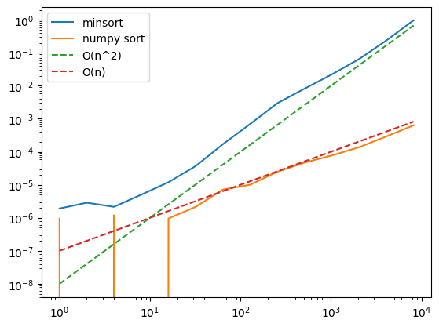

```python
import time
import random as rnd
import matplotlib.pyplot as plt

def minsort(arr):
    n = len(arr)
    for i in range(n):
        min_index = i
        for j in range(i + 1, n):
            if arr[j] < arr[min_index]:
                min_index = j
        arr[i], arr[min_index] = arr[min_index], arr[i]

N = 14
times1 = []
times2 = []
for n in range(N):
    m = 2**n
    data = [rnd.random() for _ in range(m)]
    start = time.time()
    minsort(data)
    end = time.time()
    times1.append(end - start)

    data = [rnd.random() for _ in range(m)]
    start = time.time()
    data.sort()
    end = time.time()
    times2.append(end - start)

xdata = [2**i for i in range(N)]
plt.loglog(xdata, times1, label='minsort')
plt.loglog(xdata, times2, label='numpy sort')
plt.loglog(xdata, [1e-8*x**2 for x in xdata], label='O(n^2)', linestyle='dashed')
plt.loglog(xdata, [1e-7*x for x in xdata], label='O(n)', linestyle='dashed')
plt.legend()
plt.show()
```

## Aufwand von vorimplementierten Funktionen

Python liefert viele vorimplementierte Funktionen deren Aufwand nicht immer offensichtlich ist.

- Um den Aufwand abzuschätzen, ist es oft hilfreich, sich vorzustellen wie die Funktion implementiert sein könnte.

### Beispiel: Listenfunktionen

Die Funktion `list.append(x)` hat z.B. im Durchschnitt einen Aufwand von $\mathcal{O}(1)$, im worst case $\mathcal{O}(n)$, wenn die Liste vergrößert werden muss.

- Python reserviert automatisch mehr Speicher als benötigt, um im Fall von Erweiterungen nicht jedes Mal den gesamten Speicher neu zuordnen zu müssen.
- Wenn dieser zusätzliche Speicher nicht mehr ausreicht, wird eine neue, größere Speicherstelle zugewiesen und der gesamte Inhalt der Liste dorthin kopiert. Dies verursacht den worst-case Aufwand von $\mathcal{O}(n)$.

```python
import time
x = [0]
n = 10**7
max_time = 0
mean_time = 0
for i in range(n):
    start = time.time()
    x.append(0)
    end = time.time()
    max_time = max(max_time, end-start)
    mean_time += (end-start)
mean_time /= n
print("Mittelwert Zeit für append:", mean_time)
print("Max Zeit für append:", max_time)
```

```
Mittelwert Zeit für append: 9.053394794464111e-08
Max Zeit für append: 0.00041866302490234375
```

- Die Funktion `list.insert(i, x)` hat im worst case einen Aufwand von $\mathcal{O}(n)$, da alle Elemente ab Index `i` um eine Position verschoben werden müssen.

```python
n = 10**5
x = [0]*n
start = time.time()
x.insert(0, 1)
end = time.time()
print("Zeit für Einfügen am Anfang:", end-start)
```

```
Zeit für Einfügen am Anfang: 7.343292236328125e-05
```

- Das Erstellen einer Liste mit `list(range(n))` oder `x = [0]*n` hat einen Aufwand von $\mathcal{O}(n)$, da `n` Elemente erstellt und in die Liste eingefügt werden müssen.

```python
n = 10**7
start = time.time()
x = [0]*n
end = time.time()
print("Zeit für Erstellen Liste der Länge n:", end-start)
```

```
Zeit für Erstellen Liste der Länge n: 0.028455257415771484
```

### Beispiel: Matrix-Vektor Multiplikation

- Aufwand $\mathcal{O}(n)$ für das Anlegen des Ergebnisvektors in Zeile 2
- Schleife von 1 bis n in Zeile 3
  - Schleife von 1 bis n in Zeile 4
    - 1 Multiplikation und 1 Addition in Zeile 5
- Aufwand für die Schleifen also $$ \sum_{j=0}^{n-1} \sum_{k=0}^{n-1} 2 = \sum_{j=0}^{n-1} 2n = 2n^2 $$
- Insgesamt also Aufwand $\mathcal{O}(n) + \mathcal{O}(n^2) = \mathcal{O}(n^2)$

```python
def matrix_vector_mult(A, x, n):
    y = [0]*n # Ergebnisvektor  initialisieren
    for j in range(n):
        for k in range(n):
            y[j] += A[j][k] * x[k]
    return y
```

### Aufwand: Zusammenfassung

- Quadratischer Aufwand für große $n$ spürbar
- Fazit: Algorithmen sollen kleinen Aufwand haben
  - Ziel der numerischen Mathematik
  - nicht immer möglich, oft offene Frage, z.B., Aufwand für Lösen von LGS, oder ${\rm P}\neq {\rm NP}$ in der Informatik

# Numerische Mathematik mit NumPy

Das Modul `numpy` (Numerical Python) stellt effiziente Datenstrukturen und Funktionen für numerische Berechnungen in Python bereit. Es ist besonders nützlich für die Arbeit mit Vektoren und Matrizen.

## Installation

Falls `numpy` noch nicht installiert ist, kann es mit dem folgenden Befehl im VSCode Terminal installiert werden:

```
pip install numpy
```

**Achtung**: Wenn Sie ein `venv` (virtuelle Umgebung) verwenden, stellen Sie sicher, dass es aktiviert ist, bevor Sie den Installationsbefehl ausführen.

- im Terminal steht der Name des `venv` in Klammern, z.B. `(.venv) PS C:\Pfad\zu\Ihrem\Projekt>`
- Falls nicht, aktivieren Sie es mit dem Befehl:
  - Windows: `.venv\Scripts\activate`
  - macOS/Linux: `source .venv/bin/activate`

## NumPy Arrays

NumPy stellt die Datenstruktur `ndarray` (n-dimensional array) zur Verfügung, die effizientere Speicherung und Verarbeitung von numerischen Daten ermöglicht als die Standard-Python-Listen.

```
array = np.array([Python-Liste], dtype = Datentyp)
```

Diese Funktion erstellt ein NumPy Array aus einer Python-Liste.

- Der optionale Parameter `dtype` gibt den Datentyp der Elemente im Array an (z.B. `int`, `float`, `complex`).
- Jeder Eintrag in einem NumPy Array hat den gleichen Datentyp (im Unterschied zu Python-Listen, die verschiedene Datentypen enthalten können).
- Wird `dtype` nicht angegeben, wird der Datentyp automatisch bestimmt.
- Verfügbare Datentypen sind
  - `int` (Ganzzahlen)
  - `float` (Gleitkommazahlen)
  - `complex` (komplexe Zahlen)
  - `bool` (Boolesche Werte)
  - `str` (Zeichenketten)
- Numpy-Interne Datentypen sind z.B.
  - `np.float32`, `np.float64` (für Gleitkommazahlen mit einfacher bzw. doppelter Genauigkeit, später mehr dazu)
  - `np.int32`, `np.int64` (für Ganzzahlen mit einfacher bzw. doppelter Genauigkeit)
  - uvm.

Wie Listen sind `ndarray` Objekte veränderbar (mutable), d.h. einzelne Elemente können geändert werden.

```python
import numpy as np
a = np.array([1, 2, 3], dtype=int)
print(a)
a[0] = 10
print(a)
```

```
[1 2 3]
[10  2  3]
```

### Zugriff auf NumPy Arrays

Der Zugriff auf Elemente in einem NumPy Array erfolgt ähnlich wie bei Python-Listen, jedoch mit einigen Erweiterungen:

- Einzelne Elemente können mit eckigen Klammern und dem Index angesprochen werden (Index beginnt bei 0).
- Mehrdimensionale Arrays können mit mehreren Indizes angesprochen werden, z.B. `array[i, j]` für das Element in der i-ten Zeile und j-ten Spalte.
- Slicing funktioniert ebenfalls, z.B. `array[start:stop:step]` für Teilarrays.
- Mehrdimensionales Slicing ist ebenfalls möglich, z.B. `array[0:2, 1:3]` für einen Ausschnitt eines 2D-Arrays.
- Mittels Listen kann man Teilarrays extrahieren, z.B. `array[[0, 2], [1, 3]]` für spezifische Elemente.

```python
A = np.array([[1, 2, 3], [4, 5, 6]])
print(A)
print(A[0, 1])  # Zugriff auf das Element in der ersten Zeile und zweiten Spalte
print(A[0][1])  # Alternativer Zugriff
print(A[0:2, 1:3])  # Slicing
print(A[[0, 1], [1, 2]])  # Zugriff auf Teilmatrix mittels Listen
print(A[1])  # Zugriff auf die zweite Zeile gibt wieder eine NumPy Array zurück
print(A[:,2])  # Zugriff auf die dritte Spalte
```

```
[[1 2 3]
 [4 5 6]]
2
2
[[2 3]
 [5 6]]
[2 6]
[4 5 6]
[3 6]
```

**Zugriff mittels True/False Masken:**

In NumPy können Sie auch boolesche Masken verwenden, um auf bestimmte Elemente eines Arrays zuzugreifen. Eine boolesche Maske ist ein Array der gleichen Form wie das ursprüngliche Array, das `True` für die Elemente enthält, die Sie auswählen möchten, und `False` für die Elemente, die Sie ausschließen möchten.

- Nützlich, wenn Sie Elemente basierend auf einer Bedingung auswählen möchten
- Mehrdimensionale Arrays werden zeilenweise zu einem eindimensionalen Array "abgeflacht"

```python
x = np.array([1, 2, 3, 4, 5])
mask = x > 2  # Boolesche Maske erstellen
print(mask)  # Ausgabe: [False False  True  True  True]
filtered_x = x[mask]  # Zugriff auf Elemente, die der Maske entsprechen
print(filtered_x)  # Ausgabe: [3 4 5]

A = np.array([[1, 2, 3], [4, 5, 6]])
print(A[A>2])  # Boolesche Maske erstellen
```

```
[False False  True  True  True]
[3 4 5]
[3 4 5 6]
```

**Form und Dimensionen:**

- `array.shape`: Gibt die Dimensionen des Arrays als Tupel zurück.
- `array.ndim`: Gibt die Anzahl der Dimensionen des Arrays zurück.
- `array.size`: Gibt die Gesamtanzahl der Elemente im Array zurück.

Ausgehend von einem Array kann man neue Arrays mit dem selben Inhalt aber anderer Form erstellen, solange die Gesamtanzahl der Elemente gleich bleibt:

- `array.reshape(new_shape)`: Ändert die Form des Arrays.
  - `new_shape` ist ein Tupel, das die neuen Dimensionen angibt.
  - Eine Dimension kann als `-1` angegeben werden, um sie automatisch zu berechnen (die Gesamtanzahl der Elemente muss übereinstimmen).
  - Die Umformung erfolgt durch zeilenweises Auslesen des ursprünglichen Arrays und zeilenweises Füllen des neuen Arrays.
    - Das kann mit dem Argument `order` beeinflusst werden:
      - `order='C'` (Standard): Zeilenweise (C-Stil)
      - `order='F'`: Spaltenweise (Fortran-Stil)
- `array.flatten()`: Gibt eine Kopie des Arrays als eindimensionales Array zurück.
- **Achtung**: `shape = (n,)` ist ein eindimensionales Array mit `n` Elementen, während `shape = (n, 1)` ein zweidimensionales Array mit `n` Zeilen und 1 Spalte ist.

```python
A = np.array([[1, 2, 3], [4, 5, 6]])
print(f"A is a {A.ndim}-dimensional array with shape {A.shape} containing {A.size} elements")
print(A)
A=A.reshape(3, 2)  # Ändert die Form des Arrays zu 3 Zeilen und 2 Spalten
print(f"A is a {A.ndim}-dimensional array with shape {A.shape} containing {A.size} elements")
print(A)
A=A.reshape(2, 3, order ='F')  # Ändert die Form des Arrays zu 2 Zeilen und 3 Spalten, Spaltenweise
print(f"A is a {A.ndim}-dimensional array with shape {A.shape} containing {A.size} elements")
print(A)
A = A.flatten()  # Macht aus einem mehrdimensionalen Array ein eindimensionales Array
print(f"A is a {A.ndim}-dimensional array with shape {A.shape} containing {A.size} elements")
print(A)
```

```
A is a 2-dimensional array with shape (2, 3) containing 6 elements
[[1 2 3]
 [4 5 6]]
A is a 2-dimensional array with shape (3, 2) containing 6 elements
[[1 2]
 [3 4]
 [5 6]]
A is a 2-dimensional array with shape (2, 3) containing 6 elements
[[1 5 4]
 [3 2 6]]
A is a 1-dimensional array with shape (6,) containing 6 elements
[1 5 4 3 2 6]
```

**Vordefinierte Arrays:**

- `np.zeros(shape, dtype=float)`: Erstellt ein Array der angegebenen Form, gefüllt mit Nullen.
- `np.ones(shape, dtype=float)`: Erstellt ein Array der angegebenen Form, gefüllt mit Einsen.
- `np.full(shape, fill_value, dtype=None)`: Erstellt ein Array der angegebenen Form, gefüllt mit dem angegebenen Wert.
- `np.eye(n, dtype=float)`: Erstellt eine n x n Einheitsmatrix.
- `np.arange(start, stop, step, dtype=None)`: Erstellt ein Array mit Werten im angegebenen Bereich (ähnlich wie die eingebaute `range`-Funktion, aber gibt ein NumPy Array zurück).
- `np.linspace(start, stop, num, dtype=None)`: Erstellt ein Array mit `num` gleichmäßig verteilten Werten zwischen `start` und `stop`.
- `np.random.rand(d0, d1, ..., dn)`: Erstellt ein Array mit Dimensionen `d0, d1, ..., dn` und füllt es mit zufälligen Werten aus einer gleichverteilten Verteilung im Bereich $[0, 1)$.
- `np.random.randn(d0, d1, ..., dn)`: Erstellt ein Array mit Dimensionen `d0, d1, ..., dn` und füllt es mit zufälligen Werten aus einer Standardnormalverteilung (Mittelwert 0, Standardabweichung 1).

```python
print(np.zeros((2,3)))  # 2x3 Array mit Nullen
print(np.ones((2,3)))   # 2x3 Array mit Einsen
print(np.full((2,3), 7))  # 2x3 Array mit dem Wert 7
print(np.eye(3))        # 3x3 Einheitsmatrix
print(np.arange(0, 10, 2))  # Array mit Werten von 0 bis 10 mit Schrittweite 2
print(np.linspace(0, 1, 5))  # Array mit 5 gleichmäßig verteilten Werten zwischen 0 und 1
print(np.random.rand(2,3))  # 2x3 Array mit zufälligen Werten aus [0, 1)
print(np.random.randn(2,3))  # 2x3 Array mit zufälligen Werten aus der Standardnormalverteilung
```

```
[[0. 0. 0.]
 [0. 0. 0.]]
[[1. 1. 1.]
 [1. 1. 1.]]
[[7 7 7]
 [7 7 7]]
[[1. 0. 0.]
 [0. 1. 0.]
 [0. 0. 1.]]
[0 2 4 6 8]
[0.   0.25 0.5  0.75 1.  ]
[[0.07263208 0.78467588 0.79091524]
 [0.25665784 0.09747446 0.8678949 ]]
[[-0.28681859 -0.8973411  -0.58950573]
 [-0.17756902 -0.23535746  0.56671135]]
```